# CF_CueRatio_lmm

[Haiyang Jin](https://haiyangjin.github.io/)

26-08-2021

# 1 Preparations

## 1.1 Load data

```r
# list filenames
file1_list <- list.files(file.path("data", "1"), pattern = "*.xlsx", full.names = TRUE)
file2_list <- list.files(file.path("data", "2"), pattern = "*.xlsx", full.names = TRUE)

# load data
df_raw_E1 <- sapply(file1_list, read_excel, na = "NA", simplify = FALSE) %>% bind_rows(.id = "id")
df_raw_E2 <- sapply(file2_list, read_excel, na = "NA", simplify = FALSE) %>% bind_rows(.id = "id")


# combine data from the two experiments
df_raw_E1_temp <- df_raw_E1 %>%
  select(-c(SubTrial)) %>%
  mutate(Probability = 0.5,
         targetDuration = 200, # fix a bug in exp
         Participant = Participant + 100)

df_raw_E2_temp <- df_raw_E2 %>%
  select(-c(Age, Gender, Ethnicity, Block, FaceIndex)) %>%
  mutate(Participant = Participant + 200,
         Probability = if_else(grepl("75TopCue", Experiment), 0.75, 0.25))

df_raw <- bind_rows(df_raw_E1_temp, df_raw_E2_temp)

str(df_raw)
```

```
## tibble[,22] [61,440 × 22] (S3: tbl_df/tbl/data.frame)
##  $ id            : chr [1:61440] "data/1/1_505_CF_Complete_Cue_2_2019-06-24-1519.xlsx" "data/1/1_505_CF_Complete_Cue_2_2019-06-24-1519.xlsx" "data/1/1_505_CF_Complete_Cue_2_2019-06-24-1519.xlsx" "data/1/1_505_CF_Complete_Cue_2_2019-06-24-1519.xlsx" ...
##  $ Experiment    : chr [1:61440] "109_cue" "109_cue" "109_cue" "109_cue" ...
##  $ Participant   : num [1:61440] 101 101 101 101 101 101 101 101 101 101 ...
##  $ Trial         : num [1:61440] 1 2 3 4 5 6 7 8 9 10 ...
##  $ Condition     : chr [1:61440] "Complete_cue" "Complete_cue" "Complete_cue" "Complete_cue" ...
##  $ CuedHalf      : chr [1:61440] "T" "T" "B" "B" ...
##  $ Congruency    : chr [1:61440] "I" "C" "I" "C" ...
##  $ Alignment     : chr [1:61440] "A" "M" "M" "M" ...
##  $ SameDifferent : chr [1:61440] "S" "D" "D" "S" ...
##  $ FaceGroup     : chr [1:61440] "M5" "M1" "M3" "M1" ...
##  $ StudyUpper    : chr [1:61440] "M5116.png" "M1110.png" "M3174.png" "M1119.png" ...
##  $ StudyLower    : chr [1:61440] "M5185.png" "M1119.png" "M3138.png" "M1190.png" ...
##  $ TargetUpper   : chr [1:61440] "M5116.png" "M1190.png" "M3174.png" "M1119.png" ...
##  $ TargetLower   : chr [1:61440] "M5126.png" "M1173.png" "M3124.png" "M1190.png" ...
##  $ thisResponse  : chr [1:61440] "D" "D" "D" "D" ...
##  $ isCorrect     : num [1:61440] 0 1 1 0 1 1 1 1 1 1 ...
##  $ reactionTime  : num [1:61440] 0.755 0.634 1.311 0.999 1.376 ...
##  $ studyDuration : num [1:61440] 0.2 0.2 0.2 0.2 0.2 0.2 0.2 0.2 0.2 0.2 ...
##  $ targetDuration: num [1:61440] 200 200 200 200 200 200 200 200 200 200 ...
##  $ maskDuration  : num [1:61440] 0.5 0.5 0.5 0.5 0.5 0.5 0.5 0.5 0.5 0.5 ...
##  $ trialEndTime  : chr [1:61440] "2019-06-24-15:20:04" "2019-06-24-15:20:07" "2019-06-24-15:20:11" "2019-06-24-15:20:15" ...
##  $ Probability   : num [1:61440] 0.5 0.5 0.5 0.5 0.5 0.5 0.5 0.5 0.5 0.5 ...
```

## 1.2 Tidy data

```r
df_tidy <- df_raw %>%
  filter(!is.na(thisResponse)) %>%  # remove NA trials based on responses
  mutate(Cue = if_else(CuedHalf == "T", "top", "bottom"),
         Congruency = if_else(Congruency == "C", "congruent", "incongruent"),
         Alignment = if_else(Alignment == "A", "aligned", "misaligned"),
         SameDifferent = if_else(SameDifferent == "S", "same", "different"),
         Participant = as_factor(Participant),
         Cue = factor(Cue, levels = c("top", "bottom")),
         Congruency = factor(Congruency, levels = c("congruent", "incongruent")),
         Alignment = as_factor(Alignment),
         SameDifferent = factor(SameDifferent, levels = c("same", "different")),
         Probability = as_factor(Probability),
         Resp = if_else(thisResponse == "S", 1, 0),
         RT = round(reactionTime * 1000+200)) # plus the duration of target faces
```

- Cue: top vs. bottom
- Congruency: congruent vs. incongruent
- Alignment: aligned vs. misaligned
- SameDifferent: same vs. different

```r
# Trial numbers in each condition
df_tidy %>%
  group_by(Participant) %>%
  summarize(nTotal = n())
```

```
## # A tibble: 64 x 2
##    Participant nTotal
##    <fct>        <int>
##  1 101            640
##  2 102            640
##  3 103            640
##  4 104            640
##  5 105            640
##  6 106            640
##  7 107            640
##  8 108            640
##  9 109            639
## 10 110            640
## # … with 54 more rows
```

```r
# For 3 participants in E1, one trail was removed due to no response recorded.
```

```r
# set successive difference coding for fixed effects
contrasts(df_tidy$Cue) <- MASS::contr.sdif(nlevels(df_tidy$Cue))
contrasts(df_tidy$Congruency) <- MASS::contr.sdif(nlevels(df_tidy$Congruency))
contrasts(df_tidy$Alignment) <- MASS::contr.sdif(nlevels(df_tidy$Alignment))
contrasts(df_tidy$SameDifferent) <- MASS::contr.sdif(nlevels(df_tidy$SameDifferent))

# set successive difference coding for random effects
df_lmm <- df_tidy %>%
  mutate(
    Cue_C = if_else(Cue == "top", -.5, .5),
    Con_C = if_else(Congruency == "congruent", -.5, .5),
    Ali_C = if_else(Alignment == "aligned", -.5, .5),
    Sam_C = if_else(SameDifferent == "same", -.5, .5),

    Cue_Con = Cue_C * Con_C,
    Cue_Ali = Cue_C * Ali_C,
    Cue_Sam = Cue_C * Sam_C,
    Con_Ali = Con_C * Ali_C,
    Con_Sam = Con_C * Sam_C,
    Ali_Sam = Ali_C * Sam_C,

    Cue_Con_Ali = Cue_Con * Ali_C,
    Cue_Con_Sam = Cue_Con * Sam_C,
    Cue_Ali_Sam = Cue_Ali * Sam_C,
    Con_Ali_Sam = Con_Ali * Sam_C,

    Cue_Con_Ali_Sam = Cue_Con_Ali * Sam_C
  )

# save the data (for fitting model in cluster)
# save(df_lmm, file = file.path("data", "df_lmm.RData"))
```

# 2 Experiment 1

```r
df_lmm_E1 <- df_lmm %>%
  filter(Experiment == "109_cue") %>%
  droplevels()

# save(df_lmm_E1, file = file.path("data", "df_lmm_E1.RData"))
nlevels(df_lmm_E1$Participant)
```

```
## [1] 32
```

## 2.1 Response (d’)

### 2.1.1 Fitting the generalized mixed models

#### 2.1.1.1 The maximal model

```r
# file_E1_resp_max <- file.path(folder_lmm, "E1_Resp_lmm_max.RData")
#
# # fit the max model
# if (!file.exists(file_E1_resp_max)) {
#   glmm_E1_resp_max <- glmer(
#     Resp ~ Cue * Congruency * Alignment * SameDifferent +
#       (Cue * Congruency * Alignment * SameDifferent | Participant), # Con_Ali_Sam
#     family = binomial(link = "probit"),
#     data = df_lmm_E1,
#     control = glmerControl(optimizer = "optimx", # calc.derivs = FALSE,
#                            optCtrl = list(method = "nlminb", starttests = FALSE, kkt = FALSE))
#   )
#
#   save(glmm_E1_resp_max, file = file_E1_resp_max)
# } else {
#   load(file_E1_resp_max)
# }
#
# print(summary(glmm_E1_resp_max), corr = FALSE)
```

#### 2.1.1.2 The zero-correlation-parameter model

```r
file_E1_resp_zcp <- file.path(folder_lmm, "E1_Resp_lmm_zcp.RData")

# fit the zcp model
if (!file.exists(file_E1_resp_zcp)) {
  glmm_E1_resp_zcp <- glmer(
    Resp ~ Cue * Congruency * Alignment * SameDifferent +
      (Cue_C + Con_C + Ali_C + Sam_C +
         Cue_Con + Cue_Ali + Cue_Sam + Con_Ali + Con_Sam + Ali_Sam +
         Cue_Con_Ali + Cue_Con_Sam + Cue_Ali_Sam + Con_Ali_Sam +
         Cue_Con_Ali_Sam || Participant),
    family = binomial(link = "probit"),
    data = df_lmm_E1,
    control = glmerControl(optimizer = "optimx", # calc.derivs = FALSE,
                           optCtrl = list(method = "nlminb", starttests = FALSE, kkt = FALSE))
  )

  # save(glmm_E1_resp_zcp, file = file_E1_resp_zcp)
} else {
  load(file_E1_resp_zcp)
}

print(summary(glmm_E1_resp_zcp), corr = FALSE)
```

```
## Generalized linear mixed model fit by maximum likelihood (Laplace Approximation) ['glmerMod']
##  Family: binomial  ( probit )
## Formula: Resp ~ Cue * Congruency * Alignment * SameDifferent + (Cue_C +      Con_C + Ali_C + Sam_C + Cue_Con + Cue_Ali + Cue_Sam + Con_Ali +      Con_Sam + Ali_Sam + Cue_Con_Ali + Cue_Con_Sam + Cue_Ali_Sam +      Con_Ali_Sam + Cue_Con_Ali_Sam || Participant)
##    Data: df_lmm_E1
## Control: glmerControl(optimizer = "optimx", optCtrl = list(method = "nlminb",      starttests = FALSE, kkt = FALSE))
##
##      AIC      BIC   logLik deviance df.resid
##  21936.9  22190.5 -10936.4  21872.9    20445
##
## Scaled residuals:
##     Min      1Q  Median      3Q     Max
## -6.9358 -0.6657  0.2593  0.6445  4.4998
##
## Random effects:
##  Groups         Name            Variance  Std.Dev.
##  Participant    (Intercept)     6.780e-02 0.2603885
##  Participant.1  Cue_C           1.182e-01 0.3438058
##  Participant.2  Con_C           3.893e-03 0.0623954
##  Participant.3  Ali_C           4.835e-02 0.2198965
##  Participant.4  Sam_C           1.695e-01 0.4116669
##  Participant.5  Cue_Con         1.529e-02 0.1236598
##  Participant.6  Cue_Ali         5.308e-02 0.2303939
##  Participant.7  Cue_Sam         9.290e-01 0.9638497
##  Participant.8  Con_Ali         0.000e+00 0.0000000
##  Participant.9  Con_Sam         3.227e-01 0.5680713
##  Participant.10 Ali_Sam         1.166e-10 0.0000108
##  Participant.11 Cue_Con_Ali     0.000e+00 0.0000000
##  Participant.12 Cue_Con_Sam     1.410e+00 1.1875858
##  Participant.13 Cue_Ali_Sam     2.330e-02 0.1526353
##  Participant.14 Con_Ali_Sam     1.291e-01 0.3593150
##  Participant.15 Cue_Con_Ali_Sam 7.504e-02 0.2739304
## Number of obs: 20477, groups:  Participant, 32
##
## Fixed effects:
##                                                                            Estimate Std. Error z value Pr(>|z|)
## (Intercept)                                                                 1.37684    0.10414  13.221  < 2e-16 ***
## Cuebottom                                                                  -0.27090    0.13817  -1.961  0.04993 *
## Congruencyincongruent                                                      -1.12419    0.09948 -11.300  < 2e-16 ***
## Alignmentmisaligned                                                        -0.13601    0.08431  -1.613  0.10672
## SameDifferentdifferent                                                     -2.33178    0.15088 -15.454  < 2e-16 ***
## Cuebottom:Congruencyincongruent                                             0.33173    0.13835   2.398  0.01650 *
## Cuebottom:Alignmentmisaligned                                              -0.07531    0.10289  -0.732  0.46421
## Congruencyincongruent:Alignmentmisaligned                                   0.68120    0.09558   7.127 1.02e-12 ***
## Cuebottom:SameDifferentdifferent                                            0.69963    0.22026   3.176  0.00149 **
## Congruencyincongruent:SameDifferentdifferent                                1.71693    0.17217   9.972  < 2e-16 ***
## Alignmentmisaligned:SameDifferentdifferent                                  0.44037    0.09795   4.496 6.93e-06 ***
## Cuebottom:Congruencyincongruent:Alignmentmisaligned                        -0.35334    0.12287  -2.876  0.00403 **
## Cuebottom:Congruencyincongruent:SameDifferentdifferent                     -0.60078    0.24143  -2.488  0.01283 *
## Cuebottom:Alignmentmisaligned:SameDifferentdifferent                       -0.13801    0.12738  -1.083  0.27860
## Congruencyincongruent:Alignmentmisaligned:SameDifferentdifferent           -1.00373    0.13725  -7.313 2.60e-13 ***
## Cuebottom:Congruencyincongruent:Alignmentmisaligned:SameDifferentdifferent  0.72732    0.16944   4.292 1.77e-05 ***
## ---
## Signif. codes:  0 '***' 0.001 '**' 0.01 '*' 0.05 '.' 0.1 ' ' 1
## optimizer (optimx) convergence code: 0 (OK)
## boundary (singular) fit: see ?isSingular
```

#### 2.1.1.3 The reduced model

```r
summary(rePCA(glmm_E1_resp_zcp))
```

```
## $Participant
## Importance of components:
##                         [,1]   [,2]    [,3]    [,4]    [,5]    [,6]   [,7]    [,8]    [,9]   [,10]   [,11]   [,12]   [,13]    [,14] [,15] [,16]
## Standard deviation     1.188 0.9638 0.56807 0.41167 0.35932 0.34381 0.2739 0.26039 0.23039 0.21990 0.15264 0.12366 0.06240 1.08e-05     0     0
## Proportion of Variance 0.419 0.2760 0.09588 0.05035 0.03836 0.03512 0.0223 0.02015 0.01577 0.01437 0.00692 0.00454 0.00116 0.00e+00     0     0
## Cumulative Proportion  0.419 0.6951 0.79096 0.84132 0.87968 0.91480 0.9371 0.95724 0.97301 0.98738 0.99430 0.99884 1.00000 1.00e+00     1     1
```

`Con_Ali`, `Cue_Con_Ali`, `Ali_Sam`, and `Con_C` were removed from extended model (`glmm_E1_resp_zcp`) due to that the variances they explained were smaller than 0.1%, making `glmm_resp_rdc`.

```r
file_E1_resp_rdc <- file.path(folder_lmm, "E1_Resp_lmm_rdc.RData")

# fit the rdc model
if (!file.exists(file_E1_resp_rdc)) {
  glmm_E1_resp_rdc <- glmer(
    Resp ~ Cue * Congruency * Alignment * SameDifferent +
      (Cue_C + Ali_C + Sam_C + # Con_C +
         Cue_Con + Cue_Ali + Cue_Sam + Con_Sam + # Con_Ali + Ali_Sam +
         Cue_Con_Sam + Cue_Ali_Sam + Con_Ali_Sam + # Cue_Con_Ali +
         Cue_Con_Ali_Sam || Participant),
    family = binomial(link = "probit"),
    data = df_lmm_E1,
    control = glmerControl(optimizer = "optimx", # calc.derivs = FALSE,
                           optCtrl = list(method = "nlminb", starttests = FALSE, kkt = FALSE))
  )

  # save(glmm_E1_resp_rdc, file = file_E1_resp_rdc)
} else {
  load(file_E1_resp_rdc)
}

print(summary(glmm_E1_resp_rdc), corr = FALSE)
```

```
## Generalized linear mixed model fit by maximum likelihood (Laplace Approximation) ['glmerMod']
##  Family: binomial  ( probit )
## Formula: Resp ~ Cue * Congruency * Alignment * SameDifferent + (Cue_C +      Ali_C + Sam_C + Cue_Con + Cue_Ali + Cue_Sam + Con_Sam + Cue_Con_Sam +      Cue_Ali_Sam + Con_Ali_Sam + Cue_Con_Ali_Sam || Participant)
##    Data: df_lmm_E1
## Control: glmerControl(optimizer = "optimx", optCtrl = list(method = "nlminb",      starttests = FALSE, kkt = FALSE))
##
##      AIC      BIC   logLik deviance df.resid
##    21930    22152   -10937    21874    20449
##
## Scaled residuals:
##     Min      1Q  Median      3Q     Max
## -6.5380 -0.6704  0.2629  0.6465  4.5875
##
## Random effects:
##  Groups         Name            Variance Std.Dev.
##  Participant    (Intercept)     0.06765  0.2601
##  Participant.1  Cue_C           0.11821  0.3438
##  Participant.2  Ali_C           0.04840  0.2200
##  Participant.3  Sam_C           0.16847  0.4104
##  Participant.4  Cue_Con         0.01592  0.1262
##  Participant.5  Cue_Ali         0.05315  0.2305
##  Participant.6  Cue_Sam         0.92706  0.9628
##  Participant.7  Con_Sam         0.32072  0.5663
##  Participant.8  Cue_Con_Sam     1.41750  1.1906
##  Participant.9  Cue_Ali_Sam     0.02354  0.1534
##  Participant.10 Con_Ali_Sam     0.13059  0.3614
##  Participant.11 Cue_Con_Ali_Sam 0.07928  0.2816
## Number of obs: 20477, groups:  Participant, 32
##
## Fixed effects:
##                                                                            Estimate Std. Error z value Pr(>|z|)
## (Intercept)                                                                 1.37285    0.10391  13.212  < 2e-16 ***
## Cuebottom                                                                  -0.26880    0.13829  -1.944  0.05193 .
## Congruencyincongruent                                                      -1.12002    0.09891 -11.324  < 2e-16 ***
## Alignmentmisaligned                                                        -0.13554    0.08433  -1.607  0.10800
## SameDifferentdifferent                                                     -2.32926    0.15105 -15.420  < 2e-16 ***
## Cuebottom:Congruencyincongruent                                             0.32913    0.13879   2.372  0.01771 *
## Cuebottom:Alignmentmisaligned                                              -0.07570    0.10295  -0.735  0.46213
## Congruencyincongruent:Alignmentmisaligned                                   0.68092    0.09577   7.110 1.16e-12 ***
## Cuebottom:SameDifferentdifferent                                            0.69963    0.22074   3.169  0.00153 **
## Congruencyincongruent:SameDifferentdifferent                                1.71425    0.17253   9.936  < 2e-16 ***
## Alignmentmisaligned:SameDifferentdifferent                                  0.44093    0.09818   4.491 7.10e-06 ***
## Cuebottom:Congruencyincongruent:Alignmentmisaligned                        -0.35335    0.12315  -2.869  0.00411 **
## Cuebottom:Congruencyincongruent:SameDifferentdifferent                     -0.60079    0.24243  -2.478  0.01320 *
## Cuebottom:Alignmentmisaligned:SameDifferentdifferent                       -0.13815    0.12770  -1.082  0.27932
## Congruencyincongruent:Alignmentmisaligned:SameDifferentdifferent           -1.00409    0.13778  -7.288 3.15e-13 ***
## Cuebottom:Congruencyincongruent:Alignmentmisaligned:SameDifferentdifferent  0.72745    0.17016   4.275 1.91e-05 ***
## ---
## Signif. codes:  0 '***' 0.001 '**' 0.01 '*' 0.05 '.' 0.1 ' ' 1
```

#### 2.1.1.4 The extended model

```r
file_E1_resp_etd <- file.path(folder_lmm, "E1_Resp_lmm_etd.RData")

# fit the etd model
if (!file.exists(file_E1_resp_etd)) {
  glmm_E1_resp_etd <- glmer(
    Resp ~ Cue * Congruency * Alignment * SameDifferent +
      (Cue_C + Ali_C + Sam_C + # Con_C +
         Cue_Con + Cue_Ali + Cue_Sam + Con_Sam + # Con_Ali + Ali_Sam +
         Cue_Con_Sam + Cue_Ali_Sam + Con_Ali_Sam + # Cue_Con_Ali +
         Cue_Con_Ali_Sam | Participant),
    family = binomial(link = "probit"),
    data = df_lmm_E1,
    control = glmerControl(optimizer = "optimx", # calc.derivs = FALSE,
                           optCtrl = list(method = "nlminb", starttests = FALSE, kkt = FALSE))
  )

  # save(glmm_E1_resp_etd, file = file_E1_resp_etd)
} else {
  load(file_E1_resp_etd)
}

print(summary(glmm_E1_resp_etd), corr = FALSE)
```

```
## Generalized linear mixed model fit by maximum likelihood (Laplace Approximation) ['glmerMod']
##  Family: binomial  ( probit )
## Formula: Resp ~ Cue * Congruency * Alignment * SameDifferent + (Cue_C +      Ali_C + Sam_C + Cue_Con + Cue_Ali + Cue_Sam + Con_Sam + Cue_Con_Sam +      Cue_Ali_Sam + Con_Ali_Sam + Cue_Con_Ali_Sam | Participant)
##    Data: df_lmm_E1
## Control: glmerControl(optimizer = "optimx", optCtrl = list(method = "nlminb",      starttests = FALSE, kkt = FALSE))
##
##      AIC      BIC   logLik deviance df.resid
##  21953.0  22698.1 -10882.5  21765.0    20383
##
## Scaled residuals:
##     Min      1Q  Median      3Q     Max
## -7.2143 -0.6713  0.2414  0.6543  5.2009
##
## Random effects:
##  Groups      Name            Variance Std.Dev. Corr
##  Participant (Intercept)     0.06913  0.2629
##              Cue_C           0.11737  0.3426   -0.04
##              Ali_C           0.04882  0.2210    0.00  0.11
##              Sam_C           0.17347  0.4165   -0.03 -0.23 -0.31
##              Cue_Con         0.03555  0.1885    0.03  0.19 -0.04  0.18
##              Cue_Ali         0.05718  0.2391   -0.24 -0.09 -0.06  0.10  0.11
##              Cue_Sam         0.92879  0.9637    0.45  0.17  0.30 -0.31 -0.67 -0.38
##              Con_Sam         0.33820  0.5815   -0.15  0.02  0.03 -0.36  0.21  0.43 -0.23
##              Cue_Con_Sam     1.51583  1.2312    0.15  0.00  0.37 -0.06 -0.68 -0.39  0.68  0.02
##              Cue_Ali_Sam     0.11897  0.3449    0.12  0.02 -0.11 -0.42 -0.75 -0.60  0.65 -0.09  0.67
##              Con_Ali_Sam     0.14149  0.3762    0.30 -0.11 -0.50  0.23 -0.65 -0.37  0.40 -0.49  0.41  0.66
##              Cue_Con_Ali_Sam 0.41604  0.6450    0.28  0.10  0.08 -0.42  0.27 -0.03  0.27  0.02 -0.41 -0.13 -0.41
## Number of obs: 20477, groups:  Participant, 32
##
## Fixed effects:
##                                                                            Estimate Std. Error z value Pr(>|z|)
## (Intercept)                                                                 1.37921    0.10376  13.292  < 2e-16 ***
## Cuebottom                                                                  -0.27976    0.11136  -2.512 0.011997 *
## Congruencyincongruent                                                      -1.12484    0.12260  -9.175  < 2e-16 ***
## Alignmentmisaligned                                                        -0.14692    0.09122  -1.611 0.107261
## SameDifferentdifferent                                                     -2.34239    0.15515 -15.097  < 2e-16 ***
## Cuebottom:Congruencyincongruent                                             0.34124    0.17196   1.984 0.047214 *
## Cuebottom:Alignmentmisaligned                                              -0.06366    0.11998  -0.531 0.595732
## Congruencyincongruent:Alignmentmisaligned                                   0.71541    0.10524   6.798 1.06e-11 ***
## Cuebottom:SameDifferentdifferent                                            0.71000    0.17087   4.155 3.25e-05 ***
## Congruencyincongruent:SameDifferentdifferent                                1.72964    0.20291   8.524  < 2e-16 ***
## Alignmentmisaligned:SameDifferentdifferent                                  0.45760    0.11811   3.874 0.000107 ***
## Cuebottom:Congruencyincongruent:Alignmentmisaligned                        -0.38787    0.13556  -2.861 0.004221 **
## Cuebottom:Congruencyincongruent:SameDifferentdifferent                     -0.61307    0.27336  -2.243 0.024914 *
## Cuebottom:Alignmentmisaligned:SameDifferentdifferent                       -0.14414    0.15375  -0.937 0.348512
## Congruencyincongruent:Alignmentmisaligned:SameDifferentdifferent           -1.04984    0.15962  -6.577 4.80e-11 ***
## Cuebottom:Congruencyincongruent:Alignmentmisaligned:SameDifferentdifferent  0.75802    0.20051   3.781 0.000156 ***
## ---
## Signif. codes:  0 '***' 0.001 '**' 0.01 '*' 0.05 '.' 0.1 ' ' 1
## optimizer (optimx) convergence code: 1
## boundary (singular) fit: see ?isSingular
```

```r
summary(rePCA(glmm_E1_resp_etd))
```

```
## $Participant
## Importance of components:
##                          [,1]   [,2]   [,3]    [,4]    [,5]    [,6]    [,7]    [,8]      [,9]     [,10]     [,11] [,12]
## Standard deviation     1.4977 0.8779 0.6733 0.39416 0.35799 0.31452 0.25116 0.21968 0.0003291 4.271e-06 1.554e-07     0
## Proportion of Variance 0.5663 0.1946 0.1145 0.03923 0.03236 0.02498 0.01593 0.01218 0.0000000 0.000e+00 0.000e+00     0
## Cumulative Proportion  0.5663 0.7609 0.8753 0.91456 0.94691 0.97189 0.98782 1.00000 1.0000000 1.000e+00 1.000e+00     1
```

`Cue_Con`, `Ali_C`, `Cue_Ali`, and `Intercept` were removed from extended model.

```r
file_E1_resp_etd1 <- file.path(folder_lmm, "E1_Resp_lmm_etd1.RData")

# fit the etd1 model
if (!file.exists(file_E1_resp_etd1)) {
  glmm_E1_resp_etd1 <- glmer(
    Resp ~ Cue * Congruency * Alignment * SameDifferent +
      (0 + Cue_C + Sam_C + # Con_C + Ali_C +
         Cue_Sam + Con_Sam + # Con_Ali + Ali_Sam + Cue_Con + Cue_Ali +
         Cue_Con_Sam + Cue_Ali_Sam + Con_Ali_Sam + # Cue_Con_Ali +
         Cue_Con_Ali_Sam | Participant),
    family = binomial(link = "probit"),
    data = df_lmm_E1,
    control = glmerControl(optimizer = "optimx", # calc.derivs = FALSE,
                           optCtrl = list(method = "nlminb", starttests = FALSE, kkt = FALSE))
  )

  # save(glmm_E1_resp_etd1, file = file_E1_resp_etd1)
} else {
  load(file_E1_resp_etd1)
}

print(summary(glmm_E1_resp_etd1), corr = FALSE)
```

```
## Generalized linear mixed model fit by maximum likelihood (Laplace Approximation) ['glmerMod']
##  Family: binomial  ( probit )
## Formula: Resp ~ Cue * Congruency * Alignment * SameDifferent + (0 + Cue_C +      Sam_C + Cue_Sam + Con_Sam + Cue_Con_Sam + Cue_Ali_Sam + Con_Ali_Sam +      Cue_Con_Ali_Sam | Participant)
##    Data: df_lmm_E1
## Control: glmerControl(optimizer = "optimx", optCtrl = list(method = "nlminb",      starttests = FALSE, kkt = FALSE))
##
##      AIC      BIC   logLik deviance df.resid
##  22521.5  22933.7 -11208.8  22417.5    20425
##
## Scaled residuals:
##     Min      1Q  Median      3Q     Max
## -5.8285 -0.6903  0.2899  0.6800  4.5189
##
## Random effects:
##  Groups      Name            Variance Std.Dev. Corr
##  Participant Cue_C           0.10766  0.3281
##              Sam_C           0.16290  0.4036   -0.33
##              Cue_Sam         0.81035  0.9002    0.26 -0.27
##              Con_Sam         0.31546  0.5617    0.02 -0.40 -0.24
##              Cue_Con_Sam     1.33283  1.1545    0.00 -0.01  0.65  0.06
##              Cue_Ali_Sam     0.06888  0.2625    0.02 -0.42  0.67 -0.05  0.74
##              Con_Ali_Sam     0.16811  0.4100   -0.12  0.28  0.42 -0.50  0.42  0.63
##              Cue_Con_Ali_Sam 0.36562  0.6047    0.20 -0.45  0.27 -0.01 -0.47 -0.26 -0.40
## Number of obs: 20477, groups:  Participant, 32
##
## Fixed effects:
##                                                                            Estimate Std. Error z value Pr(>|z|)
## (Intercept)                                                                 1.30526    0.08039  16.236  < 2e-16 ***
## Cuebottom                                                                  -0.21219    0.10068  -2.108   0.0351 *
## Congruencyincongruent                                                      -1.07631    0.10762 -10.001  < 2e-16 ***
## Alignmentmisaligned                                                        -0.14998    0.07570  -1.981   0.0476 *
## SameDifferentdifferent                                                     -2.24075    0.15104 -14.836  < 2e-16 ***
## Cuebottom:Congruencyincongruent                                             0.28714    0.14475   1.984   0.0473 *
## Cuebottom:Alignmentmisaligned                                              -0.07573    0.09926  -0.763   0.4455
## Congruencyincongruent:Alignmentmisaligned                                   0.67370    0.10185   6.615 3.72e-11 ***
## Cuebottom:SameDifferentdifferent                                            0.65403    0.16618   3.936 8.30e-05 ***
## Congruencyincongruent:SameDifferentdifferent                                1.66402    0.19578   8.500  < 2e-16 ***
## Alignmentmisaligned:SameDifferentdifferent                                  0.44771    0.11329   3.952 7.75e-05 ***
## Cuebottom:Congruencyincongruent:Alignmentmisaligned                        -0.31669    0.12997  -2.437   0.0148 *
## Cuebottom:Congruencyincongruent:SameDifferentdifferent                     -0.56755    0.26167  -2.169   0.0301 *
## Cuebottom:Alignmentmisaligned:SameDifferentdifferent                       -0.13430    0.14522  -0.925   0.3551
## Congruencyincongruent:Alignmentmisaligned:SameDifferentdifferent           -1.00715    0.15898  -6.335 2.37e-10 ***
## Cuebottom:Congruencyincongruent:Alignmentmisaligned:SameDifferentdifferent  0.70048    0.19374   3.616   0.0003 ***
## ---
## Signif. codes:  0 '***' 0.001 '**' 0.01 '*' 0.05 '.' 0.1 ' ' 1
## optimizer (optimx) convergence code: 1
## boundary (singular) fit: see ?isSingular
```

```r
summary(rePCA(glmm_E1_resp_etd1))
```

```
## $Participant
## Importance of components:
##                          [,1]   [,2]   [,3]    [,4]    [,5]    [,6]      [,7]      [,8]
## Standard deviation     1.3825 0.8423 0.6617 0.33736 0.31331 0.24743 3.564e-06 2.023e-07
## Proportion of Variance 0.5737 0.2129 0.1314 0.03416 0.02946 0.01838 0.000e+00 0.000e+00
## Cumulative Proportion  0.5737 0.7866 0.9180 0.95216 0.98162 1.00000 1.000e+00 1.000e+00
```

`Cue_Ali_Sam`, and `Cue_C` were removed from extended1 model.

```r
file_E1_resp_etd2 <- file.path(folder_lmm, "E1_Resp_lmm_etd2.RData")

# fit the etd2 model
if (!file.exists(file_E1_resp_etd2)) {
  glmm_E1_resp_etd2 <- glmer(
    Resp ~ Cue * Congruency * Alignment * SameDifferent +
      (0 + Sam_C + # Con_C + Ali_C + Cue_C +
         Cue_Sam + Con_Sam + # Con_Ali + Ali_Sam + Cue_Con + Cue_Ali +
         Cue_Con_Sam + Con_Ali_Sam + # Cue_Con_Ali + Cue_Ali_Sam +
         Cue_Con_Ali_Sam | Participant),
    family = binomial(link = "probit"),
    data = df_lmm_E1,
    control = glmerControl(optimizer = "optimx", # calc.derivs = FALSE,
                           optCtrl = list(method = "nlminb", starttests = FALSE, kkt = FALSE))
  )
  # save(glmm_E1_resp_etd2, file = file_E1_resp_etd2)
} else {
  load(file_E1_resp_etd2)
}

print(summary(glmm_E1_resp_etd2), corr = FALSE)
```

```
## Generalized linear mixed model fit by maximum likelihood (Laplace Approximation) ['glmerMod']
##  Family: binomial  ( probit )
## Formula: Resp ~ Cue * Congruency * Alignment * SameDifferent + (0 + Sam_C +      Cue_Sam + Con_Sam + Cue_Con_Sam + Con_Ali_Sam + Cue_Con_Ali_Sam |      Participant)
##    Data: df_lmm_E1
## Control: glmerControl(optimizer = "optimx", optCtrl = list(method = "nlminb",      starttests = FALSE, kkt = FALSE))
##
##      AIC      BIC   logLik deviance df.resid
##  22716.3  23009.6 -11321.1  22642.3    20440
##
## Scaled residuals:
##     Min      1Q  Median      3Q     Max
## -6.7939 -0.7181  0.2875  0.6817  4.2680
##
## Random effects:
##  Groups      Name            Variance Std.Dev. Corr
##  Participant Sam_C           0.1618   0.4022
##              Cue_Sam         0.8394   0.9162   -0.30
##              Con_Sam         0.3131   0.5595   -0.41 -0.23
##              Cue_Con_Sam     1.2878   1.1348    0.02  0.62  0.06
##              Con_Ali_Sam     0.1478   0.3845    0.33  0.41 -0.53  0.45
##              Cue_Con_Ali_Sam 0.3708   0.6090   -0.54  0.36  0.01 -0.43 -0.40
## Number of obs: 20477, groups:  Participant, 32
##
## Fixed effects:
##                                                                            Estimate Std. Error z value Pr(>|z|)
## (Intercept)                                                                 1.31967    0.08665  15.231  < 2e-16 ***
## Cuebottom                                                                  -0.24504    0.09985  -2.454 0.014127 *
## Congruencyincongruent                                                      -1.08920    0.10640 -10.237  < 2e-16 ***
## Alignmentmisaligned                                                        -0.16465    0.07168  -2.297 0.021627 *
## SameDifferentdifferent                                                     -2.23527    0.15677 -14.258  < 2e-16 ***
## Cuebottom:Congruencyincongruent                                             0.31331    0.14175   2.210 0.027084 *
## Cuebottom:Alignmentmisaligned                                              -0.05537    0.09373  -0.591 0.554748
## Congruencyincongruent:Alignmentmisaligned                                   0.68730    0.10048   6.840 7.93e-12 ***
## Cuebottom:SameDifferentdifferent                                            0.67090    0.17333   3.871 0.000109 ***
## Congruencyincongruent:SameDifferentdifferent                                1.66461    0.19293   8.628  < 2e-16 ***
## Alignmentmisaligned:SameDifferentdifferent                                  0.46067    0.10223   4.506 6.60e-06 ***
## Cuebottom:Congruencyincongruent:Alignmentmisaligned                        -0.33808    0.12902  -2.620 0.008786 **
## Cuebottom:Congruencyincongruent:SameDifferentdifferent                     -0.58192    0.25547  -2.278 0.022737 *
## Cuebottom:Alignmentmisaligned:SameDifferentdifferent                       -0.15227    0.13083  -1.164 0.244449
## Congruencyincongruent:Alignmentmisaligned:SameDifferentdifferent           -1.01599    0.15525  -6.544 5.98e-11 ***
## Cuebottom:Congruencyincongruent:Alignmentmisaligned:SameDifferentdifferent  0.71534    0.19209   3.724 0.000196 ***
## ---
## Signif. codes:  0 '***' 0.001 '**' 0.01 '*' 0.05 '.' 0.1 ' ' 1
## optimizer (optimx) convergence code: 0 (OK)
## boundary (singular) fit: see ?isSingular
```

```r
summary(rePCA(glmm_E1_resp_etd2))
```

```
## $Participant
## Importance of components:
##                          [,1]   [,2]   [,3]    [,4]    [,5]     [,6]
## Standard deviation     1.3421 0.8715 0.6570 0.26879 0.23697 3.02e-07
## Proportion of Variance 0.5772 0.2434 0.1383 0.02315 0.01799 0.00e+00
## Cumulative Proportion  0.5772 0.8205 0.9588 0.98201 1.00000 1.00e+00
```

`Con_Ali_Sam` was removed from extended2 model.

```r
file_E1_resp_etd3 <- file.path(folder_lmm, "E1_Resp_lmm_etd3.RData")

# fit the etd3 model
if (!file.exists(file_E1_resp_etd3)) {
  glmm_E1_resp_etd3 <- glmer(
    Resp ~ Cue * Congruency * Alignment * SameDifferent +
      (0 + Sam_C + # Con_C + Ali_C + Cue_C +
         Cue_Sam + Con_Sam + # Con_Ali + Ali_Sam + Cue_Con + Cue_Ali +
         Cue_Con_Sam + # Cue_Con_Ali + Cue_Ali_Sam + Con_Ali_Sam +
         Cue_Con_Ali_Sam | Participant),
    family = binomial(link = "probit"),
    data = df_lmm_E1,
    control = glmerControl(optimizer = "optimx", # calc.derivs = FALSE,
                           optCtrl = list(method = "nlminb", starttests = FALSE, kkt = FALSE))
  )
  # save(glmm_E1_resp_etd3, file = file_E1_resp_etd3)
} else {
  load(file_E1_resp_etd3)
}

print(summary(glmm_E1_resp_etd3), corr = FALSE)
```

```
## Generalized linear mixed model fit by maximum likelihood (Laplace Approximation) ['glmerMod']
##  Family: binomial  ( probit )
## Formula: Resp ~ Cue * Congruency * Alignment * SameDifferent + (0 + Sam_C +      Cue_Sam + Con_Sam + Cue_Con_Sam + Cue_Con_Ali_Sam | Participant)
##    Data: df_lmm_E1
## Control: glmerControl(optimizer = "optimx", optCtrl = list(method = "nlminb",      starttests = FALSE, kkt = FALSE))
##
##      AIC      BIC   logLik deviance df.resid
##  22717.1  22962.8 -11327.5  22655.1    20446
##
## Scaled residuals:
##     Min      1Q  Median      3Q     Max
## -5.9575 -0.7151  0.2997  0.6853  3.8068
##
## Random effects:
##  Groups      Name            Variance Std.Dev. Corr
##  Participant Sam_C           0.1599   0.3998
##              Cue_Sam         0.8401   0.9166   -0.30
##              Con_Sam         0.3070   0.5541   -0.41 -0.22
##              Cue_Con_Sam     1.2733   1.1284    0.01  0.62  0.07
##              Cue_Con_Ali_Sam 0.3498   0.5914   -0.55  0.39 -0.02 -0.43
## Number of obs: 20477, groups:  Participant, 32
##
## Fixed effects:
##                                                                            Estimate Std. Error z value Pr(>|z|)
## (Intercept)                                                                 1.31216    0.08357  15.701  < 2e-16 ***
## Cuebottom                                                                  -0.24399    0.09983  -2.444 0.014521 *
## Congruencyincongruent                                                      -1.08313    0.09483 -11.422  < 2e-16 ***
## Alignmentmisaligned                                                        -0.15610    0.06780  -2.302 0.021308 *
## SameDifferentdifferent                                                     -2.22155    0.15012 -14.799  < 2e-16 ***
## Cuebottom:Congruencyincongruent                                             0.31497    0.14097   2.234 0.025466 *
## Cuebottom:Alignmentmisaligned                                              -0.05378    0.09324  -0.577 0.564069
## Congruencyincongruent:Alignmentmisaligned                                   0.68213    0.08994   7.584 3.35e-14 ***
## Cuebottom:SameDifferentdifferent                                            0.66779    0.17350   3.849 0.000119 ***
## Congruencyincongruent:SameDifferentdifferent                                1.65395    0.16723   9.890  < 2e-16 ***
## Alignmentmisaligned:SameDifferentdifferent                                  0.44496    0.09150   4.863 1.15e-06 ***
## Cuebottom:Congruencyincongruent:Alignmentmisaligned                        -0.34682    0.12811  -2.707 0.006786 **
## Cuebottom:Congruencyincongruent:SameDifferentdifferent                     -0.58436    0.25391  -2.301 0.021366 *
## Cuebottom:Alignmentmisaligned:SameDifferentdifferent                       -0.15320    0.12967  -1.181 0.237425
## Congruencyincongruent:Alignmentmisaligned:SameDifferentdifferent           -1.00568    0.12728  -7.901 2.76e-15 ***
## Cuebottom:Congruencyincongruent:Alignmentmisaligned:SameDifferentdifferent  0.72743    0.18994   3.830 0.000128 ***
## ---
## Signif. codes:  0 '***' 0.001 '**' 0.01 '*' 0.05 '.' 0.1 ' ' 1
## optimizer (optimx) convergence code: 0 (OK)
## boundary (singular) fit: see ?isSingular
```

```r
summary(rePCA(glmm_E1_resp_etd3))
```

```
## $Participant
## Importance of components:
##                          [,1]   [,2]   [,3]    [,4] [,5]
## Standard deviation     1.3208 0.8690 0.6068 0.24931    0
## Proportion of Variance 0.5954 0.2577 0.1257 0.02121    0
## Cumulative Proportion  0.5954 0.8531 0.9788 1.00000    1
```

`Sam_C` was removed from extended3 model.

```r
file_E1_resp_etd4 <- file.path(folder_lmm, "E1_Resp_lmm_etd4.RData")

# fit the etd4 model
if (!file.exists(file_E1_resp_etd4)) {
  glmm_E1_resp_etd4 <- glmer(
    Resp ~ Cue * Congruency * Alignment * SameDifferent +
      (0 + # Con_C + Ali_C + Cue_C + Sam_C +
         Cue_Sam + Con_Sam + # Con_Ali + Ali_Sam + Cue_Con + Cue_Ali +
         Cue_Con_Sam + # Cue_Con_Ali + Cue_Ali_Sam + Con_Ali_Sam +
         Cue_Con_Ali_Sam | Participant),
    family = binomial(link = "probit"),
    data = df_lmm_E1,
    control = glmerControl(optimizer = "optimx", # calc.derivs = FALSE,
                           optCtrl = list(method = "nlminb", starttests = FALSE, kkt = FALSE))
  )
  # save(glmm_E1_resp_etd4, file = file_E1_resp_etd4)
} else {
  load(file_E1_resp_etd4)
}

print(summary(glmm_E1_resp_etd4), corr = FALSE)
```

```
## Generalized linear mixed model fit by maximum likelihood (Laplace Approximation) ['glmerMod']
##  Family: binomial  ( probit )
## Formula: Resp ~ Cue * Congruency * Alignment * SameDifferent + (0 + Cue_Sam +      Con_Sam + Cue_Con_Sam + Cue_Con_Ali_Sam | Participant)
##    Data: df_lmm_E1
## Control: glmerControl(optimizer = "optimx", optCtrl = list(method = "nlminb",      starttests = FALSE, kkt = FALSE))
##
##      AIC      BIC   logLik deviance df.resid
##  23054.2  23260.3 -11501.1  23002.2    20451
##
## Scaled residuals:
##     Min      1Q  Median      3Q     Max
## -3.7093 -0.7045  0.3406  0.6959  2.6843
##
## Random effects:
##  Groups      Name            Variance Std.Dev. Corr
##  Participant Cue_Sam         0.7870   0.8871
##              Con_Sam         0.2681   0.5178   -0.27
##              Cue_Con_Sam     1.2556   1.1205    0.66  0.08
##              Cue_Con_Ali_Sam 0.3112   0.5579    0.35 -0.05 -0.42
## Number of obs: 20477, groups:  Participant, 32
##
## Fixed effects:
##                                                                            Estimate Std. Error z value Pr(>|z|)
## (Intercept)                                                                 1.25684    0.05822  21.589  < 2e-16 ***
## Cuebottom                                                                  -0.20869    0.09448  -2.209 0.027191 *
## Congruencyincongruent                                                      -1.03225    0.09143 -11.290  < 2e-16 ***
## Alignmentmisaligned                                                        -0.14259    0.06604  -2.159 0.030847 *
## SameDifferentdifferent                                                     -2.12265    0.09192 -23.092  < 2e-16 ***
## Cuebottom:Congruencyincongruent                                             0.28160    0.13858   2.032 0.042146 *
## Cuebottom:Alignmentmisaligned                                              -0.06807    0.09092  -0.749 0.454019
## Congruencyincongruent:Alignmentmisaligned                                   0.65469    0.08791   7.447 9.53e-14 ***
## Cuebottom:SameDifferentdifferent                                            0.59888    0.16245   3.687 0.000227 ***
## Congruencyincongruent:SameDifferentdifferent                                1.56822    0.16045   9.774  < 2e-16 ***
## Alignmentmisaligned:SameDifferentdifferent                                  0.41327    0.08877   4.656 3.23e-06 ***
## Cuebottom:Congruencyincongruent:Alignmentmisaligned                        -0.31889    0.12506  -2.550 0.010777 *
## Cuebottom:Congruencyincongruent:SameDifferentdifferent                     -0.52439    0.24958  -2.101 0.035634 *
## Cuebottom:Alignmentmisaligned:SameDifferentdifferent                       -0.12332    0.12589  -0.980 0.327267
## Congruencyincongruent:Alignmentmisaligned:SameDifferentdifferent           -0.95849    0.12374  -7.746 9.48e-15 ***
## Cuebottom:Congruencyincongruent:Alignmentmisaligned:SameDifferentdifferent  0.68209    0.18425   3.702 0.000214 ***
## ---
## Signif. codes:  0 '***' 0.001 '**' 0.01 '*' 0.05 '.' 0.1 ' ' 1
## optimizer (optimx) convergence code: 0 (OK)
## boundary (singular) fit: see ?isSingular
```

```r
summary(rePCA(glmm_E1_resp_etd4))
```

```
## $Participant
## Importance of components:
##                          [,1]   [,2]   [,3]      [,4]
## Standard deviation     1.3142 0.7964 0.5105 1.346e-07
## Proportion of Variance 0.6587 0.2419 0.0994 0.000e+00
## Cumulative Proportion  0.6587 0.9006 1.0000 1.000e+00
```

`Con_Sam` was removed from extended4 model.

```r
file_E1_resp_etd5 <- file.path(folder_lmm, "E1_Resp_lmm_etd5.RData")

# fit the etd5 model
if (!file.exists(file_E1_resp_etd5)) {
  glmm_E1_resp_etd5 <- glmer(
    Resp ~ Cue * Congruency * Alignment * SameDifferent +
      (0 + # Con_C + Ali_C + Cue_C + Sam_C +
         Cue_Sam + # Con_Ali + Ali_Sam + Cue_Con + Cue_Ali + Con_Sam +
         Cue_Con_Sam + # Cue_Con_Ali + Cue_Ali_Sam + Con_Ali_Sam +
         Cue_Con_Ali_Sam | Participant),
    family = binomial(link = "probit"),
    data = df_lmm_E1,
    control = glmerControl(optimizer = "optimx", # calc.derivs = FALSE,
                           optCtrl = list(method = "nlminb", starttests = FALSE, kkt = FALSE))
  )
  # save(glmm_E1_resp_etd5, file = file_E1_resp_etd5)
} else {
  load(file_E1_resp_etd5)
}

print(summary(glmm_E1_resp_etd5), corr = FALSE)
```

```
## Generalized linear mixed model fit by maximum likelihood (Laplace Approximation) ['glmerMod']
##  Family: binomial  ( probit )
## Formula: Resp ~ Cue * Congruency * Alignment * SameDifferent + (0 + Cue_Sam +      Cue_Con_Sam + Cue_Con_Ali_Sam | Participant)
##    Data: df_lmm_E1
## Control: glmerControl(optimizer = "optimx", optCtrl = list(method = "nlminb",      starttests = FALSE, kkt = FALSE))
##
##      AIC      BIC   logLik deviance df.resid
##  23165.7  23340.1 -11560.8  23121.7    20455
##
## Scaled residuals:
##     Min      1Q  Median      3Q     Max
## -4.4835 -0.7183  0.3488  0.7120  2.9989
##
## Random effects:
##  Groups      Name            Variance Std.Dev. Corr
##  Participant Cue_Sam         0.8046   0.897
##              Cue_Con_Sam     1.3785   1.174     0.63
##              Cue_Con_Ali_Sam 0.2820   0.531     0.42 -0.45
## Number of obs: 20477, groups:  Participant, 32
##
## Fixed effects:
##                                                                            Estimate Std. Error z value Pr(>|z|)
## (Intercept)                                                                 1.25396    0.05981  20.964  < 2e-16 ***
## Cuebottom                                                                  -0.22198    0.09690  -2.291 0.021974 *
## Congruencyincongruent                                                      -1.02711    0.08340 -12.316  < 2e-16 ***
## Alignmentmisaligned                                                        -0.13955    0.06595  -2.116 0.034355 *
## SameDifferentdifferent                                                     -2.11838    0.09607 -22.050  < 2e-16 ***
## Cuebottom:Congruencyincongruent                                             0.29631    0.14241   2.081 0.037468 *
## Cuebottom:Alignmentmisaligned                                              -0.06778    0.09040  -0.750 0.453416
## Congruencyincongruent:Alignmentmisaligned                                   0.64489    0.08754   7.367 1.75e-13 ***
## Cuebottom:SameDifferentdifferent                                            0.61898    0.16834   3.677 0.000236 ***
## Congruencyincongruent:SameDifferentdifferent                                1.55875    0.14196  10.980  < 2e-16 ***
## Alignmentmisaligned:SameDifferentdifferent                                  0.40915    0.08855   4.621 3.82e-06 ***
## Cuebottom:Congruencyincongruent:Alignmentmisaligned                        -0.31001    0.12406  -2.499 0.012461 *
## Cuebottom:Congruencyincongruent:SameDifferentdifferent                     -0.54738    0.25822  -2.120 0.034021 *
## Cuebottom:Alignmentmisaligned:SameDifferentdifferent                       -0.12365    0.12482  -0.991 0.321859
## Congruencyincongruent:Alignmentmisaligned:SameDifferentdifferent           -0.94527    0.12291  -7.691 1.46e-14 ***
## Cuebottom:Congruencyincongruent:Alignmentmisaligned:SameDifferentdifferent  0.67025    0.18186   3.686 0.000228 ***
## ---
## Signif. codes:  0 '***' 0.001 '**' 0.01 '*' 0.05 '.' 0.1 ' ' 1
## optimizer (optimx) convergence code: 0 (OK)
## boundary (singular) fit: see ?isSingular
```

#### 2.1.1.5 The optimal model

```r
# compare the extended and reduced model
anova(glmm_E1_resp_etd5, glmm_E1_resp_rdc, refit = FALSE)
```

```
## Data: df_lmm_E1
## Models:
## glmm_E1_resp_etd5: Resp ~ Cue * Congruency * Alignment * SameDifferent + (0 + Cue_Sam +
## glmm_E1_resp_etd5:     Cue_Con_Sam + Cue_Con_Ali_Sam | Participant)
## glmm_E1_resp_rdc: Resp ~ Cue * Congruency * Alignment * SameDifferent + (Cue_C +
## glmm_E1_resp_rdc:     Ali_C + Sam_C + Cue_Con + Cue_Ali + Cue_Sam + Con_Sam + Cue_Con_Sam +
## glmm_E1_resp_rdc:     Cue_Ali_Sam + Con_Ali_Sam + Cue_Con_Ali_Sam || Participant)
##                   npar   AIC   BIC logLik deviance  Chisq Df Pr(>Chisq)
## glmm_E1_resp_etd5   22 23166 23340 -11561    23122
## glmm_E1_resp_rdc    28 21930 22152 -10937    21874 1247.6  6  < 2.2e-16 ***
## ---
## Signif. codes:  0 '***' 0.001 '**' 0.01 '*' 0.05 '.' 0.1 ' ' 1
```

According to BIC, the reduced model (`glmm_resp_rdc`) explained the data better than the extended model (`glmm_resp_etd5`) and, therefore, the reduced model is used as the optimal model.

```r
glmm_E1_resp_opt <- glmm_E1_resp_rdc

print(summary(glmm_E1_resp_opt), corr = FALSE)
```

```
## Generalized linear mixed model fit by maximum likelihood (Laplace Approximation) ['glmerMod']
##  Family: binomial  ( probit )
## Formula: Resp ~ Cue * Congruency * Alignment * SameDifferent + (Cue_C +      Ali_C + Sam_C + Cue_Con + Cue_Ali + Cue_Sam + Con_Sam + Cue_Con_Sam +      Cue_Ali_Sam + Con_Ali_Sam + Cue_Con_Ali_Sam || Participant)
##    Data: df_lmm_E1
## Control: glmerControl(optimizer = "optimx", optCtrl = list(method = "nlminb",      starttests = FALSE, kkt = FALSE))
##
##      AIC      BIC   logLik deviance df.resid
##    21930    22152   -10937    21874    20449
##
## Scaled residuals:
##     Min      1Q  Median      3Q     Max
## -6.5380 -0.6704  0.2629  0.6465  4.5875
##
## Random effects:
##  Groups         Name            Variance Std.Dev.
##  Participant    (Intercept)     0.06765  0.2601
##  Participant.1  Cue_C           0.11821  0.3438
##  Participant.2  Ali_C           0.04840  0.2200
##  Participant.3  Sam_C           0.16847  0.4104
##  Participant.4  Cue_Con         0.01592  0.1262
##  Participant.5  Cue_Ali         0.05315  0.2305
##  Participant.6  Cue_Sam         0.92706  0.9628
##  Participant.7  Con_Sam         0.32072  0.5663
##  Participant.8  Cue_Con_Sam     1.41750  1.1906
##  Participant.9  Cue_Ali_Sam     0.02354  0.1534
##  Participant.10 Con_Ali_Sam     0.13059  0.3614
##  Participant.11 Cue_Con_Ali_Sam 0.07928  0.2816
## Number of obs: 20477, groups:  Participant, 32
##
## Fixed effects:
##                                                                            Estimate Std. Error z value Pr(>|z|)
## (Intercept)                                                                 1.37285    0.10391  13.212  < 2e-16 ***
## Cuebottom                                                                  -0.26880    0.13829  -1.944  0.05193 .
## Congruencyincongruent                                                      -1.12002    0.09891 -11.324  < 2e-16 ***
## Alignmentmisaligned                                                        -0.13554    0.08433  -1.607  0.10800
## SameDifferentdifferent                                                     -2.32926    0.15105 -15.420  < 2e-16 ***
## Cuebottom:Congruencyincongruent                                             0.32913    0.13879   2.372  0.01771 *
## Cuebottom:Alignmentmisaligned                                              -0.07570    0.10295  -0.735  0.46213
## Congruencyincongruent:Alignmentmisaligned                                   0.68092    0.09577   7.110 1.16e-12 ***
## Cuebottom:SameDifferentdifferent                                            0.69963    0.22074   3.169  0.00153 **
## Congruencyincongruent:SameDifferentdifferent                                1.71425    0.17253   9.936  < 2e-16 ***
## Alignmentmisaligned:SameDifferentdifferent                                  0.44093    0.09818   4.491 7.10e-06 ***
## Cuebottom:Congruencyincongruent:Alignmentmisaligned                        -0.35335    0.12315  -2.869  0.00411 **
## Cuebottom:Congruencyincongruent:SameDifferentdifferent                     -0.60079    0.24243  -2.478  0.01320 *
## Cuebottom:Alignmentmisaligned:SameDifferentdifferent                       -0.13815    0.12770  -1.082  0.27932
## Congruencyincongruent:Alignmentmisaligned:SameDifferentdifferent           -1.00409    0.13778  -7.288 3.15e-13 ***
## Cuebottom:Congruencyincongruent:Alignmentmisaligned:SameDifferentdifferent  0.72745    0.17016   4.275 1.91e-05 ***
## ---
## Signif. codes:  0 '***' 0.001 '**' 0.01 '*' 0.05 '.' 0.1 ' ' 1
```

### 2.1.2 Estimated marginal means

#### 2.1.2.1 Estimated marginal means for hit and false alarm

```r
(emm_E1_resp <- emmeans(glmm_E1_resp_opt, ~ Alignment + Congruency + Cue + SameDifferent))
```

```
##  Alignment  Congruency  Cue    SameDifferent  emmean     SE  df asymp.LCL asymp.UCL
##  aligned    congruent   top    same           1.3728 0.1039 Inf    1.1692    1.5765
##  misaligned congruent   top    same           1.2373 0.1023 Inf    1.0367    1.4379
##  aligned    incongruent top    same           0.2528 0.0976 Inf    0.0615    0.4441
##  misaligned incongruent top    same           0.7982 0.0996 Inf    0.6030    0.9934
##  aligned    congruent   bottom same           1.1040 0.1007 Inf    0.9066    1.3015
##  misaligned congruent   bottom same           0.8928 0.0992 Inf    0.6983    1.0873
##  aligned    incongruent bottom same           0.3132 0.0973 Inf    0.1224    0.5039
##  misaligned incongruent bottom same           0.4295 0.0975 Inf    0.2384    0.6206
##  aligned    congruent   top    different     -0.9564 0.1000 Inf   -1.1524   -0.7605
##  misaligned congruent   top    different     -0.6510 0.0983 Inf   -0.8436   -0.4585
##  aligned    incongruent top    different     -0.3622 0.0977 Inf   -0.5537   -0.1706
##  misaligned incongruent top    different     -0.3800 0.0975 Inf   -0.5710   -0.1889
##  aligned    congruent   bottom different     -0.5256 0.0980 Inf   -0.7177   -0.3334
##  misaligned congruent   bottom different     -0.4340 0.0976 Inf   -0.6254   -0.2427
##  aligned    incongruent bottom different     -0.2030 0.0973 Inf   -0.3937   -0.0123
##  misaligned incongruent bottom different     -0.0605 0.0972 Inf   -0.2511    0.1300
##
## Results are given on the probit (not the response) scale.
## Confidence level used: 0.95
```

#### 2.1.2.2 Estimated marginal means for d’

```r
emm_E1_d <- contrast(emm_E1_resp, method = "pairwise", simple = "SameDifferent")
summary(emm_E1_d[1:8], infer = c(TRUE, FALSE))
```

```
##  contrast         Alignment  Congruency  Cue    estimate    SE  df asymp.LCL asymp.UCL
##  same - different aligned    congruent   top       2.329 0.151 Inf    1.8714     2.787
##  same - different misaligned congruent   top       1.888 0.149 Inf    1.4376     2.339
##  same - different aligned    incongruent top       0.615 0.145 Inf    0.1752     1.055
##  same - different misaligned incongruent top       1.178 0.146 Inf    0.7349     1.621
##  same - different aligned    congruent   bottom    1.630 0.147 Inf    1.1827     2.077
##  same - different misaligned congruent   bottom    1.327 0.146 Inf    0.8840     1.770
##  same - different aligned    incongruent bottom    0.516 0.145 Inf    0.0780     0.954
##  same - different misaligned incongruent bottom    0.490 0.145 Inf    0.0516     0.928
##
## Note: contrasts are still on the probit scale
## Confidence level used: 0.95
## Conf-level adjustment: tukey method for comparing a family of 8 estimates
```

```r
# quick check (uncorrected)
# emmip(emm_E1_d, Congruency ~ Alignment | Cue, CIs = TRUE)
```

[figure not shown]

```r
plot_E1_cf_d <- summary(emm_E1_d[1:8], infer = c(TRUE, FALSE)) %>%
  as_tibble() %>%
  ggplot(aes(y = estimate, x = Alignment, color = Congruency, group = Congruency)) +
  geom_point(position = position_dodge(width = 0.1), size = 2) +
  geom_line(aes(linetype = Congruency), position = position_dodge(width = 0.1),
            size = 0.8) +
  scale_linetype_manual(values=c("solid", "dashed"))+
  geom_errorbar(aes(ymin = asymp.LCL, ymax = asymp.UCL), size=1.5, width=0,
                alpha = .6, position = position_dodge(width = 0.1),
                show.legend = F) +
  facet_grid(. ~Cue, switch = "both") +
  coord_cartesian(ylim = ylimit_cf_d) +  # set the limit for y axis c(0, 1100)
  labs(x = "Target half", y = expression("Sensitivity"~italic("d'")), fill = "Congruency") +  # set the names for main, x and y axises
  geom_text(label = c("***", "", "", "", "*", "", "", ""), color = "red", size = 6, nudge_y = 0.5, nudge_x = 0.5) + # add starts to the significant columns
  theme_bw() +
  theme(
    text = element_text(size = 10),
    axis.title = element_text(size = 16),
    axis.text = element_text(size = 14), # the size of the texts in plot
    # axis.text.x = element_text(angle = 45, vjust = 0.5),
    legend.title=element_text(size=15),
    legend.text=element_text(size=14),
    legend.position = "right",
    legend.key.width = unit(1.2, "cm"),
    plot.title = element_text(lineheight=.8, face="bold", size = 17),
    panel.border = element_blank(),
    panel.grid.minor = element_blank(),
    panel.grid.major = element_blank(),
    axis.line.x = element_line(colour = 'black', size=0.5, linetype='solid'),
    axis.line.y = element_line(colour = 'black', size=0.5, linetype='solid'),
    # remove the facet background color
    strip.text = element_text(face="bold", size=14, lineheight=5.0),
    strip.background = element_rect(fill="white", colour="white", size=1),
    strip.placement = "outside"
  )

# ggsave(filename = "E1_cf_d.pdf", plot_E1_cf_d, width = 8, height = 4.8)
plot_E1_cf_d
```

```r
# ggsave(filename = "E1_cf_d.pdf",
#        plot_E1_cf_d +
#          theme(legend.position=c(0.5, 0.15)),
#        width = 7)
```

#### 2.1.2.3 Composite effects

Composite face effects for top and bottom parts:

```r
emm_E1_d_cf <- contrast(emm_E1_resp, interaction = "pairwise", by = "Cue")
summary(emm_E1_d_cf[1:2], infer = TRUE)
```

```
##  Alignment_pairwise   Congruency_pairwise     SameDifferent_pairwise Cue    estimate    SE  df asymp.LCL asymp.UCL z.ratio p.value
##  aligned - misaligned congruent - incongruent same - different       top       1.004 0.138 Inf     0.734     1.274 7.288   <.0001
##  aligned - misaligned congruent - incongruent same - different       bottom    0.277 0.130 Inf     0.022     0.531 2.129   0.0333
##
## Confidence level used: 0.95
```

#### 2.1.2.4 Facilitation and interference

```r
# Sensitivity d'
emm_E1_d_fi <- contrast(emm_E1_resp, interaction = "pairwise", by = c("Cue", "Congruency"), adjust = "Tukey")
summary(emm_E1_d_fi[1:4], infer=TRUE)
```

```
##  Alignment_pairwise   SameDifferent_pairwise Cue    Congruency  estimate     SE  df asymp.LCL asymp.UCL z.ratio p.value
##  aligned - misaligned same - different       top    congruent     0.4409 0.0982 Inf    0.1887     0.693  4.491  <.0001
##  aligned - misaligned same - different       top    incongruent  -0.5632 0.0862 Inf   -0.7845    -0.342 -6.536  <.0001
##  aligned - misaligned same - different       bottom congruent     0.3028 0.0897 Inf    0.0724     0.533  3.376  0.0041
##  aligned - misaligned same - different       bottom incongruent   0.0261 0.0830 Inf   -0.1872     0.239  0.315  0.9892
##
## Confidence level used: 0.95
## Conf-level adjustment: tukey method for comparing a family of 4 estimates
## P value adjustment: tukey method for comparing a family of 4 estimates
```

```r
# # showing the differences between aligned and misaligned (aligned-misaligned)
# emmip(emm_E1_d_fi[1:4], ~ Cue | Congruency, CIs = TRUE, adjust = "Tukey") +
#   geom_hline(yintercept = 0, linetype = "dashed")
```

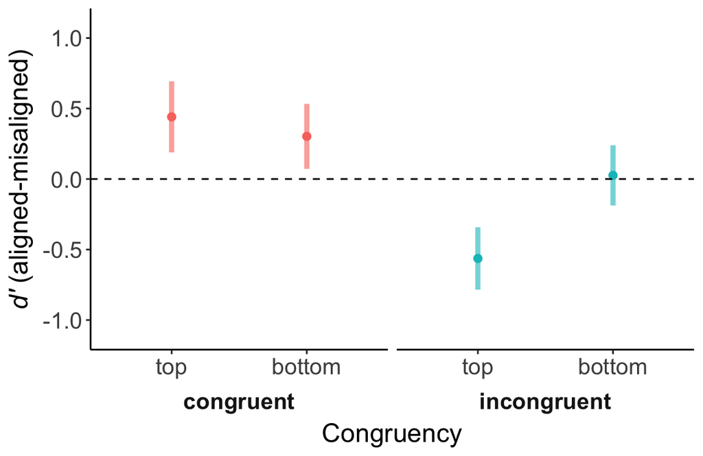

```r
plot_E1_cffi_d <- summary(emm_E1_d_fi[1:4], infer=TRUE) %>%
  as_tibble() %>%
  ggplot(aes(y = estimate, x = Cue, color = Congruency)) +
  geom_point(size = 2) +
  geom_errorbar(aes(ymin = asymp.LCL, ymax = asymp.UCL), size=1.5, width=0,
                alpha = .6) +
  geom_hline(yintercept = 0, linetype = "dashed") +
  facet_grid(. ~ Congruency, switch = "both") +
  coord_cartesian(ylim = ylimit_cf_fi_d) +  # set the limit for y axis c(0, 1100)
  labs(x = "Congruency", y = expression(italic("d'")~"(aligned-misaligned)")) +  # set the names for main, x and y axises
  theme_bw() +
  theme(
    text = element_text(size = 10),
    axis.title = element_text(size = 16),
    axis.text = element_text(size = 14), # the size of the texts in plot
    # axis.text.x = element_text(angle = 45, vjust = 0.5),
    legend.title=element_text(size=15),
    legend.text=element_text(size=14),
    legend.position = "none",
    legend.key.width = unit(1.2, "cm"),
    plot.title = element_text(lineheight=.8, face="bold", size = 17),
    panel.border = element_blank(),
    panel.grid.minor = element_blank(),
    panel.grid.major = element_blank(),
    axis.line.x = element_line(colour = 'black', size=0.5, linetype='solid'),
    axis.line.y = element_line(colour = 'black', size=0.5, linetype='solid'),
    # remove the facet background color
    strip.text = element_text(face="bold", size=14, lineheight=5.0),
    strip.background = element_rect(fill="white", colour="white", size=1),
    strip.placement = "outside"
  ) +
  NULL

# ggsave(filename = "E1_fi_d.pdf", plot_E1_cffi_d, width = 7, height = 4.55)
plot_E1_cffi_d
```

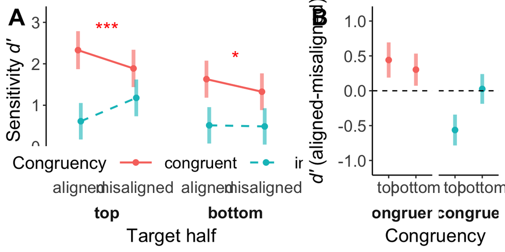

```r
plot_E1_cf_d_ <- plot_E1_cf_d +
  guides(color = guide_legend(nrow = 1, title.position = "left"),
         linetype = guide_legend(nrow = 1, title.position = "left")) +
  theme(legend.position = c(0.6, 0.075),
        legend.box = "horizontal")

plot_E1_d <- ggarrange(plot_E1_cf_d_, plot_E1_cffi_d,
                       labels = c("A", "B"),
                       font.label = (list(size = 20)),
                       widths = c(1.5, 1),
                       nrow = 1)

# ggsave(filename = "E1_d.pdf", plot_E1_d, width = 10, height = 4.5)
plot_E1_d
```

```r
# test <- contrast(emm_E1_resp, method ="pairwise", simple = "Alignment", adjust = "Tukey")
# test[1:8]
```

#### 2.1.2.5 Comparisons between facilitation and interference

```r
summary(contrast(emm_E1_d_fi, method = list("faci-inte"=c(1, 1)), by = "Cue"), infer = TRUE)
```

```
## Cue = top:
##  contrast  estimate    SE  df asymp.LCL asymp.UCL z.ratio p.value
##  faci-inte   -0.122 0.123 Inf    -0.363     0.119 -0.993  0.3206
##
## Cue = bottom:
##  contrast  estimate    SE  df asymp.LCL asymp.UCL z.ratio p.value
##  faci-inte    0.329 0.114 Inf     0.106     0.552  2.886  0.0039
##
## Confidence level used: 0.95
```

```r
# summary(contrast(emm_E1_d, method = list("faci-inte"=c(1, -1, 1, -1 )), by = "Cue"), infer = TRUE)
```

```r
# emmeans(glmm_E1_resp_opt, ~ Alignment + SameDifferent | Cue ) %>%
#   contrast(interaction = "pairwise")
```

## 2.2 Response times

```r
df_lmm_E1_rt <- df_lmm_E1 %>%
  filter(isCorrect == 1)

# save(df_lmm_E1_rt, file = file.path("data", "df_lmm_E1_rt.RData"))
```

### 2.2.1 Fitting the generalized mixed models

```r
# file_E1_rt_max <- file.path(folder_lmm, "E1_rt_lmm_max.RData")
#
# # fit the max model
# if (!file.exists(file_E1_rt_max)) {
#   glmm_E1_rt_max <- glmer(
#     log(RT) ~ Cue * Congruency * Alignment +
#       (Cue * Congruency * Alignment | Participant),
#     family = lognormal(),
#     data = df_lmm_rt,
#     control = glmerControl(optimizer = "optimx", # calc.derivs = FALSE,
#                            optCtrl = list(method = "nlminb", starttests = FALSE, kkt = FALSE))
#   )
#
#   save(glmm_E1_rt_max, file = file_E1_rt_max)
# } else {
#   load(file_E1_rt_max)
# }
#
# print(summary(glmm_E1_rt_max), corr = FALSE)
```

#### 2.2.1.1 The zero-correlation-parameter model

```r
file_E1_rt_zcp <- file.path(folder_lmm, "E1_rt_lmm_zcp.RData")

# fit the zcp1 model
if (!file.exists(file_E1_rt_zcp)) {
  glmm_E1_rt_zcp <- lmer(
    log(RT) ~ Cue * Congruency * Alignment +
      (Cue_C + Con_C + Ali_C +
         Cue_Con + Cue_Ali + Con_Ali +
         Cue_Con_Ali || Participant),
    data = df_lmm_E1_rt,
    control = lmerControl(optimizer = "optimx", # calc.derivs = FALSE,
                          optCtrl = list(method = "nlminb", starttests = FALSE, kkt = FALSE))
  )
  # save(glmm_E1_rt_zcp, file = file_E1_rt_zcp)
} else {
  load(file_E1_rt_zcp)
}

print(summary(glmm_E1_rt_zcp), corr = FALSE)
```

```
## Linear mixed model fit by REML. t-tests use Satterthwaite's method ['lmerModLmerTest']
## Formula: log(RT) ~ Cue * Congruency * Alignment + (Cue_C + Con_C + Ali_C +      Cue_Con + Cue_Ali + Con_Ali + Cue_Con_Ali || Participant)
##    Data: df_lmm_E1_rt
## Control: lmerControl(optimizer = "optimx", optCtrl = list(method = "nlminb",      starttests = FALSE, kkt = FALSE))
##
## REML criterion at convergence: 13677.3
##
## Scaled residuals:
##     Min      1Q  Median      3Q     Max
## -3.6186 -0.5735 -0.1346  0.4295  7.6689
##
## Random effects:
##  Groups        Name        Variance  Std.Dev.
##  Participant   (Intercept) 0.0725762 0.26940
##  Participant.1 Cue_C       0.0226908 0.15063
##  Participant.2 Con_C       0.0010608 0.03257
##  Participant.3 Ali_C       0.0011955 0.03458
##  Participant.4 Cue_Con     0.0007338 0.02709
##  Participant.5 Cue_Ali     0.0046874 0.06846
##  Participant.6 Con_Ali     0.0000000 0.00000
##  Participant.7 Cue_Con_Ali 0.0231449 0.15213
##  Residual                  0.1478702 0.38454
## Number of obs: 14339, groups:  Participant, 32
##
## Fixed effects:
##                                                       Estimate Std. Error         df t value Pr(>|t|)
## (Intercept)                                           6.689329   0.050535  38.630155 132.371  < 2e-16 ***
## Cuebottom                                             0.072469   0.030700  46.934968   2.361 0.022456 *
## Congruencyincongruent                                 0.060203   0.015862 110.775801   3.796 0.000241 ***
## Alignmentmisaligned                                   0.035569   0.016166  89.228593   2.200 0.030371 *
## Cuebottom:Congruencyincongruent                       0.001602   0.023408  52.241192   0.068 0.945697
## Cuebottom:Alignmentmisaligned                         0.015209   0.025040  47.196342   0.607 0.546497
## Congruencyincongruent:Alignmentmisaligned            -0.039663   0.022484  56.766074  -1.764 0.083102 .
## Cuebottom:Congruencyincongruent:Alignmentmisaligned  -0.007022   0.037462  27.620253  -0.187 0.852689
## ---
## Signif. codes:  0 '***' 0.001 '**' 0.01 '*' 0.05 '.' 0.1 ' ' 1
## optimizer (optimx) convergence code: 1
## boundary (singular) fit: see ?isSingular
```

#### 2.2.1.2 The reduced model

```r
summary(rePCA(glmm_E1_rt_zcp))
```

```
## $Participant
## Importance of components:
##                          [,1]   [,2]   [,3]    [,4]    [,5]    [,6]    [,7] [,8]
## Standard deviation     0.7006 0.3956 0.3917 0.17804 0.08992 0.08470 0.07045    0
## Proportion of Variance 0.5756 0.1836 0.1800 0.03718 0.00948 0.00841 0.00582    0
## Cumulative Proportion  0.5756 0.7591 0.9391 0.97629 0.98577 0.99418 1.00000    1
```

`Con_Ali` was removed from extended model (`glmm_E1_rt_zcp`) due to that the variance it explained was smaller than 0.1%, making `glmm_E1_rt_rdc`.

```r
file_E1_rt_rdc <- file.path(folder_lmm, "E1_rt_lmm_rdc.RData")

# fit the rdc1 model
if (!file.exists(file_E1_rt_rdc)) {
  glmm_E1_rt_rdc <- lmer(
    log(RT) ~ Cue * Congruency * Alignment +
      (Cue_C + Con_C + Ali_C +
         Cue_Con + Cue_Ali + # Con_Ali +
         Cue_Con_Ali || Participant),
    data = df_lmm_E1_rt,
    control = lmerControl(optimizer = "optimx", # calc.derivs = FALSE,
                          optCtrl = list(method = "nlminb", starttests = FALSE, kkt = FALSE))
  )
  # save(glmm_E1_rt_rdc, file = file_E1_rt_rdc)
} else {
  load(file_E1_rt_rdc)
}

print(summary(glmm_E1_rt_rdc), corr = FALSE)
```

```
## Linear mixed model fit by REML. t-tests use Satterthwaite's method ['lmerModLmerTest']
## Formula: log(RT) ~ Cue * Congruency * Alignment + (Cue_C + Con_C + Ali_C +      Cue_Con + Cue_Ali + Cue_Con_Ali || Participant)
##    Data: df_lmm_E1_rt
## Control: lmerControl(optimizer = "optimx", optCtrl = list(method = "nlminb",      starttests = FALSE, kkt = FALSE))
##
## REML criterion at convergence: 13677.3
##
## Scaled residuals:
##     Min      1Q  Median      3Q     Max
## -3.6186 -0.5735 -0.1346  0.4295  7.6689
##
## Random effects:
##  Groups        Name        Variance  Std.Dev.
##  Participant   (Intercept) 0.0725764 0.26940
##  Participant.1 Cue_C       0.0226910 0.15064
##  Participant.2 Con_C       0.0010608 0.03257
##  Participant.3 Ali_C       0.0011956 0.03458
##  Participant.4 Cue_Con     0.0007337 0.02709
##  Participant.5 Cue_Ali     0.0046876 0.06847
##  Participant.6 Cue_Con_Ali 0.0231478 0.15214
##  Residual                  0.1478701 0.38454
## Number of obs: 14339, groups:  Participant, 32
##
## Fixed effects:
##                                                       Estimate Std. Error         df t value Pr(>|t|)
## (Intercept)                                           6.689329   0.050535  38.630041 132.371  < 2e-16 ***
## Cuebottom                                             0.072469   0.030701  46.934893   2.361 0.022456 *
## Congruencyincongruent                                 0.060203   0.015862 110.770723   3.796 0.000241 ***
## Alignmentmisaligned                                   0.035569   0.016166  89.225948   2.200 0.030373 *
## Cuebottom:Congruencyincongruent                       0.001602   0.023409  52.237565   0.068 0.945701
## Cuebottom:Alignmentmisaligned                         0.015209   0.025040  47.194938   0.607 0.546510
## Congruencyincongruent:Alignmentmisaligned            -0.039663   0.022485  56.760997  -1.764 0.083108 .
## Cuebottom:Congruencyincongruent:Alignmentmisaligned  -0.007021   0.037463  27.618818  -0.187 0.852700
## ---
## Signif. codes:  0 '***' 0.001 '**' 0.01 '*' 0.05 '.' 0.1 ' ' 1
```

#### 2.2.1.3 The extended model

```r
file_E1_rt_etd <- file.path(folder_lmm, "E1_rt_lmm_etd.RData")

# fit the etd1 model
if (!file.exists(file_E1_rt_etd)) {
  glmm_E1_rt_etd <- lmer(
    log(RT) ~ Cue * Congruency * Alignment +
      (Cue_C + Con_C + Ali_C +
         Cue_Con + Cue_Ali + # Con_Ali +
         Cue_Con_Ali | Participant),
    data = df_lmm_E1_rt,
    control = lmerControl(optimizer = "optimx", # calc.derivs = FALSE,
                          optCtrl = list(method = "nlminb", starttests = FALSE, kkt = FALSE))
  )
  # save(glmm_E1_rt_etd, file = file_E1_rt_etd)
} else {
  load(file_E1_rt_etd)
}

print(summary(glmm_E1_rt_etd), corr = FALSE)
```

```
## Linear mixed model fit by REML. t-tests use Satterthwaite's method ['lmerModLmerTest']
## Formula: log(RT) ~ Cue * Congruency * Alignment + (Cue_C + Con_C + Ali_C +      Cue_Con + Cue_Ali + Cue_Con_Ali | Participant)
##    Data: df_lmm_E1_rt
## Control: lmerControl(optimizer = "optimx", optCtrl = list(method = "nlminb",      starttests = FALSE, kkt = FALSE))
##
## REML criterion at convergence: 13639.4
##
## Scaled residuals:
##     Min      1Q  Median      3Q     Max
## -3.7341 -0.5741 -0.1341  0.4281  7.5985
##
## Random effects:
##  Groups      Name        Variance Std.Dev. Corr
##  Participant (Intercept) 0.072195 0.26869
##              Cue_C       0.022630 0.15043  -0.02
##              Con_C       0.001094 0.03308  -0.40  0.19
##              Ali_C       0.001456 0.03816  -0.30 -0.23  0.54
##              Cue_Con     0.002246 0.04739   0.18  0.30 -0.10 -0.89
##              Cue_Ali     0.005632 0.07505  -0.05 -0.01 -0.16  0.67 -0.91
##              Cue_Con_Ali 0.027429 0.16562  -0.46 -0.25 -0.27  0.52 -0.79  0.82
##  Residual                0.147687 0.38430
## Number of obs: 14339, groups:  Participant, 32
##
## Fixed effects:
##                                                       Estimate Std. Error         df t value Pr(>|t|)
## (Intercept)                                          6.6890097  0.0539790 31.1138223 123.919  < 2e-16 ***
## Cuebottom                                            0.0724021  0.0269948 31.6152685   2.682  0.01153 *
## Congruencyincongruent                                0.0604124  0.0173550 44.2973201   3.481  0.00113 **
## Alignmentmisaligned                                  0.0361463  0.0139979 47.8768479   2.582  0.01293 *
## Cuebottom:Congruencyincongruent                      0.0008654  0.0286328 30.2534505   0.030  0.97609
## Cuebottom:Alignmentmisaligned                        0.0154113  0.0192267 39.4831241   0.802  0.42761
## Congruencyincongruent:Alignmentmisaligned           -0.0397233  0.0231668 56.6025894  -1.715  0.09188 .
## Cuebottom:Congruencyincongruent:Alignmentmisaligned -0.0058548  0.0391678 29.1435306  -0.149  0.88220
## ---
## Signif. codes:  0 '***' 0.001 '**' 0.01 '*' 0.05 '.' 0.1 ' ' 1
## optimizer (optimx) convergence code: 1
## boundary (singular) fit: see ?isSingular
```

```r
summary(rePCA(glmm_E1_rt_etd))
```

```
## $Participant
## Importance of components:
##                          [,1]   [,2]   [,3]    [,4]    [,5]     [,6]      [,7]
## Standard deviation     0.7406 0.4537 0.3537 0.13699 0.01013 0.001418 7.519e-19
## Proportion of Variance 0.6106 0.2291 0.1393 0.02089 0.00011 0.000000 0.000e+00
## Cumulative Proportion  0.6106 0.8397 0.9790 0.99988 1.00000 1.000000 1.000e+00
```

`Con_C`, `Ali_C`, and `Cue_Con` were removed from extended model.

```r
file_E1_rt_etd1 <- file.path(folder_lmm, "E1_rt_lmm_etd1.RData")

# fit the etd1 model
if (!file.exists(file_E1_rt_etd1)) {
  glmm_E1_rt_etd1 <- lmer(
    log(RT) ~ Cue * Congruency * Alignment +
      (Cue_C + # Con_C + Ali_C +
         Cue_Ali + # Con_Ali + Cue_Con +
         Cue_Con_Ali | Participant),
    data = df_lmm_E1_rt,
    control = lmerControl(optimizer = "optimx", # calc.derivs = FALSE,
                          optCtrl = list(method = "nlminb", starttests = FALSE, kkt = FALSE))
  )
  # save(glmm_E1_rt_etd1, file = file_E1_rt_etd1)
} else {
  load(file_E1_rt_etd1)
}

print(summary(glmm_E1_rt_etd1), corr = FALSE)
```

```
## Linear mixed model fit by REML. t-tests use Satterthwaite's method ['lmerModLmerTest']
## Formula: log(RT) ~ Cue * Congruency * Alignment + (Cue_C + Cue_Ali + Cue_Con_Ali |      Participant)
##    Data: df_lmm_E1_rt
## Control: lmerControl(optimizer = "optimx", optCtrl = list(method = "nlminb",      starttests = FALSE, kkt = FALSE))
##
## REML criterion at convergence: 13678.9
##
## Scaled residuals:
##     Min      1Q  Median      3Q     Max
## -3.7618 -0.5749 -0.1328  0.4291  7.6980
##
## Random effects:
##  Groups      Name        Variance Std.Dev. Corr
##  Participant (Intercept) 0.072713 0.26965
##              Cue_C       0.022643 0.15048  -0.02
##              Cue_Ali     0.004764 0.06902  -0.01  0.00
##              Cue_Con_Ali 0.026729 0.16349  -0.43 -0.26  0.84
##  Residual                0.148441 0.38528
## Number of obs: 14339, groups:  Participant, 32
##
## Fixed effects:
##                                                       Estimate Std. Error         df t value Pr(>|t|)
## (Intercept)                                           6.689159   0.051646  31.691272 129.520  < 2e-16 ***
## Cuebottom                                             0.071427   0.027748  33.934439   2.574  0.01459 *
## Congruencyincongruent                                 0.060875   0.014804 146.126193   4.112 6.52e-05 ***
## Alignmentmisaligned                                   0.035516   0.012534  87.573213   2.834  0.00571 **
## Cuebottom:Congruencyincongruent                       0.002798   0.023482  58.492199   0.119  0.90557
## Cuebottom:Alignmentmisaligned                         0.016498   0.018961  28.771290   0.870  0.39145
## Congruencyincongruent:Alignmentmisaligned            -0.041767   0.023105  54.360420  -1.808  0.07618 .
## Cuebottom:Congruencyincongruent:Alignmentmisaligned  -0.007626   0.038908  27.563343  -0.196  0.84604
## ---
## Signif. codes:  0 '***' 0.001 '**' 0.01 '*' 0.05 '.' 0.1 ' ' 1
```

#### 2.2.1.4 The optimal model

```r
# compare the extended and reduced model
anova(glmm_E1_rt_etd1, glmm_E1_rt_rdc, refit = FALSE)
```

```
## Data: df_lmm_E1_rt
## Models:
## glmm_E1_rt_rdc: log(RT) ~ Cue * Congruency * Alignment + (Cue_C + Con_C + Ali_C +
## glmm_E1_rt_rdc:     Cue_Con + Cue_Ali + Cue_Con_Ali || Participant)
## glmm_E1_rt_etd1: log(RT) ~ Cue * Congruency * Alignment + (Cue_C + Cue_Ali + Cue_Con_Ali |
## glmm_E1_rt_etd1:     Participant)
##                 npar   AIC   BIC  logLik deviance Chisq Df Pr(>Chisq)
## glmm_E1_rt_rdc    16 13709 13830 -6838.6    13677
## glmm_E1_rt_etd1   19 13717 13861 -6839.5    13679     0  3          1
```

According to BIC, the reduced model (`glmm_E1_rt_rdc`) explained the data better than the extended model (`glmm_E1_rt_etd1`) and, therefore, the reduced model is used as the optimal model.

```r
glmm_E1_rt_opt <- glmm_E1_rt_rdc

print(summary(glmm_E1_rt_opt), corr = FALSE)
```

```
## Linear mixed model fit by REML. t-tests use Satterthwaite's method ['lmerModLmerTest']
## Formula: log(RT) ~ Cue * Congruency * Alignment + (Cue_C + Con_C + Ali_C +      Cue_Con + Cue_Ali + Cue_Con_Ali || Participant)
##    Data: df_lmm_E1_rt
## Control: lmerControl(optimizer = "optimx", optCtrl = list(method = "nlminb",      starttests = FALSE, kkt = FALSE))
##
## REML criterion at convergence: 13677.3
##
## Scaled residuals:
##     Min      1Q  Median      3Q     Max
## -3.6186 -0.5735 -0.1346  0.4295  7.6689
##
## Random effects:
##  Groups        Name        Variance  Std.Dev.
##  Participant   (Intercept) 0.0725764 0.26940
##  Participant.1 Cue_C       0.0226910 0.15064
##  Participant.2 Con_C       0.0010608 0.03257
##  Participant.3 Ali_C       0.0011956 0.03458
##  Participant.4 Cue_Con     0.0007337 0.02709
##  Participant.5 Cue_Ali     0.0046876 0.06847
##  Participant.6 Cue_Con_Ali 0.0231478 0.15214
##  Residual                  0.1478701 0.38454
## Number of obs: 14339, groups:  Participant, 32
##
## Fixed effects:
##                                                       Estimate Std. Error         df t value Pr(>|t|)
## (Intercept)                                           6.689329   0.050535  38.630041 132.371  < 2e-16 ***
## Cuebottom                                             0.072469   0.030701  46.934893   2.361 0.022456 *
## Congruencyincongruent                                 0.060203   0.015862 110.770723   3.796 0.000241 ***
## Alignmentmisaligned                                   0.035569   0.016166  89.225948   2.200 0.030373 *
## Cuebottom:Congruencyincongruent                       0.001602   0.023409  52.237565   0.068 0.945701
## Cuebottom:Alignmentmisaligned                         0.015209   0.025040  47.194938   0.607 0.546510
## Congruencyincongruent:Alignmentmisaligned            -0.039663   0.022485  56.760997  -1.764 0.083108 .
## Cuebottom:Congruencyincongruent:Alignmentmisaligned  -0.007021   0.037463  27.618818  -0.187 0.852700
## ---
## Signif. codes:  0 '***' 0.001 '**' 0.01 '*' 0.05 '.' 0.1 ' ' 1
```

### 2.2.2 Estimated marginal means

#### 2.2.2.1 Estimated marginal means for RT

```r
file_E1_rt_emm <- file.path(folder_lmm, "E1_rt_emm.RData")
if (!file.exists(file_E1_rt_emm)) {
  emm_E1_rt <- emmeans(glmm_E1_rt_opt, ~ Cue + Congruency + Alignment)
} else {
  load(file_E1_rt_emm)
}

# emmip(regrid(emm_E1_rt), Congruency ~ Alignment | Cue, CIs = TRUE)

summary(emm_E1_rt, type = "response") # equivalent to regrid(emm_rt)
```

```
##  Cue    Congruency  Alignment  response   SE  df asymp.LCL asymp.UCL
##  top    congruent   aligned         804 40.6 Inf       728       887
##  bottom congruent   aligned         864 43.7 Inf       783       954
##  top    incongruent aligned         854 43.4 Inf       773       943
##  bottom incongruent aligned         919 46.7 Inf       832      1016
##  top    congruent   misaligned      833 42.1 Inf       754       920
##  bottom congruent   misaligned      909 46.1 Inf       823      1004
##  top    incongruent misaligned      850 43.1 Inf       770       939
##  bottom incongruent misaligned      923 46.9 Inf       835      1020
##
## Degrees-of-freedom method: asymptotic
## Confidence level used: 0.95
## Intervals are back-transformed from the log scale
```

[figure not shown]

```r
plot_E1_cf_rt <- summary(emm_E1_rt, type = "response") %>%
  as_tibble() %>%
  ggplot(aes(y = response, x = Alignment, color = Congruency, group = Congruency)) +
  geom_point(position = position_dodge(width = 0.1), size = 2) +
  geom_line(aes(linetype = Congruency), position = position_dodge(width = 0.1),
            size = 0.8) +
  scale_linetype_manual(values=c("solid", "dashed"))+
  geom_errorbar(aes(ymin = asymp.LCL, ymax = asymp.UCL), size=1.5, width=0,
                alpha = .6, position = position_dodge(width = 0.1),
                show.legend = F) +
  facet_grid(. ~Cue, switch = "both") +
  coord_cartesian(ylim = ylimit_cf_rt) +  # set the limit for y axis c(0, 1100)
  labs(x = "Target half", y = "Correct response times (ms)", fill = "Congruency") +  # set the names for main, x and y axises
  geom_text(label = c("", "", "++", "+", "", "", "", ""), color = "blue", size = 6, nudge_y = 50, nudge_x = 0.5) + # add starts to the significant columns
  theme_bw() +
  theme(
    text = element_text(size = 10),
    axis.title = element_text(size = 16),
    axis.text = element_text(size = 14), # the size of the texts in plot
    # axis.text.x = element_text(angle = 45, vjust = 0.5),
    legend.title=element_text(size=15),
    legend.text=element_text(size=14),
    legend.position = "right",
    legend.key.width = unit(1.2, "cm"),
    plot.title = element_text(lineheight=.8, face="bold", size = 17),
    panel.border = element_blank(),
    panel.grid.minor = element_blank(),
    panel.grid.major = element_blank(),
    axis.line.x = element_line(colour = 'black', size=0.5, linetype='solid'),
    axis.line.y = element_line(colour = 'black', size=0.5, linetype='solid'),
    # remove the facet background color
    strip.text = element_text(face="bold", size=14, lineheight=5.0),
    strip.background = element_rect(fill="white", colour="white", size=1),
    strip.placement = "outside"
  )

# ggsave(filename = "E1_cf_rt.pdf", plot_E1_cf_rt, width = 8, height = 4.8)

plot_E1_cf_rt
```

#### 2.2.2.2 Composite effects

Composite face effects for top and bottom parts:

```r
emm_rt_cf <- contrast(regrid(emm_E1_rt), interaction = "pairwise", by = "Cue", infer = TRUE)
emm_rt_cf[1:2]
```

```
##  Congruency_pairwise     Alignment_pairwise   Cue    estimate   SE  df asymp.LCL asymp.UCL z.ratio p.value
##  congruent - incongruent aligned - misaligned top       -32.6 18.9 Inf     -69.6     4.424 -1.726  0.0844
##  congruent - incongruent aligned - misaligned bottom    -41.2 21.1 Inf     -82.6     0.119 -1.954  0.0507
##
## Confidence level used: 0.95
```

#### 2.2.2.3 Facilitation and interference

```r
emm_E1_rt_fi <- contrast(regrid(emm_E1_rt), "pairwise", by = c("Cue", "Congruency"), infer=TRUE, adjust = "Tukey")

# emmip(emm_E1_rt_fi[1:4], ~ Cue | Congruency, CIs = TRUE, adjust = "Tukey")
emm_E1_rt_fi[1:4]
```

```
##  contrast             Cue    Congruency  estimate   SE  df asymp.LCL asymp.UCL z.ratio p.value
##  aligned - misaligned top    congruent     -29.10 13.3 Inf     -63.3      5.10 -2.186  0.1270
##  aligned - misaligned bottom congruent     -45.02 14.9 Inf     -83.3     -6.69 -3.017  0.0136
##  aligned - misaligned top    incongruent     3.49 14.8 Inf     -34.6     41.53  0.236  0.9954
##  aligned - misaligned bottom incongruent    -3.77 16.5 Inf     -46.0     38.50 -0.229  0.9958
##
## Confidence level used: 0.95
## Conf-level adjustment: tukey method for comparing a family of 4 estimates
## P value adjustment: tukey method for comparing a family of 4 estimates
```

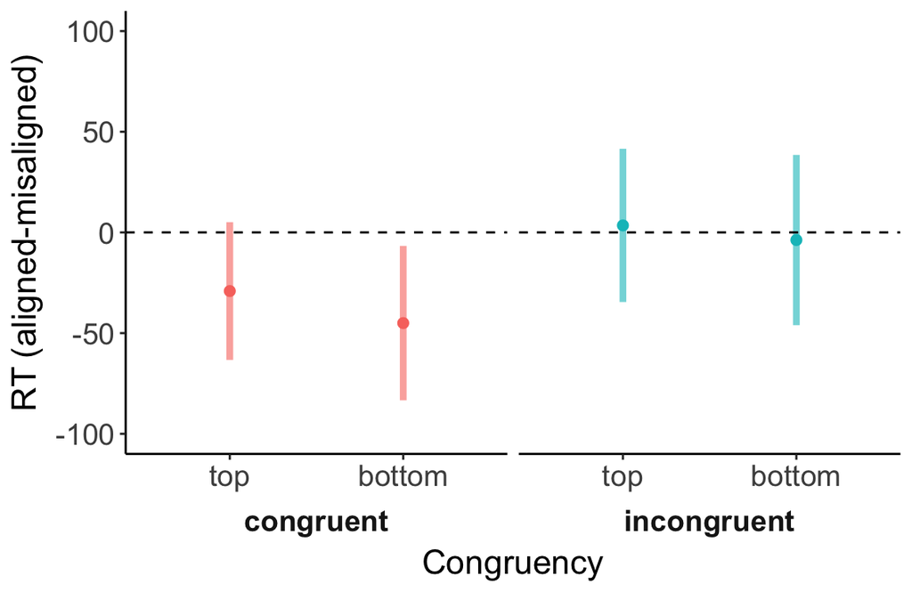

```r
plot_E1_cffi_rt <- emm_E1_rt_fi[1:4] %>%
  as_tibble() %>%
  ggplot(aes(y = estimate, x = Cue, color = Congruency)) +
  geom_point(size = 2) +
  geom_errorbar(aes(ymin = asymp.LCL, ymax = asymp.UCL), size=1.5, width=0,
                alpha = .6) +
  geom_hline(yintercept = 0, linetype = "dashed") +
  facet_grid(. ~ Congruency, switch = "both") +
  coord_cartesian(ylim = ylimit_cf_fi_rt) +  # set the limit for y axis c(0, 1100)
  labs(x = "Congruency", y = expression(RT~"(aligned-misaligned)")) +  # set the names for main, x and y axises
  theme_bw() +
  theme(
    text = element_text(size = 10),
    axis.title = element_text(size = 16),
    axis.text = element_text(size = 14), # the size of the texts in plot
    # axis.text.x = element_text(angle = 45, vjust = 0.5),
    legend.title=element_text(size=15),
    legend.text=element_text(size=14),
    legend.position = "none",
    legend.key.width = unit(1.2, "cm"),
    plot.title = element_text(lineheight=.8, face="bold", size = 17),
    panel.border = element_blank(),
    panel.grid.minor = element_blank(),
    panel.grid.major = element_blank(),
    axis.line.x = element_line(colour = 'black', size=0.5, linetype='solid'),
    axis.line.y = element_line(colour = 'black', size=0.5, linetype='solid'),
    # remove the facet background color
    strip.text = element_text(face="bold", size=14, lineheight=5.0),
    strip.background = element_rect(fill="white", colour="white", size=1),
    strip.placement = "outside"
  ) +
  NULL

# ggsave(filename = "E1_fi_rt.pdf", plot_E1_cffi_rt, width = 7, height = 4.55)
plot_E1_cffi_rt
```

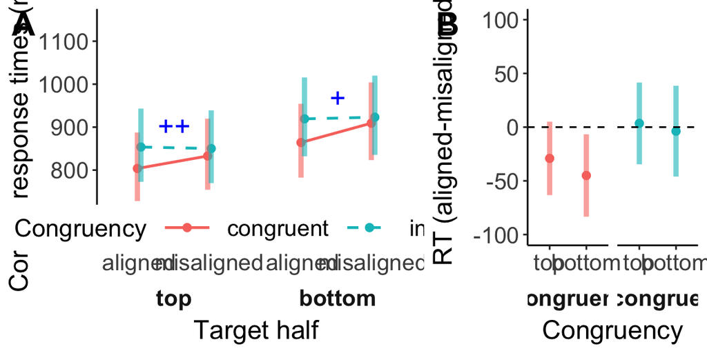

```r
plot_E1_cf_rt_ <- plot_E1_cf_rt +
  guides(color = guide_legend(nrow = 1, title.position = "left"),
         linetype = guide_legend(nrow = 1, title.position = "left")) +
  theme(legend.position = c(0.55, 0.075),
        legend.box = "horizontal")

plot_E1_rt <- ggarrange(plot_E1_cf_rt_, plot_E1_cffi_rt,
                       labels = c("A", "B"),
                       font.label = (list(size = 20)),
                       widths = c(1.5, 1),
                       nrow = 1)

# ggsave(filename = "E1_rt.pdf", plot_E1_rt, width = 10, height = 4.5)
plot_E1_rt
```

#### 2.2.2.4 Comparisons between facilitation and interference

```r
summary(contrast(emm_E1_rt_fi, method = list("faci-inte"=c(1, 1)), by = "Cue"), infer = TRUE)
```

```
## Cue = top:
##  contrast  estimate   SE  df asymp.LCL asymp.UCL z.ratio p.value
##  faci-inte    -25.6 20.9 Inf     -66.6     15.33 -1.226  0.2201
##
## Cue = bottom:
##  contrast  estimate   SE  df asymp.LCL asymp.UCL z.ratio p.value
##  faci-inte    -48.8 23.3 Inf     -94.4     -3.19 -2.097  0.0360
##
## Confidence level used: 0.95
```

```r
emmeans(regrid(emm_E1_rt), ~ Alignment | Cue) %>%
  # regrid() %>%
  contrast(interaction = "pairwise") %>%
  summary(infer = TRUE)
```

```
## Cue = top:
##  Alignment_pairwise   estimate   SE  df asymp.LCL asymp.UCL z.ratio p.value
##  aligned - misaligned    -12.8 10.4 Inf     -33.3      7.66 -1.226  0.2201
##
## Cue = bottom:
##  Alignment_pairwise   estimate   SE  df asymp.LCL asymp.UCL z.ratio p.value
##  aligned - misaligned    -24.4 11.6 Inf     -47.2     -1.59 -2.097  0.0360
##
## Results are averaged over the levels of: Congruency
## Confidence level used: 0.95
```

# 3 Experiment 2

```r
df_lmm_E2 <- df_lmm %>%
  filter(Experiment != "109_cue") %>%
  droplevels()

contrasts(df_lmm_E2$Probability) <- MASS::contr.sdif(2)

df_lmm_E2 <- df_lmm_E2 %>%
  mutate(Pro_C = if_else(Probability == 0.25, -0.5, 0.5),
         Cue_Pro = Cue_C * Pro_C,
         Con_Pro = Con_C * Pro_C,
         Ali_Pro = Ali_C * Pro_C,
         Sam_Pro = Sam_C * Pro_C,
         Cue_Con_Pro = Cue_Con * Pro_C,
         Cue_Ali_Pro = Cue_Ali * Pro_C,
         Cue_Sam_Pro = Cue_Sam * Pro_C,
         Con_Ali_Pro = Con_Ali * Pro_C,
         Con_Sam_Pro = Con_Sam * Pro_C,
         Ali_Sam_Pro = Ali_Sam * Pro_C,
         Cue_Con_Ali_Pro = Cue_Con_Ali * Pro_C,
         Cue_Con_Sam_Pro = Cue_Con_Sam * Pro_C,
         Cue_Ali_Sam_Pro = Cue_Ali_Sam * Pro_C,
         Con_Ali_Sam_Pro = Con_Ali_Sam * Pro_C,
         Cue_Con_Ali_Sam_Pro = Cue_Con_Ali_Sam * Pro_C
  )

# save(df_lmm_E2, file = file.path("data", "df_lmm_E2.RData"))
```

## 3.1 Response (d’)

### 3.1.1 Fitting the generalized mixed models

#### 3.1.1.1 The maximal model

```r
# file_E2_resp_max <- file.path(folder_lmm, "E2_Resp_lmm_max.RData")
#
# # fit the max model
# if (!file.exists(file_E2_resp_max)) {
#   glmm_E2_resp_max <- glmer(
#     Resp ~ Cue * Congruency * Alignment * SameDifferent * Probability +
#       (Cue * Congruency * Alignment * SameDifferent * Probability | Participant), # Con_Ali_Sam
#     family = binomial(link = "probit"),
#     data = df_lmm_E2,
#     control = glmerControl(optimizer = "optimx", # calc.derivs = FALSE,
#                            optCtrl = list(method = "nlminb", starttests = FALSE, kkt = FALSE))
#   )
#
#   save(glmm_E2_resp_max, file = file_E2_resp_max)
# } else {
#   load(file_E2_resp_max)
# }
#
# print(summary(glmm_E2_resp_max), corr = FALSE)
```

#### 3.1.1.2 The zero-correlation-parameter model

```r
file_E2_resp_zcp <- file.path(folder_lmm, "E2_Resp_lmm_zcp.RData")

# fit the zcp model
if (!file.exists(file_E2_resp_zcp)) {
  glmm_E2_resp_zcp <- glmer(
    Resp ~ Cue * Congruency * Alignment * SameDifferent * Probability +
      (Cue_C + Con_C + Ali_C + Sam_C +
         Cue_Con + Cue_Ali + Cue_Sam + Con_Ali + Con_Sam + Ali_Sam +
         Cue_Con_Ali + Cue_Con_Sam + Cue_Ali_Sam + Con_Ali_Sam +
         Cue_Con_Ali_Sam +
         Pro_C +
         Cue_Pro + Con_Pro + Ali_Pro + Sam_Pro +
         Cue_Con_Pro + Cue_Ali_Pro + Cue_Sam_Pro + Con_Ali_Pro + Con_Sam_Pro + Ali_Sam_Pro +
         Cue_Con_Ali_Pro + Cue_Con_Sam_Pro + Cue_Ali_Sam_Pro + Con_Ali_Sam_Pro +
         Cue_Con_Ali_Sam_Pro || Participant),
    family = binomial(link = "probit"),
    data = df_lmm_E2,
    control = glmerControl(optimizer = "optimx", # calc.derivs = FALSE,
                           optCtrl = list(method = "nlminb", starttests = FALSE, kkt = FALSE))
  )

  # save(glmm_E2_resp_zcp, file = file_E2_resp_zcp)
} else {
  load(file_E2_resp_zcp)
}

print(summary(glmm_E2_resp_zcp), corr = FALSE)
```

```
## Generalized linear mixed model fit by maximum likelihood (Laplace Approximation) ['glmerMod']
##  Family: binomial  ( probit )
## Formula: Resp ~ Cue * Congruency * Alignment * SameDifferent * Probability +      (Cue_C + Con_C + Ali_C + Sam_C + Cue_Con + Cue_Ali + Cue_Sam +          Con_Ali + Con_Sam + Ali_Sam + Cue_Con_Ali + Cue_Con_Sam +          Cue_Ali_Sam + Con_Ali_Sam + Cue_Con_Ali_Sam + Pro_C +          Cue_Pro + Con…
##    Data: df_lmm_E2
## Control: glmerControl(optimizer = "optimx", optCtrl = list(method = "nlminb",      starttests = FALSE, kkt = FALSE))
##
##      AIC      BIC   logLik deviance df.resid
##  39518.4  40070.1 -19695.2  39390.4    40896
##
## Scaled residuals:
##      Min       1Q   Median       3Q      Max
## -10.0859  -0.5478   0.1864   0.5144   6.1841
##
## Random effects:
##  Groups         Name                Variance  Std.Dev.
##  Participant    (Intercept)         7.235e-02 2.690e-01
##  Participant.1  Cue_C               1.301e-01 3.606e-01
##  Participant.2  Con_C               5.310e-03 7.287e-02
##  Participant.3  Ali_C               3.194e-02 1.787e-01
##  Participant.4  Sam_C               2.027e-01 4.502e-01
##  Participant.5  Cue_Con             8.565e-04 2.927e-02
##  Participant.6  Cue_Ali             3.749e-02 1.936e-01
##  Participant.7  Cue_Sam             5.871e-01 7.662e-01
##  Participant.8  Con_Ali             0.000e+00 0.000e+00
##  Participant.9  Con_Sam             3.870e-01 6.221e-01
##  Participant.10 Ali_Sam             0.000e+00 0.000e+00
##  Participant.11 Cue_Con_Ali         0.000e+00 0.000e+00
##  Participant.12 Cue_Con_Sam         1.168e+00 1.081e+00
##  Participant.13 Cue_Ali_Sam         3.098e-09 5.566e-05
##  Participant.14 Con_Ali_Sam         1.058e-01 3.253e-01
##  Participant.15 Cue_Con_Ali_Sam     7.473e-02 2.734e-01
##  Participant.16 Pro_C               5.746e-02 2.397e-01
##  Participant.17 Cue_Pro             4.125e-01 6.422e-01
##  Participant.18 Con_Pro             1.446e-03 3.803e-02
##  Participant.19 Ali_Pro             2.664e-03 5.161e-02
##  Participant.20 Sam_Pro             4.237e-02 2.058e-01
##  Participant.21 Cue_Con_Pro         1.238e-10 1.113e-05
##  Participant.22 Cue_Ali_Pro         5.495e-02 2.344e-01
##  Participant.23 Cue_Sam_Pro         1.568e+00 1.252e+00
##  Participant.24 Con_Ali_Pro         4.282e-08 2.069e-04
```

[output cut: 32 more lines]

```
## Cuebottom:Alignmentmisaligned:Probability2-1                                               0.040635   0.158902   0.256 0.798162
## Congruencyincongruent:Alignmentmisaligned:Probability2-1                                   0.118865   0.138386   0.859 0.390376
## Cuebottom:SameDifferentdifferent:Probability2-1                                            1.359361   0.309491   4.392 1.12e-05 ***
## Congruencyincongruent:SameDifferentdifferent:Probability2-1                               -0.262296   0.208444  -1.258 0.208266
## Alignmentmisaligned:SameDifferentdifferent:Probability2-1                                  0.171116   0.144253   1.186 0.235533
## Cuebottom:Congruencyincongruent:Alignmentmisaligned:SameDifferentdifferent                 0.600009   0.141603   4.237 2.26e-05 ***
## Cuebottom:Congruencyincongruent:Alignmentmisaligned:Probability2-1                        -0.146778   0.199783  -0.735 0.462528
## Cuebottom:Congruencyincongruent:SameDifferentdifferent:Probability2-1                      0.778487   0.347609   2.240 0.025120 *
## Cuebottom:Alignmentmisaligned:SameDifferentdifferent:Probability2-1                       -0.135719   0.209018  -0.649 0.516132
## Congruencyincongruent:Alignmentmisaligned:SameDifferentdifferent:Probability2-1           -0.291421   0.192026  -1.518 0.129112
## Cuebottom:Congruencyincongruent:Alignmentmisaligned:SameDifferentdifferent:Probability2-1  0.441127   0.274619   1.606 0.108203
## ---
## Signif. codes:  0 '***' 0.001 '**' 0.01 '*' 0.05 '.' 0.1 ' ' 1
## optimizer (optimx) convergence code: 1
## boundary (singular) fit: see ?isSingular
```

#### 3.1.1.3 The reduced model

```r
summary(rePCA(glmm_E2_resp_zcp))
```

```
## $Participant
## Importance of components:
##                         [,1]   [,2]   [,3]    [,4]    [,5]    [,6]    [,7]    [,8]    [,9]  [,10]  [,11]   [,12]   [,13]   [,14]   [,15]   [,16]   [,17]   [,18]   [,19]   [,20]   [,21]   [,22]   [,23]     [,24]     [,25]     [,26]     [,27]    [,28]    [,29]    [,30]    [,31]    [,32]
## Standard deviation     1.582 1.2521 1.0807 0.76621 0.64223 0.62211 0.45022 0.36064 0.35380 0.3253 0.2807 0.27336 0.26953 0.26898 0.23971 0.23442 0.20585 0.19362 0.17872 0.07287 0.05161 0.03803 0.02927 0.0002069 5.566e-05 1.113e-05 1.059e-05 1.58e-16 1.58e-16 1.58e-16 1.58e-16 1.58e-16
## Proportion of Variance 0.324 0.2031 0.1513 0.07604 0.05342 0.05013 0.02625 0.01685 0.01621 0.0137 0.0102 0.00968 0.00941 0.00937 0.00744 0.00712 0.00549 0.00486 0.00414 0.00069 0.00035 0.00019 0.00011 0.0000000 0.000e+00 0.000e+00 0.000e+00 0.00e+00 0.00e+00 0.00e+00 0.00e+00 0.00e+00
## Cumulative Proportion  0.324 0.5271 0.6784 0.75440 0.80782 0.85795 0.88420 0.90105 0.91726 0.9310 0.9412 0.95085 0.96026 0.96963 0.97707 0.98419 0.98968 0.99453 0.99867 0.99936 0.99970 0.99989 1.00000 1.0000000 1.000e+00 1.000e+00 1.000e+00 1.00e+00 1.00e+00 1.00e+00 1.00e+00 1.00e+00
```

`Con_Ali`, `Ali_Sam`, `Cue_Con_Ali`, `Ali_Sam_Pro`, `Con_Ali_Sam_Pro`, `Cue_Con_Pro`, `Cue_Con_Ali_Pro`, `Cue_Ali_Sam`, `Con_Ali_Pro`, `Cue_Con`, `Con_C`, `Con_Pro`, and `Ali_Pro` were removed from extended model (`glmm_E2_resp_zcp`) due to that the variances they explained were smaller than 0.1%, making `glmm_E2_resp_rdc`.

```r
file_E2_resp_rdc <- file.path(folder_lmm, "E2_Resp_lmm_rdc.RData")

# fit the rdc model
if (!file.exists(file_E2_resp_rdc)) {
  glmm_E2_resp_rdc <- glmer(
    Resp ~ Cue * Congruency * Alignment * SameDifferent * Probability +
      (Cue_C + Ali_C + Sam_C + # Con_C +
         Cue_Ali + Cue_Sam + Con_Sam +  # Con_Ali + Ali_Sam + Cue_Con +
         Cue_Con_Sam + Con_Ali_Sam +  # Cue_Con_Ali + Cue_Ali_Sam +
         Cue_Con_Ali_Sam +
         Pro_C +
         Cue_Pro + Sam_Pro + # Con_Pro + Ali_Pro +
         Cue_Ali_Pro + Cue_Sam_Pro + Con_Sam_Pro + # Ali_Sam_Pro + Cue_Con_Pro + Con_Ali_Pro +
         Cue_Con_Sam_Pro + Cue_Ali_Sam_Pro + # Con_Ali_Sam_Pro + Cue_Con_Ali_Pro +
         Cue_Con_Ali_Sam_Pro || Participant),
    family = binomial(link = "probit"),
    data = df_lmm_E2,
    control = glmerControl(optimizer = "optimx", # calc.derivs = FALSE,
                           optCtrl = list(method = "nlminb", starttests = FALSE, kkt = FALSE))
  )
  # save(glmm_E2_resp_rdc, file = file_E2_resp_rdc)
} else {
  load(file_E2_resp_rdc)
}

print(summary(glmm_E2_resp_rdc), corr = FALSE)
```

```
## Generalized linear mixed model fit by maximum likelihood (Laplace Approximation) ['glmerMod']
##  Family: binomial  ( probit )
## Formula: Resp ~ Cue * Congruency * Alignment * SameDifferent * Probability +      (Cue_C + Ali_C + Sam_C + Cue_Ali + Cue_Sam + Con_Sam + Cue_Con_Sam +          Con_Ali_Sam + Cue_Con_Ali_Sam + Pro_C + Cue_Pro + Sam_Pro +          Cue_Ali_Pro + Cue_Sam_Pro + Con_Sam_Pro + Cue_Con_Sam_Pro +         …
##    Data: df_lmm_E2
## Control: glmerControl(optimizer = "optimx", optCtrl = list(method = "nlminb",      starttests = FALSE, kkt = FALSE))
##
##      AIC      BIC   logLik deviance df.resid
##  39499.3  39938.9 -19698.6  39397.3    40909
##
## Scaled residuals:
##      Min       1Q   Median       3Q      Max
## -10.0280  -0.5442   0.1864   0.5132   6.4343
##
## Random effects:
##  Groups         Name                Variance Std.Dev.
##  Participant    (Intercept)         0.07191  0.2682
##  Participant.1  Cue_C               0.12974  0.3602
##  Participant.2  Ali_C               0.03200  0.1789
##  Participant.3  Sam_C               0.20136  0.4487
##  Participant.4  Cue_Ali             0.03777  0.1943
##  Participant.5  Cue_Sam             0.58652  0.7658
##  Participant.6  Con_Sam             0.38686  0.6220
##  Participant.7  Cue_Con_Sam         1.16357  1.0787
##  Participant.8  Con_Ali_Sam         0.10664  0.3266
##  Participant.9  Cue_Con_Ali_Sam     0.07529  0.2744
##  Participant.10 Pro_C               0.05742  0.2396
##  Participant.11 Cue_Pro             0.41100  0.6411
##  Participant.12 Sam_Pro             0.04238  0.2059
##  Participant.13 Cue_Ali_Pro         0.05527  0.2351
##  Participant.14 Cue_Sam_Pro         1.56194  1.2498
##  Participant.15 Con_Sam_Pro         0.12776  0.3574
##  Participant.16 Cue_Con_Sam_Pro     2.51204  1.5849
##  Participant.17 Cue_Ali_Sam_Pro     0.07806  0.2794
##  Participant.18 Cue_Con_Ali_Sam_Pro 0.08202  0.2864
## Number of obs: 40960, groups:  Participant, 32
##
## Fixed effects:
##                                                                                            Estimate Std. Error z value Pr(>|z|)
## (Intercept)                                                                                1.161577   0.095404  12.175  < 2e-16 ***
## Cuebottom                                                                                  0.133927   0.119341   1.122  0.26177
```

[output cut: 19 more lines]

```
## Cuebottom:Alignmentmisaligned:Probability2-1                                               0.039556   0.155778   0.254  0.79955
## Congruencyincongruent:Alignmentmisaligned:Probability2-1                                   0.118771   0.136061   0.873  0.38270
## Cuebottom:SameDifferentdifferent:Probability2-1                                            1.347036   0.298311   4.516 6.32e-06 ***
## Congruencyincongruent:SameDifferentdifferent:Probability2-1                               -0.270481   0.204823  -1.321  0.18665
## Alignmentmisaligned:SameDifferentdifferent:Probability2-1                                  0.169703   0.141541   1.199  0.23054
## Cuebottom:Congruencyincongruent:Alignmentmisaligned:SameDifferentdifferent                 0.602570   0.140816   4.279 1.88e-05 ***
## Cuebottom:Congruencyincongruent:Alignmentmisaligned:Probability2-1                        -0.146111   0.196348  -0.744  0.45679
## Cuebottom:Congruencyincongruent:SameDifferentdifferent:Probability2-1                      0.792652   0.339792   2.333  0.01966 *
## Cuebottom:Alignmentmisaligned:SameDifferentdifferent:Probability2-1                       -0.135063   0.204362  -0.661  0.50867
## Congruencyincongruent:Alignmentmisaligned:SameDifferentdifferent:Probability2-1           -0.291600   0.188664  -1.546  0.12220
## Cuebottom:Congruencyincongruent:Alignmentmisaligned:SameDifferentdifferent:Probability2-1  0.441772   0.269640   1.638  0.10134
## ---
## Signif. codes:  0 '***' 0.001 '**' 0.01 '*' 0.05 '.' 0.1 ' ' 1
## optimizer (optimx) convergence code: 1
## Model failed to converge with max|grad| = 0.0036263 (tol = 0.001, component 1)
```

```r
file_E2_resp_rdc1 <- file.path(folder_lmm, "E2_Resp_lmm_rdc1.RData")

# fit the rdc1 model
if (!file.exists(file_E2_resp_rdc1)) {
  ss <- getME(glmm_E2_resp_rdc, c("theta","fixef"))
  glmm_E2_resp_rdc1 <- update(
    glmm_E2_resp_rdc, start=ss,
    control=glmerControl(optimizer = "optimx", # calc.derivs = FALSE,
                         optCtrl = list(method = "nlminb", starttests = FALSE, kkt = FALSE)))
  # save(glmm_E2_resp_rdc1, file = file_E2_resp_rdc1)
} else {
  load(file_E2_resp_rdc1)
}

print(summary(glmm_E2_resp_rdc1), corr = FALSE)
```

```
## Generalized linear mixed model fit by maximum likelihood (Laplace Approximation) ['glmerMod']
##  Family: binomial  ( probit )
## Formula: Resp ~ Cue * Congruency * Alignment * SameDifferent * Probability +      (Cue_C + Ali_C + Sam_C + Cue_Ali + Cue_Sam + Con_Sam + Cue_Con_Sam +          Con_Ali_Sam + Cue_Con_Ali_Sam + Pro_C + Cue_Pro + Sam_Pro +          Cue_Ali_Pro + Cue_Sam_Pro + Con_Sam_Pro + Cue_Con_Sam_Pro +         …
##    Data: df_lmm_E2
## Control: glmerControl(optimizer = "optimx", optCtrl = list(method = "nlminb",      starttests = FALSE, kkt = FALSE))
##
##      AIC      BIC   logLik deviance df.resid
##  39499.3  39938.9 -19698.6  39397.3    40909
##
## Scaled residuals:
##      Min       1Q   Median       3Q      Max
## -10.0280  -0.5442   0.1864   0.5132   6.4344
##
## Random effects:
##  Groups         Name                Variance Std.Dev.
##  Participant    (Intercept)         0.07191  0.2682
##  Participant.1  Cue_C               0.12974  0.3602
##  Participant.2  Ali_C               0.03200  0.1789
##  Participant.3  Sam_C               0.20136  0.4487
##  Participant.4  Cue_Ali             0.03777  0.1943
##  Participant.5  Cue_Sam             0.58652  0.7658
##  Participant.6  Con_Sam             0.38689  0.6220
##  Participant.7  Cue_Con_Sam         1.16352  1.0787
##  Participant.8  Con_Ali_Sam         0.10663  0.3265
##  Participant.9  Cue_Con_Ali_Sam     0.07532  0.2744
##  Participant.10 Pro_C               0.05742  0.2396
##  Participant.11 Cue_Pro             0.41100  0.6411
##  Participant.12 Sam_Pro             0.04238  0.2059
##  Participant.13 Cue_Ali_Pro         0.05528  0.2351
##  Participant.14 Cue_Sam_Pro         1.56195  1.2498
##  Participant.15 Con_Sam_Pro         0.12775  0.3574
##  Participant.16 Cue_Con_Sam_Pro     2.51212  1.5850
##  Participant.17 Cue_Ali_Sam_Pro     0.07809  0.2795
##  Participant.18 Cue_Con_Ali_Sam_Pro 0.08224  0.2868
## Number of obs: 40960, groups:  Participant, 32
##
## Fixed effects:
##                                                                                            Estimate Std. Error z value Pr(>|z|)
## (Intercept)                                                                                1.161644   0.095789  12.127  < 2e-16 ***
## Cuebottom                                                                                  0.133884   0.119940   1.116 0.264310
```

[output cut: 19 more lines]

```
## Cuebottom:Alignmentmisaligned:Probability2-1                                               0.039470   0.158284   0.249 0.803082
## Congruencyincongruent:Alignmentmisaligned:Probability2-1                                   0.118690   0.138420   0.857 0.391191
## Cuebottom:SameDifferentdifferent:Probability2-1                                            1.346692   0.304851   4.418 9.98e-06 ***
## Congruencyincongruent:SameDifferentdifferent:Probability2-1                               -0.270748   0.207217  -1.307 0.191353
## Alignmentmisaligned:SameDifferentdifferent:Probability2-1                                  0.169636   0.144319   1.175 0.239825
## Cuebottom:Congruencyincongruent:Alignmentmisaligned:SameDifferentdifferent                 0.602634   0.141749   4.251 2.12e-05 ***
## Cuebottom:Congruencyincongruent:Alignmentmisaligned:Probability2-1                        -0.145973   0.200610  -0.728 0.466829
## Cuebottom:Congruencyincongruent:SameDifferentdifferent:Probability2-1                      0.793152   0.344651   2.301 0.021374 *
## Cuebottom:Alignmentmisaligned:SameDifferentdifferent:Probability2-1                       -0.134931   0.208670  -0.647 0.517875
## Congruencyincongruent:Alignmentmisaligned:SameDifferentdifferent:Probability2-1           -0.291497   0.193049  -1.510 0.131053
## Cuebottom:Congruencyincongruent:Alignmentmisaligned:SameDifferentdifferent:Probability2-1  0.441598   0.276719   1.596 0.110525
## ---
## Signif. codes:  0 '***' 0.001 '**' 0.01 '*' 0.05 '.' 0.1 ' ' 1
## optimizer (optimx) convergence code: 0 (OK)
## Model failed to converge with max|grad| = 0.00152842 (tol = 0.001, component 1)
```

`Ali_C` was further removed.

```r
file_E2_resp_rdc2 <- file.path(folder_lmm, "E2_Resp_lmm_rdc2.RData")

# fit the rdc2 model
if (!file.exists(file_E2_resp_rdc2)) {
  glmm_E2_resp_rdc2 <- glmer(
    Resp ~ Cue * Congruency * Alignment * SameDifferent * Probability +
      (Cue_C + Sam_C + # Con_C + Ali_C +
         Cue_Ali + Cue_Sam + Con_Sam +  # Con_Ali + Ali_Sam + Cue_Con +
         Cue_Con_Sam + Con_Ali_Sam +  # Cue_Con_Ali + Cue_Ali_Sam +
         Cue_Con_Ali_Sam +
         Pro_C +
         Cue_Pro + Sam_Pro + # Con_Pro + Ali_Pro +
         Cue_Ali_Pro + Cue_Sam_Pro + Con_Sam_Pro + # Ali_Sam_Pro + Cue_Con_Pro + Con_Ali_Pro +
         Cue_Con_Sam_Pro + Cue_Ali_Sam_Pro + # Con_Ali_Sam_Pro + Cue_Con_Ali_Pro +
         Cue_Con_Ali_Sam_Pro || Participant),
    family = binomial(link = "probit"),
    data = df_lmm_E2,
    control = glmerControl(optimizer = "optimx", # calc.derivs = FALSE,
                           optCtrl = list(method = "nlminb", starttests = FALSE, kkt = FALSE))
  )
  # save(glmm_E2_resp_rdc2, file = file_E2_resp_rdc2)
} else {
  load(file_E2_resp_rdc2)
}

print(summary(glmm_E2_resp_rdc2), corr = FALSE)
```

```
## Generalized linear mixed model fit by maximum likelihood (Laplace Approximation) ['glmerMod']
##  Family: binomial  ( probit )
## Formula: Resp ~ Cue * Congruency * Alignment * SameDifferent * Probability +      (Cue_C + Sam_C + Cue_Ali + Cue_Sam + Con_Sam + Cue_Con_Sam +          Con_Ali_Sam + Cue_Con_Ali_Sam + Pro_C + Cue_Pro + Sam_Pro +          Cue_Ali_Pro + Cue_Sam_Pro + Con_Sam_Pro + Cue_Con_Sam_Pro +          Cue_Ali…
##    Data: df_lmm_E2
## Control: glmerControl(optimizer = "optimx", optCtrl = list(method = "nlminb",      starttests = FALSE, kkt = FALSE))
##
##      AIC      BIC   logLik deviance df.resid
##  39575.2  40006.3 -19737.6  39475.2    40910
##
## Scaled residuals:
##      Min       1Q   Median       3Q      Max
## -10.6455  -0.5528   0.1967   0.5113   5.7139
##
## Random effects:
##  Groups         Name                Variance Std.Dev.
##  Participant    (Intercept)         0.07145  0.2673
##  Participant.1  Cue_C               0.12947  0.3598
##  Participant.2  Sam_C               0.19931  0.4464
##  Participant.3  Cue_Ali             0.04192  0.2047
##  Participant.4  Cue_Sam             0.58683  0.7660
##  Participant.5  Con_Sam             0.38364  0.6194
##  Participant.6  Cue_Con_Sam         1.15766  1.0759
##  Participant.7  Con_Ali_Sam         0.10035  0.3168
##  Participant.8  Cue_Con_Ali_Sam     0.07774  0.2788
##  Participant.9  Pro_C               0.05713  0.2390
##  Participant.10 Cue_Pro             0.40833  0.6390
##  Participant.11 Sam_Pro             0.04196  0.2048
##  Participant.12 Cue_Ali_Pro         0.10085  0.3176
##  Participant.13 Cue_Sam_Pro         1.54889  1.2445
##  Participant.14 Con_Sam_Pro         0.12625  0.3553
##  Participant.15 Cue_Con_Sam_Pro     2.48434  1.5762
##  Participant.16 Cue_Ali_Sam_Pro     0.08956  0.2993
##  Participant.17 Cue_Con_Ali_Sam_Pro 0.09184  0.3030
## Number of obs: 40960, groups:  Participant, 32
##
## Fixed effects:
##                                                                                            Estimate Std. Error z value Pr(>|z|)
## (Intercept)                                                                                1.164756   0.093859  12.410  < 2e-16 ***
## Cuebottom                                                                                  0.133595   0.119396   1.119  0.26317
## Congruencyincongruent                                                                     -0.919451   0.088659 -10.371  < 2e-16 ***
```

[output cut: 16 more lines]

```
## Congruencyincongruent:Alignmentmisaligned:SameDifferentdifferent                          -0.820362   0.111485  -7.358 1.86e-13 ***
## Cuebottom:Congruencyincongruent:Probability2-1                                            -0.441981   0.197312  -2.240  0.02509 *
## Cuebottom:Alignmentmisaligned:Probability2-1                                               0.041045   0.160452   0.256  0.79810
## Congruencyincongruent:Alignmentmisaligned:Probability2-1                                   0.120043   0.136301   0.881  0.37847
## Cuebottom:SameDifferentdifferent:Probability2-1                                            1.351061   0.297076   4.548 5.42e-06 ***
## Congruencyincongruent:SameDifferentdifferent:Probability2-1                               -0.270287   0.202271  -1.336  0.18146
## Alignmentmisaligned:SameDifferentdifferent:Probability2-1                                  0.179901   0.141997   1.267  0.20518
## Cuebottom:Congruencyincongruent:Alignmentmisaligned:SameDifferentdifferent                 0.601164   0.140948   4.265 2.00e-05 ***
## Cuebottom:Congruencyincongruent:Alignmentmisaligned:Probability2-1                        -0.134248   0.196907  -0.682  0.49538
## Cuebottom:Congruencyincongruent:SameDifferentdifferent:Probability2-1                      0.790854   0.336433   2.351  0.01874 *
## Cuebottom:Alignmentmisaligned:SameDifferentdifferent:Probability2-1                       -0.144169   0.205911  -0.700  0.48383
## Congruencyincongruent:Alignmentmisaligned:SameDifferentdifferent:Probability2-1           -0.284773   0.188893  -1.508  0.13166
## Cuebottom:Congruencyincongruent:Alignmentmisaligned:SameDifferentdifferent:Probability2-1  0.426096   0.270915   1.573  0.11576
## ---
## Signif. codes:  0 '***' 0.001 '**' 0.01 '*' 0.05 '.' 0.1 ' ' 1
```

#### 3.1.1.4 The extended model

```r
file_E2_resp_etd <- file.path(folder_lmm, "E2_Resp_lmm_etd.RData")

# fit the etd model
if (!file.exists(file_E2_resp_etd)) {
  glmm_E2_resp_etd <- glmer(
    Resp ~ Cue * Congruency * Alignment * SameDifferent * Probability +
      (Cue_C + Sam_C + # Con_C + Ali_C +
         Cue_Ali + Cue_Sam + Con_Sam +  # Con_Ali + Ali_Sam + Cue_Con +
         Cue_Con_Sam + Con_Ali_Sam +  # Cue_Con_Ali + Cue_Ali_Sam +
         Cue_Con_Ali_Sam +
         Pro_C +
         Cue_Pro + Sam_Pro + # Con_Pro + Ali_Pro +
         Cue_Ali_Pro + Cue_Sam_Pro + Con_Sam_Pro + # Ali_Sam_Pro + Cue_Con_Pro + Con_Ali_Pro +
         Cue_Con_Sam_Pro + Cue_Ali_Sam_Pro + # Con_Ali_Sam_Pro + Cue_Con_Ali_Pro +
         Cue_Con_Ali_Sam_Pro | Participant),
    family = binomial(link = "probit"),
    data = df_lmm_E2,
    control = glmerControl(optimizer = "optimx", # calc.derivs = FALSE,
                           optCtrl = list(method = "nlminb", starttests = FALSE, kkt = FALSE))
  )
  # save(glmm_E2_resp_etd, file = file_E2_resp_etd)
} else {
  load(file_E2_resp_etd)
}

print(summary(glmm_E2_resp_etd), corr = FALSE)
```

```
## Generalized linear mixed model fit by maximum likelihood (Laplace Approximation) ['glmerMod']
##  Family: binomial  ( probit )
## Formula: Resp ~ Cue * Congruency * Alignment * SameDifferent * Probability +      (Cue_C + Sam_C + Cue_Ali + Cue_Sam + Con_Sam + Cue_Con_Sam +          Con_Ali_Sam + Cue_Con_Ali_Sam + Pro_C + Cue_Pro + Sam_Pro +          Cue_Ali_Pro + Cue_Sam_Pro + Con_Sam_Pro + Cue_Con_Sam_Pro +          Cue_Ali…
##    Data: df_lmm_E2
## Control: glmerControl(optimizer = "optimx", optCtrl = list(method = "nlminb",      starttests = FALSE, kkt = FALSE))
##
##      AIC      BIC   logLik deviance df.resid
##  39642.9  41392.8 -19618.4  39236.9    40757
##
## Scaled residuals:
##      Min       1Q   Median       3Q      Max
## -11.1243  -0.5461   0.1847   0.5087   5.4164
##
## Random effects:
##  Groups      Name                Variance Std.Dev. Corr
##  Participant (Intercept)         0.07234  0.2690
##              Cue_C               0.13027  0.3609   -0.24
##              Sam_C               0.19650  0.4433   -0.28 -0.08
##              Cue_Ali             0.04713  0.2171   -0.45 -0.06  0.48
##              Cue_Sam             0.56720  0.7531    0.02 -0.05  0.11 -0.15
##              Con_Sam             0.41210  0.6420   -0.02 -0.12 -0.12 -0.13  0.24
##              Cue_Con_Sam         1.24842  1.1173   -0.07 -0.12  0.12 -0.11  0.93  0.34
##              Con_Ali_Sam         0.12819  0.3580    0.03  0.24  0.36  0.22  0.40 -0.48  0.36
##              Cue_Con_Ali_Sam     0.14618  0.3823   -0.20 -0.05 -0.38  0.11 -0.43 -0.04 -0.35 -0.33
##              Pro_C               0.05618  0.2370    0.08 -0.06 -0.41 -0.25  0.01  0.56  0.15 -0.23 -0.06
##              Cue_Pro             0.41443  0.6438    0.25 -0.35 -0.05  0.16  0.00 -0.01 -0.04  0.04 -0.29  0.17
##              Sam_Pro             0.04925  0.2219   -0.10  0.66 -0.20  0.09 -0.17 -0.11 -0.19  0.11 -0.31  0.04  0.18
##              Cue_Ali_Pro         0.10190  0.3192   -0.05  0.01 -0.04 -0.13  0.26  0.10  0.32  0.25 -0.16  0.08 -0.14 -0.04
##              Cue_Sam_Pro         1.50213  1.2256   -0.10  0.37 -0.40  0.17 -0.22 -0.19 -0.13 -0.04  0.48  0.00 -0.07  0.24 -0.11
##              Con_Sam_Pro         0.16649  0.4080   -0.37  0.28  0.11  0.42  0.20  0.01  0.29  0.41  0.36 -0.32 -0.45  0.01  0.30  0.34
##              Cue_Con_Sam_Pro     2.68063  1.6373   -0.23  0.25  0.10  0.17 -0.07  0.55 -0.01 -0.26  0.25  0.04 -0.25  0.01  0.04  0.28  0.44
##              Cue_Ali_Sam_Pro     0.30480  0.5521   -0.10 -0.02  0.10 -0.14  0.20  0.12  0.10 -0.08  0.10  0.18 -0.08 -0.57 -0.18  0.10 -0.18  0.19
##              Cue_Con_Ali_Sam_Pro 1.29026  1.1359    0.39 -0.14 -0.27 -0.16 -0.02 -0.68 -0.14  0.27 -0.12 -0.37  0.48  0.19  0.05  0.05 -0.27 -0.70 -0.34
## Number of obs: 40960, groups:  Participant, 32
##
## Fixed effects:
##                                                                                           Estimate Std. Error z value Pr(>|z|)
## (Intercept)                                                                                1.16378    0.09577  12.152  < 2e-16 ***
## Cuebottom                                                                                  0.13693    0.08922   1.535  0.12482
## Congruencyincongruent                                                                     -0.92047    0.09260  -9.940  < 2e-16 ***
```

[output cut: 18 more lines]

```
## Cuebottom:Alignmentmisaligned:Probability2-1                                               0.05710    0.19223   0.297  0.76644
## Congruencyincongruent:Alignmentmisaligned:Probability2-1                                   0.14020    0.15284   0.917  0.35897
## Cuebottom:SameDifferentdifferent:Probability2-1                                            1.33822    0.31295   4.276 1.90e-05 ***
## Congruencyincongruent:SameDifferentdifferent:Probability2-1                               -0.28488    0.23036  -1.237  0.21621
## Alignmentmisaligned:SameDifferentdifferent:Probability2-1                                  0.16430    0.17149   0.958  0.33804
## Cuebottom:Congruencyincongruent:Alignmentmisaligned:SameDifferentdifferent                 0.60574    0.15049   4.025 5.70e-05 ***
## Cuebottom:Congruencyincongruent:Alignmentmisaligned:Probability2-1                        -0.15098    0.23349  -0.647  0.51788
## Cuebottom:Congruencyincongruent:SameDifferentdifferent:Probability2-1                      0.81564    0.43657   1.868  0.06172 .
## Cuebottom:Alignmentmisaligned:SameDifferentdifferent:Probability2-1                       -0.12617    0.27134  -0.465  0.64192
## Congruencyincongruent:Alignmentmisaligned:SameDifferentdifferent:Probability2-1           -0.27745    0.22776  -1.218  0.22316
## Cuebottom:Congruencyincongruent:Alignmentmisaligned:SameDifferentdifferent:Probability2-1  0.40220    0.35575   1.131  0.25825
## ---
## Signif. codes:  0 '***' 0.001 '**' 0.01 '*' 0.05 '.' 0.1 ' ' 1
## optimizer (optimx) convergence code: 1
## boundary (singular) fit: see ?isSingular
```

```r
summary(rePCA(glmm_E2_resp_etd))
```

```
## $Participant
## Importance of components:
##                          [,1]   [,2]   [,3]    [,4]    [,5]    [,6]    [,7]    [,8]    [,9]   [,10]   [,11]  [,12]   [,13]   [,14]   [,15]    [,16]     [,17]     [,18]
## Standard deviation     1.9646 1.4686 1.1837 0.76286 0.68384 0.57853 0.48431 0.41992 0.30652 0.28379 0.24972 0.1799 0.14908 0.10023 0.01389 0.003311 0.0003458 7.185e-21
## Proportion of Variance 0.4057 0.2267 0.1473 0.06117 0.04915 0.03518 0.02465 0.01853 0.00987 0.00846 0.00655 0.0034 0.00234 0.00106 0.00002 0.000000 0.0000000 0.000e+00
## Cumulative Proportion  0.4057 0.6323 0.7796 0.84078 0.88993 0.92510 0.94976 0.96829 0.97816 0.98663 0.99318 0.9966 0.99892 0.99998 1.00000 1.000000 1.0000000 1.000e+00
```

`Sam_Pro`, `Cue_Ali`, `Pro_C`, `Intercept`, `Cue_Ali_Pro`, `Con_Ali_Sam`, `Cue_C`, `Cue_Con_Ali_Sam`, `Con_Sam_Pro`, and `Sam_C` were removed from extended model (`glmm_E2_resp_etd`) due to that the variances they explained were smaller than 1%, making `glmm_E2_resp_etd1`.

```r
file_E2_resp_etd1 <- file.path(folder_lmm, "E2_Resp_lmm_etd1.RData")

# fit the etd1 model
if (!file.exists(file_E2_resp_etd1)) {
  glmm_E2_resp_etd1 <- glmer(
    Resp ~ Cue * Congruency * Alignment * SameDifferent * Probability +
      (0 + # Con_C + Ali_C + Cue_C + Sam_C +
         Cue_Sam + Con_Sam +  # Con_Ali + Ali_Sam + Cue_Con + Cue_Ali +
         Cue_Con_Sam + # Cue_Con_Ali + Cue_Ali_Sam + Con_Ali_Sam +
         # Cue_Con_Ali_Sam +
         # Pro_C +
         Cue_Pro + # Con_Pro + Ali_Pro + Sam_Pro +
         Cue_Sam_Pro + # Ali_Sam_Pro + Cue_Con_Pro + Con_Ali_Pro + Cue_Ali_Pro + Con_Sam_Pro +
         Cue_Con_Sam_Pro + Cue_Ali_Sam_Pro + # Con_Ali_Sam_Pro + Cue_Con_Ali_Pro +
         Cue_Con_Ali_Sam_Pro | Participant),
    family = binomial(link = "probit"),
    data = df_lmm_E2,
    control = glmerControl(optimizer = "optimx", # calc.derivs = FALSE,
                           optCtrl = list(method = "nlminb", starttests = FALSE, kkt = FALSE))
  )
  # save(glmm_E2_resp_etd1, file = file_E2_resp_etd1)
} else {
  load(file_E2_resp_etd1)
}

print(summary(glmm_E2_resp_etd1), corr = FALSE)
```

```
## Generalized linear mixed model fit by maximum likelihood (Laplace Approximation) ['glmerMod']
##  Family: binomial  ( probit )
## Formula: Resp ~ Cue * Congruency * Alignment * SameDifferent * Probability +      (0 + Cue_Sam + Con_Sam + Cue_Con_Sam + Cue_Pro + Cue_Sam_Pro +          Cue_Con_Sam_Pro + Cue_Ali_Sam_Pro + Cue_Con_Ali_Sam_Pro |          Participant)
##    Data: df_lmm_E2
## Control: glmerControl(optimizer = "optimx", optCtrl = list(method = "nlminb",      starttests = FALSE, kkt = FALSE))
##
##      AIC      BIC   logLik deviance df.resid
##  41926.0  42512.2 -20895.0  41790.0    40892
##
## Scaled residuals:
##     Min      1Q  Median      3Q     Max
## -5.3720 -0.5860  0.2749  0.5384  3.5224
##
## Random effects:
##  Groups      Name                Variance Std.Dev. Corr
##  Participant Cue_Sam             0.5906   0.7685
##              Con_Sam             0.3907   0.6251    0.22
##              Cue_Con_Sam         1.0738   1.0363    0.87  0.37
##              Cue_Pro             0.4212   0.6490   -0.07  0.03  0.04
##              Cue_Sam_Pro         2.5569   1.5990   -0.24 -0.09 -0.18  0.01
##              Cue_Con_Sam_Pro     2.2046   1.4848   -0.01  0.57 -0.08 -0.10  0.19
##              Cue_Ali_Sam_Pro     0.1210   0.3478    0.32  0.17  0.03 -0.05  0.16  0.40
##              Cue_Con_Ali_Sam_Pro 0.6926   0.8322   -0.39 -0.56 -0.31  0.26  0.28 -0.72 -0.58
## Number of obs: 40960, groups:  Participant, 32
##
## Fixed effects:
##                                                                                            Estimate Std. Error z value Pr(>|z|)
## (Intercept)                                                                                1.065368   0.047269  22.538  < 2e-16 ***
## Cuebottom                                                                                  0.126927   0.062066   2.045 0.040851 *
## Congruencyincongruent                                                                     -0.822358   0.073228 -11.230  < 2e-16 ***
## Alignmentmisaligned                                                                       -0.162130   0.047841  -3.389 0.000702 ***
## SameDifferentdifferent                                                                    -1.918752   0.079915 -24.010  < 2e-16 ***
## Probability2-1                                                                             0.463426   0.116323   3.984 6.78e-05 ***
## Cuebottom:Congruencyincongruent                                                            0.057438   0.112941   0.509 0.611054
## Cuebottom:Alignmentmisaligned                                                              0.006756   0.069246   0.098 0.922276
## Congruencyincongruent:Alignmentmisaligned                                                  0.484561   0.064370   7.528 5.16e-14 ***
## Cuebottom:SameDifferentdifferent                                                           0.123210   0.098882   1.246 0.212753
## Congruencyincongruent:SameDifferentdifferent                                               1.346494   0.130855  10.290  < 2e-16 ***
## Alignmentmisaligned:SameDifferentdifferent                                                 0.304934   0.065923   4.626 3.74e-06 ***
## Cuebottom:Probability2-1                                                                  -0.751581   0.212449  -3.538 0.000404 ***
```

[output cut: 8 more lines]

```
## Cuebottom:Alignmentmisaligned:Probability2-1                                               0.030144   0.151694   0.199 0.842484
## Congruencyincongruent:Alignmentmisaligned:Probability2-1                                   0.107291   0.134283   0.799 0.424297
## Cuebottom:SameDifferentdifferent:Probability2-1                                            1.303589   0.343517   3.795 0.000148 ***
## Congruencyincongruent:SameDifferentdifferent:Probability2-1                               -0.239896   0.203854  -1.177 0.239274
## Alignmentmisaligned:SameDifferentdifferent:Probability2-1                                  0.177388   0.145468   1.219 0.222681
## Cuebottom:Congruencyincongruent:Alignmentmisaligned:SameDifferentdifferent                 0.556425   0.126888   4.385 1.16e-05 ***
## Cuebottom:Congruencyincongruent:Alignmentmisaligned:Probability2-1                        -0.120176   0.199616  -0.602 0.547151
## Cuebottom:Congruencyincongruent:SameDifferentdifferent:Probability2-1                      0.727077   0.365982   1.987 0.046962 *
## Cuebottom:Alignmentmisaligned:SameDifferentdifferent:Probability2-1                       -0.134409   0.224072  -0.600 0.548606
## Congruencyincongruent:Alignmentmisaligned:SameDifferentdifferent:Probability2-1           -0.259861   0.194882  -1.333 0.182392
## Cuebottom:Congruencyincongruent:Alignmentmisaligned:SameDifferentdifferent:Probability2-1  0.401627   0.296117   1.356 0.175000
## ---
## Signif. codes:  0 '***' 0.001 '**' 0.01 '*' 0.05 '.' 0.1 ' ' 1
## optimizer (optimx) convergence code: 0 (OK)
## boundary (singular) fit: see ?isSingular
```

```r
summary(rePCA(glmm_E2_resp_etd1))
```

```
## $Participant
## Importance of components:
##                         [,1]   [,2]   [,3]   [,4]    [,5]    [,6]    [,7]      [,8]
## Standard deviation     1.735 1.6457 1.1942 0.6756 0.49154 0.36189 0.27765 1.039e-05
## Proportion of Variance 0.374 0.3364 0.1771 0.0567 0.03001 0.01627 0.00957 0.000e+00
## Cumulative Proportion  0.374 0.7103 0.8874 0.9442 0.97416 0.99043 1.00000 1.000e+00
```

`Cue_Ali_Sam_Pro`, and `Con_Sam` were removed from extended model (`glmm_E2_resp_etd1`) due to that the variances they explained were smaller than 1%, making `glmm_E2_resp_etd2`.

```r
file_E2_resp_etd2 <- file.path(folder_lmm, "E2_Resp_lmm_etd2.RData")

# fit the etd2 model
if (!file.exists(file_E2_resp_etd2)) {
  glmm_E2_resp_etd2 <- glmer(
    Resp ~ Cue * Congruency * Alignment * SameDifferent * Probability +
      (0 + # Con_C + Ali_C + Cue_C + Sam_C +
         Cue_Sam +  # Con_Ali + Ali_Sam + Cue_Con + Cue_Ali + Con_Sam +
         Cue_Con_Sam + # Cue_Con_Ali + Cue_Ali_Sam + Con_Ali_Sam +
         # Cue_Con_Ali_Sam +
         # Pro_C +
         Cue_Pro + # Con_Pro + Ali_Pro + Sam_Pro +
         Cue_Sam_Pro + # Ali_Sam_Pro + Cue_Con_Pro + Con_Ali_Pro + Cue_Ali_Pro + Con_Sam_Pro +
         Cue_Con_Sam_Pro + # Con_Ali_Sam_Pro + Cue_Con_Ali_Pro + Cue_Ali_Sam_Pro +
         Cue_Con_Ali_Sam_Pro | Participant),
    family = binomial(link = "probit"),
    data = df_lmm_E2,
    control = glmerControl(optimizer = "optimx", # calc.derivs = FALSE,
                           optCtrl = list(method = "nlminb", starttests = FALSE, kkt = FALSE))
  )
  # save(glmm_E2_resp_etd2, file = file_E2_resp_etd2)
} else {
  load(file_E2_resp_etd2)
}

print(summary(glmm_E2_resp_etd2), corr = FALSE)
```

```
## Generalized linear mixed model fit by maximum likelihood (Laplace Approximation) ['glmerMod']
##  Family: binomial  ( probit )
## Formula: Resp ~ Cue * Congruency * Alignment * SameDifferent * Probability +      (0 + Cue_Sam + Cue_Con_Sam + Cue_Pro + Cue_Sam_Pro + Cue_Con_Sam_Pro +          Cue_Con_Ali_Sam_Pro | Participant)
##    Data: df_lmm_E2
## Control: glmerControl(optimizer = "optimx", optCtrl = list(method = "nlminb",      starttests = FALSE, kkt = FALSE))
##
##      AIC      BIC   logLik deviance df.resid
##  42204.6  42661.5 -21049.3  42098.6    40907
##
## Scaled residuals:
##     Min      1Q  Median      3Q     Max
## -6.7184 -0.6074  0.2827  0.5353  4.0992
##
## Random effects:
##  Groups      Name                Variance Std.Dev. Corr
##  Participant Cue_Sam             0.5933   0.7702
##              Cue_Con_Sam         1.1571   1.0757    0.87
##              Cue_Pro             0.4151   0.6443   -0.08  0.03
##              Cue_Sam_Pro         2.5745   1.6045   -0.25 -0.18  0.01
##              Cue_Con_Sam_Pro     1.7821   1.3349   -0.20 -0.41 -0.10  0.27
##              Cue_Con_Ali_Sam_Pro 0.3644   0.6037   -0.49 -0.45  0.40  0.42 -0.38
## Number of obs: 40960, groups:  Participant, 32
##
## Fixed effects:
##                                                                                           Estimate Std. Error z value Pr(>|z|)
## (Intercept)                                                                                1.05243    0.03888  27.070  < 2e-16 ***
## Cuebottom                                                                                  0.11590    0.06142   1.887 0.059138 .
## Congruencyincongruent                                                                     -0.80308    0.06609 -12.151  < 2e-16 ***
## Alignmentmisaligned                                                                       -0.15843    0.04741  -3.341 0.000833 ***
## SameDifferentdifferent                                                                    -1.89558    0.05949 -31.862  < 2e-16 ***
## Probability2-1                                                                             0.48478    0.11363   4.266 1.99e-05 ***
## Cuebottom:Congruencyincongruent                                                            0.06424    0.11584   0.555 0.579230
## Cuebottom:Alignmentmisaligned                                                              0.01383    0.06842   0.202 0.839856
## Congruencyincongruent:Alignmentmisaligned                                                  0.48017    0.06396   7.508 6.02e-14 ***
## Cuebottom:SameDifferentdifferent                                                           0.13255    0.09821   1.350 0.177113
## Congruencyincongruent:SameDifferentdifferent                                               1.30716    0.11474  11.392  < 2e-16 ***
## Alignmentmisaligned:SameDifferentdifferent                                                 0.30055    0.06536   4.599 4.25e-06 ***
## Cuebottom:Probability2-1                                                                  -0.81512    0.20646  -3.948 7.88e-05 ***
## Congruencyincongruent:Probability2-1                                                       0.07572    0.11354   0.667 0.504852
## Alignmentmisaligned:Probability2-1                                                        -0.08504    0.09628  -0.883 0.377094
## SameDifferentdifferent:Probability2-1                                                     -0.80384    0.17693  -4.543 5.54e-06 ***
## Cuebottom:Congruencyincongruent:Alignmentmisaligned                                       -0.29510    0.09145  -3.227 0.001251 **
## Cuebottom:Congruencyincongruent:SameDifferentdifferent                                    -0.17733    0.21100  -0.840 0.400663
## Cuebottom:Alignmentmisaligned:SameDifferentdifferent                                      -0.13908    0.09256  -1.503 0.132953
## Congruencyincongruent:Alignmentmisaligned:SameDifferentdifferent                          -0.74693    0.08906  -8.387  < 2e-16 ***
## Cuebottom:Congruencyincongruent:Probability2-1                                            -0.31900    0.18803  -1.697 0.089788 .
## Cuebottom:Alignmentmisaligned:Probability2-1                                               0.06144    0.14100   0.436 0.663031
## Congruencyincongruent:Alignmentmisaligned:Probability2-1                                   0.12029    0.13133   0.916 0.359701
## Cuebottom:SameDifferentdifferent:Probability2-1                                            1.39844    0.32765   4.268 1.97e-05 ***
## Congruencyincongruent:SameDifferentdifferent:Probability2-1                               -0.17425    0.18472  -0.943 0.345528
## Alignmentmisaligned:SameDifferentdifferent:Probability2-1                                  0.20587    0.13419   1.534 0.124989
## Cuebottom:Congruencyincongruent:Alignmentmisaligned:SameDifferentdifferent                 0.55866    0.12589   4.438 9.09e-06 ***
## Cuebottom:Congruencyincongruent:Alignmentmisaligned:Probability2-1                        -0.14669    0.19247  -0.762 0.445969
## Cuebottom:Congruencyincongruent:SameDifferentdifferent:Probability2-1                      0.59352    0.32247   1.841 0.065690 .
## Cuebottom:Alignmentmisaligned:SameDifferentdifferent:Probability2-1                       -0.18205    0.19499  -0.934 0.350503
## Congruencyincongruent:Alignmentmisaligned:SameDifferentdifferent:Probability2-1           -0.28687    0.18706  -1.534 0.125135
## Cuebottom:Congruencyincongruent:Alignmentmisaligned:SameDifferentdifferent:Probability2-1  0.44075    0.27631   1.595 0.110683
## ---
## Signif. codes:  0 '***' 0.001 '**' 0.01 '*' 0.05 '.' 0.1 ' ' 1
## optimizer (optimx) convergence code: 1
## Model failed to converge with max|grad| = 0.00161086 (tol = 0.001, component 1)
```

```r
file_E2_resp_etd3 <- file.path(folder_lmm, "E2_Resp_lmm_etd3.RData")

# fit the etd3 model
if (!file.exists(file_E2_resp_etd3)) {

  ss <- getME(glmm_E2_resp_etd2, c("theta","fixef"))
  glmm_E2_resp_etd3 <- update(
    glmm_E2_resp_etd2, start=ss,
    control=glmerControl(optimizer = "optimx", # calc.derivs = FALSE,
                         optCtrl = list(method = "nlminb", starttests = FALSE, kkt = FALSE)))
  # save(glmm_E2_resp_etd3, file = file_E2_resp_etd3)
} else {
  load(file_E2_resp_etd3)
}

print(summary(glmm_E2_resp_etd3), corr = FALSE)
```

```
## Generalized linear mixed model fit by maximum likelihood (Laplace Approximation) ['glmerMod']
##  Family: binomial  ( probit )
## Formula: Resp ~ Cue * Congruency * Alignment * SameDifferent * Probability +      (0 + Cue_Sam + Cue_Con_Sam + Cue_Pro + Cue_Sam_Pro + Cue_Con_Sam_Pro +          Cue_Con_Ali_Sam_Pro | Participant)
##    Data: df_lmm_E2
## Control: glmerControl(optimizer = "optimx", optCtrl = list(method = "nlminb",      starttests = FALSE, kkt = FALSE))
##
##      AIC      BIC   logLik deviance df.resid
##  42204.6  42661.5 -21049.3  42098.6    40907
##
## Scaled residuals:
##     Min      1Q  Median      3Q     Max
## -6.7184 -0.6074  0.2827  0.5353  4.0992
##
## Random effects:
##  Groups      Name                Variance Std.Dev. Corr
##  Participant Cue_Sam             0.5932   0.7702
##              Cue_Con_Sam         1.1569   1.0756    0.87
##              Cue_Pro             0.4151   0.6443   -0.08  0.03
##              Cue_Sam_Pro         2.5747   1.6046   -0.25 -0.18  0.01
##              Cue_Con_Sam_Pro     1.7820   1.3349   -0.20 -0.41 -0.10  0.27
##              Cue_Con_Ali_Sam_Pro 0.3644   0.6036   -0.49 -0.45  0.40  0.42 -0.38
## Number of obs: 40960, groups:  Participant, 32
##
## Fixed effects:
##                                                                                           Estimate Std. Error z value Pr(>|z|)
## (Intercept)                                                                                1.05243    0.03867  27.213  < 2e-16 ***
## Cuebottom                                                                                  0.11590    0.06120   1.894 0.058249 .
## Congruencyincongruent                                                                     -0.80308    0.06549 -12.263  < 2e-16 ***
## Alignmentmisaligned                                                                       -0.15843    0.04723  -3.354 0.000795 ***
## SameDifferentdifferent                                                                    -1.89558    0.05906 -32.098  < 2e-16 ***
## Probability2-1                                                                             0.48478    0.11188   4.333 1.47e-05 ***
## Cuebottom:Congruencyincongruent                                                            0.06424    0.11484   0.559 0.575917
## Cuebottom:Alignmentmisaligned                                                              0.01383    0.06823   0.203 0.839430
## Congruencyincongruent:Alignmentmisaligned                                                  0.48017    0.06363   7.546 4.47e-14 ***
## Cuebottom:SameDifferentdifferent                                                           0.13255    0.09775   1.356 0.175109
## Congruencyincongruent:SameDifferentdifferent                                               1.30716    0.11366  11.501  < 2e-16 ***
## Alignmentmisaligned:SameDifferentdifferent                                                 0.30055    0.06492   4.630 3.66e-06 ***
## Cuebottom:Probability2-1                                                                  -0.81512    0.20305  -4.014 5.96e-05 ***
## Congruencyincongruent:Probability2-1                                                       0.07572    0.11037   0.686 0.492703
## Alignmentmisaligned:Probability2-1                                                        -0.08504    0.09467  -0.898 0.368998
## SameDifferentdifferent:Probability2-1                                                     -0.80384    0.17290  -4.649 3.34e-06 ***
## Cuebottom:Congruencyincongruent:Alignmentmisaligned                                       -0.29510    0.09113  -3.238 0.001202 **
## Cuebottom:Congruencyincongruent:SameDifferentdifferent                                    -0.17733    0.20925  -0.847 0.396728
## Cuebottom:Alignmentmisaligned:SameDifferentdifferent                                      -0.13908    0.09211  -1.510 0.131055
## Congruencyincongruent:Alignmentmisaligned:SameDifferentdifferent                          -0.74693    0.08833  -8.457  < 2e-16 ***
## Cuebottom:Congruencyincongruent:Probability2-1                                            -0.31900    0.18157  -1.757 0.078940 .
## Cuebottom:Alignmentmisaligned:Probability2-1                                               0.06144    0.13778   0.446 0.655674
## Congruencyincongruent:Alignmentmisaligned:Probability2-1                                   0.12029    0.12891   0.933 0.350730
## Cuebottom:SameDifferentdifferent:Probability2-1                                            1.39844    0.32002   4.370 1.24e-05 ***
## Congruencyincongruent:SameDifferentdifferent:Probability2-1                               -0.17425    0.17857  -0.976 0.329167
## Alignmentmisaligned:SameDifferentdifferent:Probability2-1                                  0.20587    0.13109   1.570 0.116314
## Cuebottom:Congruencyincongruent:Alignmentmisaligned:SameDifferentdifferent                 0.55866    0.12517   4.463 8.07e-06 ***
## Cuebottom:Congruencyincongruent:Alignmentmisaligned:Probability2-1                        -0.14669    0.18728  -0.783 0.433455
## Cuebottom:Congruencyincongruent:SameDifferentdifferent:Probability2-1                      0.59352    0.31060   1.911 0.056024 .
## Cuebottom:Alignmentmisaligned:SameDifferentdifferent:Probability2-1                       -0.18205    0.18920  -0.962 0.335966
## Congruencyincongruent:Alignmentmisaligned:SameDifferentdifferent:Probability2-1           -0.28687    0.18205  -1.576 0.115074
## Cuebottom:Congruencyincongruent:Alignmentmisaligned:SameDifferentdifferent:Probability2-1  0.44075    0.26661   1.653 0.098299 .
## ---
## Signif. codes:  0 '***' 0.001 '**' 0.01 '*' 0.05 '.' 0.1 ' ' 1
## optimizer (optimx) convergence code: 1
## Model failed to converge with max|grad| = 0.0021675 (tol = 0.001, component 1)
```

```r
summary(rePCA(glmm_E2_resp_etd3))
```

```
## $Participant
## Importance of components:
##                          [,1]   [,2]   [,3]    [,4]    [,5]      [,6]
## Standard deviation     1.7897 1.3385 1.1614 0.65483 0.33749 0.0001623
## Proportion of Variance 0.4652 0.2602 0.1959 0.06227 0.01654 0.0000000
## Cumulative Proportion  0.4652 0.7253 0.9212 0.98346 1.00000 1.0000000
```

`Cue_Con_Ali_Sam_Pro` was removed from extended model (`glmm_E2_resp_etd3`) due to that the variances it explained were smaller than 1%, making `glmm_E2_resp_etd4`.

```r
file_E2_resp_etd4 <- file.path(folder_lmm, "E2_Resp_lmm_etd4.RData")

# fit the etd4 model
if (!file.exists(file_E2_resp_etd4)) {
  glmm_E2_resp_etd4 <- glmer(
    Resp ~ Cue * Congruency * Alignment * SameDifferent * Probability +
      (0 + # Con_C + Ali_C + Cue_C + Sam_C +
         Cue_Sam +  # Con_Ali + Ali_Sam + Cue_Con + Cue_Ali + Con_Sam +
         Cue_Con_Sam + # Cue_Con_Ali + Cue_Ali_Sam + Con_Ali_Sam +
         # Cue_Con_Ali_Sam +
         # Pro_C +
         Cue_Pro + # Con_Pro + Ali_Pro + Sam_Pro +
         Cue_Sam_Pro + # Ali_Sam_Pro + Cue_Con_Pro + Con_Ali_Pro + Cue_Ali_Pro + Con_Sam_Pro +
         Cue_Con_Sam_Pro # Con_Ali_Sam_Pro + Cue_Con_Ali_Pro + Cue_Ali_Sam_Pro + + Cue_Con_Ali_Sam_Pro
       | Participant),
    family = binomial(link = "probit"),
    data = df_lmm_E2,
    control = glmerControl(optimizer = "optimx", # calc.derivs = FALSE,
                           optCtrl = list(method = "nlminb", starttests = FALSE, kkt = FALSE))
  )
  # save(glmm_E2_resp_etd4, file = file_E2_resp_etd4)
} else {
  load(file_E2_resp_etd4)
}

print(summary(glmm_E2_resp_etd4), corr = FALSE)
```

```
## Generalized linear mixed model fit by maximum likelihood (Laplace Approximation) ['glmerMod']
##  Family: binomial  ( probit )
## Formula: Resp ~ Cue * Congruency * Alignment * SameDifferent * Probability +      (0 + Cue_Sam + Cue_Con_Sam + Cue_Pro + Cue_Sam_Pro + Cue_Con_Sam_Pro |          Participant)
##    Data: df_lmm_E2
## Control: glmerControl(optimizer = "optimx", optCtrl = list(method = "nlminb",      starttests = FALSE, kkt = FALSE))
##
##      AIC      BIC   logLik deviance df.resid
##  42198.4  42603.6 -21052.2  42104.4    40913
##
## Scaled residuals:
##     Min      1Q  Median      3Q     Max
## -6.4599 -0.6086  0.2839  0.5376  4.0136
##
## Random effects:
##  Groups      Name            Variance Std.Dev. Corr
##  Participant Cue_Sam         0.5939   0.7707
##              Cue_Con_Sam     1.1556   1.0750    0.87
##              Cue_Pro         0.4156   0.6447   -0.08  0.03
##              Cue_Sam_Pro     2.5692   1.6029   -0.24 -0.18  0.01
##              Cue_Con_Sam_Pro 1.7694   1.3302   -0.20 -0.41 -0.10  0.27
## Number of obs: 40960, groups:  Participant, 32
##
## Fixed effects:
##                                                                                           Estimate Std. Error z value Pr(>|z|)
## (Intercept)                                                                                1.05176    0.03874  27.147  < 2e-16 ***
## Cuebottom                                                                                  0.11557    0.06129   1.886 0.059347 .
## Congruencyincongruent                                                                     -0.80278    0.06584 -12.194  < 2e-16 ***
## Alignmentmisaligned                                                                       -0.15744    0.04727  -3.331 0.000866 ***
## SameDifferentdifferent                                                                    -1.89315    0.05924 -31.959  < 2e-16 ***
## Probability2-1                                                                             0.48388    0.11091   4.363 1.29e-05 ***
## Cuebottom:Congruencyincongruent                                                            0.06502    0.11547   0.563 0.573373
## Cuebottom:Alignmentmisaligned                                                              0.01428    0.06836   0.209 0.834536
## Congruencyincongruent:Alignmentmisaligned                                                  0.47993    0.06375   7.528 5.15e-14 ***
## Cuebottom:SameDifferentdifferent                                                           0.13278    0.09793   1.356 0.175151
## Congruencyincongruent:SameDifferentdifferent                                               1.30486    0.11430  11.416  < 2e-16 ***
## Alignmentmisaligned:SameDifferentdifferent                                                 0.29666    0.06509   4.557 5.18e-06 ***
## Cuebottom:Probability2-1                                                                  -0.81193    0.20047  -4.050 5.12e-05 ***
## Congruencyincongruent:Probability2-1                                                       0.07495    0.10841   0.691 0.489322
## Alignmentmisaligned:Probability2-1                                                        -0.08376    0.09446  -0.887 0.375222
## SameDifferentdifferent:Probability2-1                                                     -0.80115    0.16663  -4.808 1.52e-06 ***
## Cuebottom:Congruencyincongruent:Alignmentmisaligned                                       -0.29665    0.09133  -3.248 0.001161 **
## Cuebottom:Congruencyincongruent:SameDifferentdifferent                                    -0.17822    0.21033  -0.847 0.396810
## Cuebottom:Alignmentmisaligned:SameDifferentdifferent                                      -0.13962    0.09237  -1.512 0.130648
## Congruencyincongruent:Alignmentmisaligned:SameDifferentdifferent                          -0.74289    0.08870  -8.375  < 2e-16 ***
## Cuebottom:Congruencyincongruent:Probability2-1                                            -0.32117    0.17589  -1.826 0.067853 .
## Cuebottom:Alignmentmisaligned:Probability2-1                                               0.05622    0.13651   0.412 0.680441
## Congruencyincongruent:Alignmentmisaligned:Probability2-1                                   0.12276    0.12730   0.964 0.334893
## Cuebottom:SameDifferentdifferent:Probability2-1                                            1.39232    0.30536   4.560 5.13e-06 ***
## Congruencyincongruent:SameDifferentdifferent:Probability2-1                               -0.17475    0.17314  -1.009 0.312836
## Alignmentmisaligned:SameDifferentdifferent:Probability2-1                                  0.20194    0.13008   1.552 0.120579
## Cuebottom:Congruencyincongruent:Alignmentmisaligned:SameDifferentdifferent                 0.56031    0.12553   4.464 8.06e-06 ***
## Cuebottom:Congruencyincongruent:Alignmentmisaligned:Probability2-1                        -0.14297    0.18228  -0.784 0.432829
## Cuebottom:Congruencyincongruent:SameDifferentdifferent:Probability2-1                      0.59909    0.29614   2.023 0.043073 *
## Cuebottom:Alignmentmisaligned:SameDifferentdifferent:Probability2-1                       -0.17184    0.18454  -0.931 0.351765
## Congruencyincongruent:Alignmentmisaligned:SameDifferentdifferent:Probability2-1           -0.28785    0.17724  -1.624 0.104364
## Cuebottom:Congruencyincongruent:Alignmentmisaligned:SameDifferentdifferent:Probability2-1  0.43092    0.25103   1.717 0.086052 .
## ---
## Signif. codes:  0 '***' 0.001 '**' 0.01 '*' 0.05 '.' 0.1 ' ' 1
## optimizer (optimx) convergence code: 0 (OK)
## Model failed to converge with max|grad| = 0.00120721 (tol = 0.001, component 1)
```

```r
file_E2_resp_etd5 <- file.path(folder_lmm, "E2_Resp_lmm_etd5.RData")

# fit the etd5 model
if (!file.exists(file_E2_resp_etd5)) {

  ss <- getME(glmm_E2_resp_etd4, c("theta","fixef"))
  glmm_E2_resp_etd5 <- update(
    glmm_E2_resp_etd4, start=ss,
    control=glmerControl(optimizer = "optimx", # calc.derivs = FALSE,
                         optCtrl = list(method = "nlminb", starttests = FALSE, kkt = FALSE)))
  # save(glmm_E2_resp_etd5, file = file_E2_resp_etd5)
} else {
  load(file_E2_resp_etd5)
}

print(summary(glmm_E2_resp_etd5), corr = FALSE)
```

```
## Generalized linear mixed model fit by maximum likelihood (Laplace Approximation) ['glmerMod']
##  Family: binomial  ( probit )
## Formula: Resp ~ Cue * Congruency * Alignment * SameDifferent * Probability +      (0 + Cue_Sam + Cue_Con_Sam + Cue_Pro + Cue_Sam_Pro + Cue_Con_Sam_Pro |          Participant)
##    Data: df_lmm_E2
## Control: glmerControl(optimizer = "optimx", optCtrl = list(method = "nlminb",      starttests = FALSE, kkt = FALSE))
##
##      AIC      BIC   logLik deviance df.resid
##  42198.4  42603.6 -21052.2  42104.4    40913
##
## Scaled residuals:
##     Min      1Q  Median      3Q     Max
## -6.4599 -0.6086  0.2839  0.5376  4.0135
##
## Random effects:
##  Groups      Name            Variance Std.Dev. Corr
##  Participant Cue_Sam         0.5939   0.7706
##              Cue_Con_Sam     1.1554   1.0749    0.87
##              Cue_Pro         0.4156   0.6447   -0.08  0.03
##              Cue_Sam_Pro     2.5695   1.6030   -0.24 -0.18  0.01
##              Cue_Con_Sam_Pro 1.7693   1.3301   -0.20 -0.41 -0.10  0.27
## Number of obs: 40960, groups:  Participant, 32
##
## Fixed effects:
##                                                                                           Estimate Std. Error z value Pr(>|z|)
## (Intercept)                                                                                1.05176    0.03854  27.292  < 2e-16 ***
## Cuebottom                                                                                  0.11557    0.06102   1.894 0.058249 .
## Congruencyincongruent                                                                     -0.80278    0.06508 -12.335  < 2e-16 ***
## Alignmentmisaligned                                                                       -0.15744    0.04701  -3.349 0.000811 ***
## SameDifferentdifferent                                                                    -1.89315    0.05884 -32.174  < 2e-16 ***
## Probability2-1                                                                             0.48388    0.10960   4.415 1.01e-05 ***
## Cuebottom:Congruencyincongruent                                                            0.06502    0.11415   0.570 0.568940
## Cuebottom:Alignmentmisaligned                                                              0.01428    0.06802   0.210 0.833708
## Congruencyincongruent:Alignmentmisaligned                                                  0.47993    0.06335   7.575 3.59e-14 ***
## Cuebottom:SameDifferentdifferent                                                           0.13278    0.09748   1.362 0.173169
## Congruencyincongruent:SameDifferentdifferent                                               1.30486    0.11274  11.574  < 2e-16 ***
## Alignmentmisaligned:SameDifferentdifferent                                                 0.29666    0.06459   4.593 4.37e-06 ***
## Cuebottom:Probability2-1                                                                  -0.81193    0.19808  -4.099 4.15e-05 ***
## Congruencyincongruent:Probability2-1                                                       0.07495    0.10658   0.703 0.481910
## Alignmentmisaligned:Probability2-1                                                        -0.08376    0.09347  -0.896 0.370187
## SameDifferentdifferent:Probability2-1                                                     -0.80115    0.16416  -4.880 1.06e-06 ***
## Cuebottom:Congruencyincongruent:Alignmentmisaligned                                       -0.29665    0.09088  -3.264 0.001097 **
## Cuebottom:Congruencyincongruent:SameDifferentdifferent                                    -0.17822    0.20761  -0.858 0.390652
## Cuebottom:Alignmentmisaligned:SameDifferentdifferent                                      -0.13962    0.09178  -1.521 0.128201
## Congruencyincongruent:Alignmentmisaligned:SameDifferentdifferent                          -0.74289    0.08792  -8.449  < 2e-16 ***
## Cuebottom:Congruencyincongruent:Probability2-1                                            -0.32117    0.17252  -1.862 0.062657 .
## Cuebottom:Alignmentmisaligned:Probability2-1                                               0.05622    0.13463   0.418 0.676239
## Congruencyincongruent:Alignmentmisaligned:Probability2-1                                   0.12276    0.12586   0.975 0.329387
## Cuebottom:SameDifferentdifferent:Probability2-1                                            1.39232    0.30097   4.626 3.73e-06 ***
## Congruencyincongruent:SameDifferentdifferent:Probability2-1                               -0.17475    0.16950  -1.031 0.302554
## Alignmentmisaligned:SameDifferentdifferent:Probability2-1                                  0.20194    0.12814   1.576 0.115048
## Cuebottom:Congruencyincongruent:Alignmentmisaligned:SameDifferentdifferent                 0.56031    0.12472   4.492 7.04e-06 ***
## Cuebottom:Congruencyincongruent:Alignmentmisaligned:Probability2-1                        -0.14297    0.17941  -0.797 0.425519
## Cuebottom:Congruencyincongruent:SameDifferentdifferent:Probability2-1                      0.59909    0.28969   2.068 0.038635 *
## Cuebottom:Alignmentmisaligned:SameDifferentdifferent:Probability2-1                       -0.17184    0.18106  -0.949 0.342595
## Congruencyincongruent:Alignmentmisaligned:SameDifferentdifferent:Probability2-1           -0.28785    0.17427  -1.652 0.098582 .
## Cuebottom:Congruencyincongruent:Alignmentmisaligned:SameDifferentdifferent:Probability2-1  0.43092    0.24538   1.756 0.079067 .
## ---
## Signif. codes:  0 '***' 0.001 '**' 0.01 '*' 0.05 '.' 0.1 ' ' 1
## optimizer (optimx) convergence code: 1
## Model failed to converge with max|grad| = 0.00217891 (tol = 0.001, component 1)
```

```r
summary(rePCA(glmm_E2_resp_etd5))
```

```
## $Participant
## Importance of components:
##                          [,1]   [,2]   [,3]    [,4]    [,5]
## Standard deviation     1.7783 1.3185 1.0569 0.64072 0.27414
## Proportion of Variance 0.4862 0.2673 0.1718 0.06312 0.01156
## Cumulative Proportion  0.4862 0.7536 0.9253 0.98844 1.00000
```

```r
file_E2_resp_etd6 <- file.path(folder_lmm, "E2_Resp_lmm_etd6.RData")

# fit the etd6 model
if (!file.exists(file_E2_resp_etd6)) {
  glmm_E2_resp_etd6 <- glmer(
    Resp ~ Cue * Congruency * Alignment * SameDifferent * Probability +
      (0 + # Con_C + Ali_C + Cue_C + Sam_C +
         Cue_Sam +  # Con_Ali + Ali_Sam + Cue_Con + Cue_Ali + Con_Sam +
         Cue_Con_Sam + # Cue_Con_Ali + Cue_Ali_Sam + Con_Ali_Sam +
         # Cue_Con_Ali_Sam +
         # Pro_C +
         # Con_Pro + Ali_Pro + Sam_Pro + Cue_Pro +
         Cue_Sam_Pro + # Ali_Sam_Pro + Cue_Con_Pro + Con_Ali_Pro + Cue_Ali_Pro + Con_Sam_Pro +
         Cue_Con_Sam_Pro # Con_Ali_Sam_Pro + Cue_Con_Ali_Pro + Cue_Ali_Sam_Pro + + Cue_Con_Ali_Sam_Pro
       | Participant),
    family = binomial(link = "probit"),
    data = df_lmm_E2,
    control = glmerControl(optimizer = "optimx", # calc.derivs = FALSE,
                           optCtrl = list(method = "nlminb", starttests = FALSE, kkt = FALSE))
  )
  # save(glmm_E2_resp_etd6, file = file_E2_resp_etd6)
} else {
  load(file_E2_resp_etd6)
}

print(summary(glmm_E2_resp_etd6), corr = FALSE)
```

```
## Generalized linear mixed model fit by maximum likelihood (Laplace Approximation) ['glmerMod']
##  Family: binomial  ( probit )
## Formula: Resp ~ Cue * Congruency * Alignment * SameDifferent * Probability +      (0 + Cue_Sam + Cue_Con_Sam + Cue_Sam_Pro + Cue_Con_Sam_Pro |          Participant)
##    Data: df_lmm_E2
## Control: glmerControl(optimizer = "optimx", optCtrl = list(method = "nlminb",      starttests = FALSE, kkt = FALSE))
##
##      AIC      BIC   logLik deviance df.resid
##  42628.4  42990.5 -21272.2  42544.4    40918
##
## Scaled residuals:
##     Min      1Q  Median      3Q     Max
## -5.3192 -0.6160  0.2881  0.5504  4.1087
##
## Random effects:
##  Groups      Name            Variance Std.Dev. Corr
##  Participant Cue_Sam         0.5961   0.772
##              Cue_Con_Sam     1.1423   1.069     0.86
##              Cue_Sam_Pro     2.5914   1.610    -0.25 -0.18
##              Cue_Con_Sam_Pro 1.8149   1.347    -0.18 -0.41  0.21
## Number of obs: 40960, groups:  Participant, 32
##
## Fixed effects:
##                                                                                           Estimate Std. Error z value Pr(>|z|)
## (Intercept)                                                                                1.04400    0.03863  27.029  < 2e-16 ***
## Cuebottom                                                                                  0.11384    0.06126   1.858 0.063141 .
## Congruencyincongruent                                                                     -0.79866    0.06513 -12.262  < 2e-16 ***
## Alignmentmisaligned                                                                       -0.15812    0.04699  -3.365 0.000765 ***
## SameDifferentdifferent                                                                    -1.87894    0.05919 -31.744  < 2e-16 ***
## Probability2-1                                                                             0.46310    0.09769   4.740 2.13e-06 ***
## Cuebottom:Congruencyincongruent                                                            0.06592    0.11428   0.577 0.564029
## Cuebottom:Alignmentmisaligned                                                              0.01625    0.06793   0.239 0.810968
## Congruencyincongruent:Alignmentmisaligned                                                  0.47686    0.06335   7.527 5.19e-14 ***
## Cuebottom:SameDifferentdifferent                                                           0.13508    0.09819   1.376 0.168917
## Congruencyincongruent:SameDifferentdifferent                                               1.29626    0.11297  11.475  < 2e-16 ***
## Alignmentmisaligned:SameDifferentdifferent                                                 0.29716    0.06466   4.596 4.31e-06 ***
## Cuebottom:Probability2-1                                                                  -0.77821    0.17191  -4.527 5.98e-06 ***
## Congruencyincongruent:Probability2-1                                                       0.09082    0.10744   0.845 0.397969
## Alignmentmisaligned:Probability2-1                                                        -0.07939    0.09375  -0.847 0.397053
## SameDifferentdifferent:Probability2-1                                                     -0.77253    0.16871  -4.579 4.67e-06 ***
## Cuebottom:Congruencyincongruent:Alignmentmisaligned                                       -0.29537    0.09070  -3.257 0.001127 **
## Cuebottom:Congruencyincongruent:SameDifferentdifferent                                    -0.17950    0.20809  -0.863 0.388349
## Cuebottom:Alignmentmisaligned:SameDifferentdifferent                                      -0.14209    0.09169  -1.550 0.121211
## Congruencyincongruent:Alignmentmisaligned:SameDifferentdifferent                          -0.73732    0.08801  -8.377  < 2e-16 ***
## Cuebottom:Congruencyincongruent:Probability2-1                                            -0.34341    0.17504  -1.962 0.049775 *
## Cuebottom:Alignmentmisaligned:Probability2-1                                               0.05225    0.13589   0.384 0.700610
## Congruencyincongruent:Alignmentmisaligned:Probability2-1                                   0.11591    0.12629   0.918 0.358716
## Cuebottom:SameDifferentdifferent:Probability2-1                                            1.33920    0.31121   4.303 1.68e-05 ***
## Congruencyincongruent:SameDifferentdifferent:Probability2-1                               -0.18728    0.17154  -1.092 0.274955
## Alignmentmisaligned:SameDifferentdifferent:Probability2-1                                  0.19687    0.12910   1.525 0.127272
## Cuebottom:Congruencyincongruent:Alignmentmisaligned:SameDifferentdifferent                 0.55742    0.12452   4.476 7.59e-06 ***
## Cuebottom:Congruencyincongruent:Alignmentmisaligned:Probability2-1                        -0.13464    0.18129  -0.743 0.457684
## Cuebottom:Congruencyincongruent:SameDifferentdifferent:Probability2-1                      0.61845    0.29449   2.100 0.035722 *
## Cuebottom:Alignmentmisaligned:SameDifferentdifferent:Probability2-1                       -0.16449    0.18352  -0.896 0.370076
## Congruencyincongruent:Alignmentmisaligned:SameDifferentdifferent:Probability2-1           -0.28008    0.17539  -1.597 0.110295
## Cuebottom:Congruencyincongruent:Alignmentmisaligned:SameDifferentdifferent:Probability2-1  0.41619    0.24859   1.674 0.094092 .
## ---
## Signif. codes:  0 '***' 0.001 '**' 0.01 '*' 0.05 '.' 0.1 ' ' 1
## optimizer (optimx) convergence code: 0 (OK)
## Model failed to converge with max|grad| = 0.00127145 (tol = 0.001, component 1)
```

#### 3.1.1.5 The optimal model

```r
# compare the extended and reduced model
anova(glmm_E2_resp_etd6, glmm_E2_resp_rdc2, refit = FALSE)
```

```
## Data: df_lmm_E2
## Models:
## glmm_E2_resp_etd6: Resp ~ Cue * Congruency * Alignment * SameDifferent * Probability +
## glmm_E2_resp_etd6:     (0 + Cue_Sam + Cue_Con_Sam + Cue_Sam_Pro + Cue_Con_Sam_Pro |
## glmm_E2_resp_etd6:         Participant)
## glmm_E2_resp_rdc2: Resp ~ Cue * Congruency * Alignment * SameDifferent * Probability +
## glmm_E2_resp_rdc2:     (Cue_C + Sam_C + Cue_Ali + Cue_Sam + Con_Sam + Cue_Con_Sam +
## glmm_E2_resp_rdc2:         Con_Ali_Sam + Cue_Con_Ali_Sam + Pro_C + Cue_Pro + Sam_Pro +
## glmm_E2_resp_rdc2:         Cue_Ali_Pro + Cue_Sam_Pro + Con_Sam_Pro + Cue_Con_Sam_Pro +
## glmm_E2_resp_rdc2:         Cue_Ali_Sam_Pro + Cue_Con_Ali_Sam_Pro || Participant)
##                   npar   AIC   BIC logLik deviance  Chisq Df Pr(>Chisq)
## glmm_E2_resp_etd6   42 42628 42990 -21272    42544
## glmm_E2_resp_rdc2   50 39575 40006 -19738    39475 3069.2  8  < 2.2e-16 ***
## ---
## Signif. codes:  0 '***' 0.001 '**' 0.01 '*' 0.05 '.' 0.1 ' ' 1
```

```r
glmm_E2_resp_opt <- glmm_E2_resp_rdc2

print(summary(glmm_E2_resp_opt), corr = FALSE)
```

```
## Generalized linear mixed model fit by maximum likelihood (Laplace Approximation) ['glmerMod']
##  Family: binomial  ( probit )
## Formula: Resp ~ Cue * Congruency * Alignment * SameDifferent * Probability +      (Cue_C + Sam_C + Cue_Ali + Cue_Sam + Con_Sam + Cue_Con_Sam +          Con_Ali_Sam + Cue_Con_Ali_Sam + Pro_C + Cue_Pro + Sam_Pro +          Cue_Ali_Pro + Cue_Sam_Pro + Con_Sam_Pro + Cue_Con_Sam_Pro +          Cue_Ali…
##    Data: df_lmm_E2
## Control: glmerControl(optimizer = "optimx", optCtrl = list(method = "nlminb",      starttests = FALSE, kkt = FALSE))
##
##      AIC      BIC   logLik deviance df.resid
##  39575.2  40006.3 -19737.6  39475.2    40910
##
## Scaled residuals:
##      Min       1Q   Median       3Q      Max
## -10.6455  -0.5528   0.1967   0.5113   5.7139
##
## Random effects:
##  Groups         Name                Variance Std.Dev.
##  Participant    (Intercept)         0.07145  0.2673
##  Participant.1  Cue_C               0.12947  0.3598
##  Participant.2  Sam_C               0.19931  0.4464
##  Participant.3  Cue_Ali             0.04192  0.2047
##  Participant.4  Cue_Sam             0.58683  0.7660
##  Participant.5  Con_Sam             0.38364  0.6194
##  Participant.6  Cue_Con_Sam         1.15766  1.0759
##  Participant.7  Con_Ali_Sam         0.10035  0.3168
##  Participant.8  Cue_Con_Ali_Sam     0.07774  0.2788
##  Participant.9  Pro_C               0.05713  0.2390
##  Participant.10 Cue_Pro             0.40833  0.6390
##  Participant.11 Sam_Pro             0.04196  0.2048
##  Participant.12 Cue_Ali_Pro         0.10085  0.3176
##  Participant.13 Cue_Sam_Pro         1.54889  1.2445
##  Participant.14 Con_Sam_Pro         0.12625  0.3553
##  Participant.15 Cue_Con_Sam_Pro     2.48434  1.5762
##  Participant.16 Cue_Ali_Sam_Pro     0.08956  0.2993
##  Participant.17 Cue_Con_Ali_Sam_Pro 0.09184  0.3030
## Number of obs: 40960, groups:  Participant, 32
##
## Fixed effects:
##                                                                                            Estimate Std. Error z value Pr(>|z|)
## (Intercept)                                                                                1.164756   0.093859  12.410  < 2e-16 ***
## Cuebottom                                                                                  0.133595   0.119396   1.119  0.26317
## Congruencyincongruent                                                                     -0.919451   0.088659 -10.371  < 2e-16 ***
```

[output cut: 16 more lines]

```
## Congruencyincongruent:Alignmentmisaligned:SameDifferentdifferent                          -0.820362   0.111485  -7.358 1.86e-13 ***
## Cuebottom:Congruencyincongruent:Probability2-1                                            -0.441981   0.197312  -2.240  0.02509 *
## Cuebottom:Alignmentmisaligned:Probability2-1                                               0.041045   0.160452   0.256  0.79810
## Congruencyincongruent:Alignmentmisaligned:Probability2-1                                   0.120043   0.136301   0.881  0.37847
## Cuebottom:SameDifferentdifferent:Probability2-1                                            1.351061   0.297076   4.548 5.42e-06 ***
## Congruencyincongruent:SameDifferentdifferent:Probability2-1                               -0.270287   0.202271  -1.336  0.18146
## Alignmentmisaligned:SameDifferentdifferent:Probability2-1                                  0.179901   0.141997   1.267  0.20518
## Cuebottom:Congruencyincongruent:Alignmentmisaligned:SameDifferentdifferent                 0.601164   0.140948   4.265 2.00e-05 ***
## Cuebottom:Congruencyincongruent:Alignmentmisaligned:Probability2-1                        -0.134248   0.196907  -0.682  0.49538
## Cuebottom:Congruencyincongruent:SameDifferentdifferent:Probability2-1                      0.790854   0.336433   2.351  0.01874 *
## Cuebottom:Alignmentmisaligned:SameDifferentdifferent:Probability2-1                       -0.144169   0.205911  -0.700  0.48383
## Congruencyincongruent:Alignmentmisaligned:SameDifferentdifferent:Probability2-1           -0.284773   0.188893  -1.508  0.13166
## Cuebottom:Congruencyincongruent:Alignmentmisaligned:SameDifferentdifferent:Probability2-1  0.426096   0.270915   1.573  0.11576
## ---
## Signif. codes:  0 '***' 0.001 '**' 0.01 '*' 0.05 '.' 0.1 ' ' 1
```

### 3.1.2 Estimated marginal means

#### 3.1.2.1 Estimated marginal means for hit and false alarm

```r
(emm_E2_resp <- emmeans(glmm_E2_resp_opt, ~ Alignment + Congruency + Cue + SameDifferent + Probability))
```

```
##  Alignment  Congruency  Cue    SameDifferent Probability  emmean    SE  df asymp.LCL asymp.UCL
##  aligned    congruent   top    same          0.25         0.9127 0.116 Inf    0.6844    1.1409
##  misaligned congruent   top    same          0.25         0.7731 0.116 Inf    0.5464    0.9997
##  aligned    incongruent top    same          0.25        -0.0635 0.113 Inf   -0.2850    0.1580
##  misaligned incongruent top    same          0.25         0.2725 0.113 Inf    0.0501    0.4950
##  aligned    congruent   bottom same          0.25         1.4465 0.109 Inf    1.2332    1.6597
##  misaligned congruent   bottom same          0.25         1.2836 0.107 Inf    1.0730    1.4941
##  aligned    incongruent bottom same          0.25         0.7737 0.106 Inf    0.5669    0.9805
##  misaligned incongruent bottom same          0.25         0.8337 0.106 Inf    0.6264    1.0411
##  aligned    congruent   top    different     0.25        -0.7768 0.115 Inf   -1.0027   -0.5508
##  misaligned congruent   top    different     0.25        -0.6790 0.115 Inf   -0.9035   -0.4544
##  aligned    incongruent top    different     0.25        -0.1334 0.113 Inf   -0.3543    0.0874
##  misaligned incongruent top    different     0.25        -0.2380 0.113 Inf   -0.4589   -0.0171
##  aligned    congruent   bottom different     0.25        -0.7735 0.105 Inf   -0.9795   -0.5675
##  misaligned congruent   bottom different     0.25        -0.7536 0.105 Inf   -0.9594   -0.5478
##  aligned    incongruent bottom different     0.25        -0.4484 0.105 Inf   -0.6532   -0.2435
##  misaligned incongruent bottom different     0.25        -0.4955 0.105 Inf   -0.7004   -0.2906
##  aligned    congruent   top    same          0.75         1.4169 0.109 Inf    1.2041    1.6296
##  misaligned congruent   top    same          0.75         1.2053 0.107 Inf    0.9955    1.4152
##  aligned    incongruent top    same          0.75         0.5541 0.105 Inf    0.3492    0.7590
##  misaligned incongruent top    same          0.75         0.9383 0.106 Inf    0.7308    1.1457
##  aligned    congruent   bottom same          0.75         1.1503 0.119 Inf    0.9166    1.3839
##  misaligned congruent   bottom same          0.75         0.9565 0.117 Inf    0.7274    1.1855
##  aligned    incongruent bottom same          0.75         0.1490 0.113 Inf   -0.0728    0.3707
##  misaligned incongruent bottom same          0.75         0.1639 0.113 Inf   -0.0579    0.3857
##  aligned    congruent   top    different     0.75        -1.0587 0.106 Inf   -1.2664   -0.8510
##  misaligned congruent   top    different     0.75        -0.8529 0.105 Inf   -1.0590   -0.6468
##  aligned    incongruent top    different     0.75        -0.5722 0.105 Inf   -0.7771   -0.3673
##  misaligned incongruent top    different     0.75        -0.7335 0.105 Inf   -0.9392   -0.5278
##  aligned    congruent   bottom different     0.75        -0.5048 0.113 Inf   -0.7269   -0.2826
##  misaligned congruent   bottom different     0.75        -0.4800 0.113 Inf   -0.7016   -0.2585
##  aligned    incongruent bottom different     0.75         0.0124 0.112 Inf   -0.2081    0.2329
##  misaligned incongruent bottom different     0.75         0.0973 0.113 Inf   -0.1235    0.3180
##
## Results are given on the probit (not the response) scale.
## Confidence level used: 0.95
```

#### 3.1.2.2 Estimated marginal means for d’

```r
emm_E2_d <- contrast(emm_E2_resp, method = "pairwise", simple = "SameDifferent")
summary(emm_E2_d[1:16], infer = c(TRUE, FALSE))
```

```
##  contrast         Alignment  Congruency  Cue    Probability estimate    SE  df asymp.LCL asymp.UCL
##  same - different aligned    congruent   top    0.25          1.6894 0.168 Inf    1.1147     2.264
##  same - different misaligned congruent   top    0.25          1.4520 0.167 Inf    0.8804     2.024
##  same - different aligned    incongruent top    0.25          0.0699 0.164 Inf   -0.4911     0.631
##  same - different misaligned incongruent top    0.25          0.5105 0.164 Inf   -0.0519     1.073
##  same - different aligned    congruent   bottom 0.25          2.2200 0.156 Inf    1.6867     2.753
##  same - different misaligned congruent   bottom 0.25          2.0372 0.155 Inf    1.5075     2.567
##  same - different aligned    incongruent bottom 0.25          1.2221 0.153 Inf    0.6980     1.746
##  same - different misaligned incongruent bottom 0.25          1.3292 0.153 Inf    0.8043     1.854
##  same - different aligned    congruent   top    0.75          2.4755 0.156 Inf    1.9410     3.010
##  same - different misaligned congruent   top    0.75          2.0582 0.154 Inf    1.5292     2.587
##  same - different aligned    incongruent top    0.75          1.1263 0.152 Inf    0.6043     1.648
##  same - different misaligned incongruent top    0.75          1.6718 0.154 Inf    1.1459     2.198
##  same - different aligned    congruent   bottom 0.75          1.6550 0.169 Inf    1.0777     2.232
##  same - different misaligned congruent   bottom 0.75          1.4365 0.167 Inf    0.8659     2.007
##  same - different aligned    incongruent bottom 0.75          0.1366 0.164 Inf   -0.4244     0.698
##  same - different misaligned incongruent bottom 0.75          0.0666 0.164 Inf   -0.4947     0.628
##
## Note: contrasts are still on the probit scale
## Confidence level used: 0.95
## Conf-level adjustment: tukey method for comparing a family of 16 estimates
```

```r
# emmip(emm_E2_d, Congruency ~ Alignment | Cue + Probability, CIs = TRUE)
```

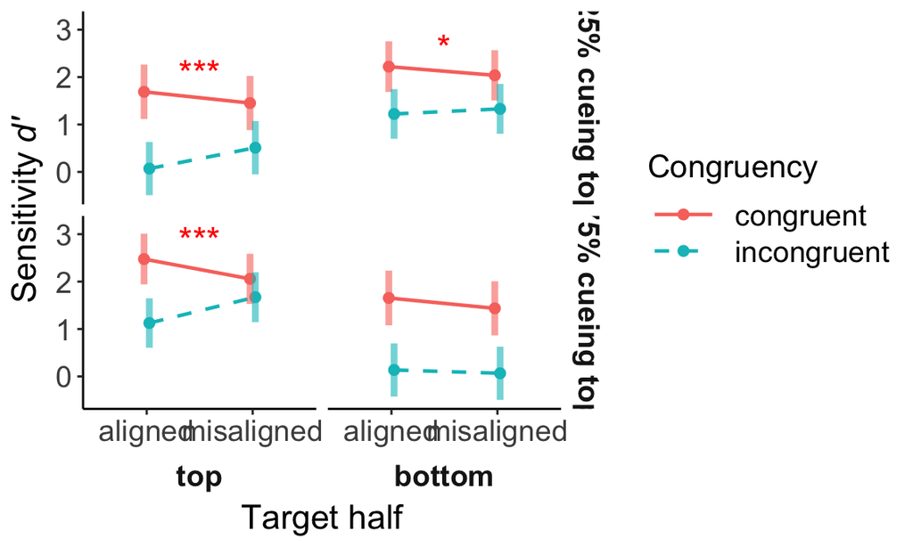

```r
plot_E2_cf_d <- summary(emm_E2_d[1:16], infer = c(TRUE, FALSE)) %>%
  as_tibble() %>%
  ggplot(aes(y = estimate, x = Alignment, color = Congruency, group = Congruency)) +
  geom_point(position = position_dodge(width = 0.1), size = 2) +
  geom_line(aes(linetype = Congruency), position = position_dodge(width = 0.1),
            size = 0.8) +
  scale_linetype_manual(values=c("solid", "dashed"))+
  geom_errorbar(aes(ymin = asymp.LCL, ymax = asymp.UCL), size=1.5, width=0,
                alpha = .6, position = position_dodge(width = 0.1),
                show.legend = F) +
  facet_grid(Probability ~Cue, switch = "x",
             labeller = labeller(Probability = c(`0.25` = "25% cueing top", `0.75` = "75% cueing top"))) +
  coord_cartesian(ylim = ylimit_cf_d) +  # set the limit for y axis c(0, 1100)
  labs(x = "Target half", y = expression("Sensitivity"~italic("d'")), fill = "Congruency") +  # set the names for main, x and y axises
  geom_text(label = c("***", "", "", "", "*", "", "", "", "***", "", "", "", "", "", "", ""), color = "red", size = 6, nudge_y = 0.4, nudge_x = 0.5) + # add starts to the significant columns
  theme_bw() +
  theme(
    text = element_text(size = 10),
    axis.title = element_text(size = 16),
    axis.text = element_text(size = 14), # the size of the texts in plot
    # axis.text.x = element_text(angle = 45, vjust = 0.5),
    legend.title=element_text(size=15),
    legend.text=element_text(size=14),
    legend.position = "right",
    legend.key.width = unit(1.2, "cm"),
    plot.title = element_text(lineheight=.8, face="bold", size = 17),
    panel.border = element_blank(),
    panel.grid.minor = element_blank(),
    panel.grid.major = element_blank(),
    axis.line.x = element_line(colour = 'black', size=0.5, linetype='solid'),
    axis.line.y = element_line(colour = 'black', size=0.5, linetype='solid'),
    # remove the facet background color
    strip.text = element_text(face="bold", size=14, lineheight=5.0),
    strip.background = element_rect(fill="white", colour="white", size=1),
    strip.placement = "outside"
  )

# ggsave(filename = "E2_cf_d.pdf", plot_E2_cf_d, width = 8, height = 4.8)
plot_E2_cf_d
```

#### 3.1.2.3 Composite effects

Composite face effects for top and bottom parts:

```r
emm_E2_d_cf <- contrast(emm_E2_resp, interaction = "pairwise", by = c("Cue", "Probability"))
summary(emm_E2_d_cf[1:4], infer = TRUE)
```

```
##  Alignment_pairwise   Congruency_pairwise     SameDifferent_pairwise Cue    Probability estimate    SE  df asymp.LCL asymp.UCL z.ratio p.value
##  aligned - misaligned congruent - incongruent same - different       top    0.25           0.678 0.170 Inf    0.3457     1.010 4.000   0.0001
##  aligned - misaligned congruent - incongruent same - different       bottom 0.25           0.290 0.118 Inf    0.0584     0.521 2.455   0.0141
##  aligned - misaligned congruent - incongruent same - different       top    0.75           0.963 0.118 Inf    0.7311     1.194 8.147   <.0001
##  aligned - misaligned congruent - incongruent same - different       bottom 0.75           0.149 0.170 Inf   -0.1852     0.482 0.872   0.3830
##
## Confidence level used: 0.95
```

#### 3.1.2.4 Facilitation and interference

```r
# Sensitivity d'
emm_E2_d_fi <- contrast(emm_E2_resp, interaction = "pairwise", by = c("Cue", "Congruency", "Probability"), adjust = "Tukey")
summary(emm_E2_d_fi[1:8], infer=TRUE)
```

```
##  Alignment_pairwise   SameDifferent_pairwise Cue    Congruency  Probability estimate     SE  df asymp.LCL asymp.UCL z.ratio p.value
##  aligned - misaligned same - different       top    congruent   0.25           0.237 0.1211 Inf   -0.1296     0.604  1.961  0.5087
##  aligned - misaligned same - different       top    incongruent 0.25          -0.441 0.1116 Inf   -0.7788    -0.102 -3.948  0.0020
##  aligned - misaligned same - different       bottom congruent   0.25           0.183 0.0824 Inf   -0.0671     0.433  2.217  0.3411
##  aligned - misaligned same - different       bottom incongruent 0.25          -0.107 0.0748 Inf   -0.3339     0.120 -1.431  0.8432
##  aligned - misaligned same - different       top    congruent   0.75           0.417 0.0831 Inf    0.1656     0.669  5.024  <.0001
##  aligned - misaligned same - different       top    incongruent 0.75          -0.545 0.0742 Inf   -0.7704    -0.321 -7.350  <.0001
##  aligned - misaligned same - different       bottom congruent   0.75           0.219 0.1221 Inf   -0.1514     0.588  1.790  0.6268
##  aligned - misaligned same - different       bottom incongruent 0.75           0.070 0.1115 Inf   -0.2678     0.408  0.628  0.9985
##
## Confidence level used: 0.95
## Conf-level adjustment: tukey method for comparing a family of 8 estimates
## P value adjustment: tukey method for comparing a family of 8 estimates
```

```r
# emmip(emm_E2_d_fi[1:8], ~ Probability | Cue + Congruency, CIs = TRUE, adjust = "Tukey")
```

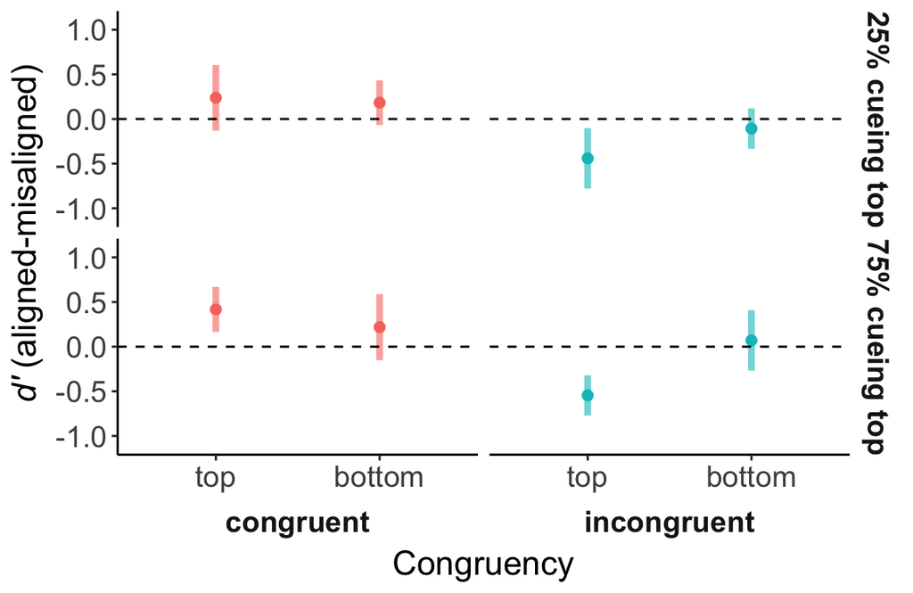

```r
plot_E2_cffi_d <- summary(emm_E2_d_fi[1:8], infer=TRUE) %>%
  as_tibble() %>%
  ggplot(aes(y = estimate, x = Cue, color = Congruency)) +
  geom_point(size = 2) +
  geom_errorbar(aes(ymin = asymp.LCL, ymax = asymp.UCL), size=1.5, width=0,
                alpha = .6) +
  geom_hline(yintercept = 0, linetype = "dashed") +
  facet_grid(Probability ~ Congruency, switch = "x",
             labeller = labeller(Probability = c(`0.25` = "25% cueing top", `0.75` = "75% cueing top"))) +
  coord_cartesian(ylim = ylimit_cf_fi_d) +  # set the limit for y axis c(0, 1100)
  labs(x = "Congruency", y = expression(italic("d'")~"(aligned-misaligned)")) +  # set the names for main, x and y axises
  theme_bw() +
  theme(
    text = element_text(size = 10),
    axis.title = element_text(size = 16),
    axis.text = element_text(size = 14), # the size of the texts in plot
    # axis.text.x = element_text(angle = 45, vjust = 0.5),
    legend.title=element_text(size=15),
    legend.text=element_text(size=14),
    legend.position = "none",
    legend.key.width = unit(1.2, "cm"),
    plot.title = element_text(lineheight=.8, face="bold", size = 17),
    panel.border = element_blank(),
    panel.grid.minor = element_blank(),
    panel.grid.major = element_blank(),
    axis.line.x = element_line(colour = 'black', size=0.5, linetype='solid'),
    axis.line.y = element_line(colour = 'black', size=0.5, linetype='solid'),
    # remove the facet background color
    strip.text = element_text(face="bold", size=14, lineheight=5.0),
    strip.background = element_rect(fill="white", colour="white", size=1),
    strip.placement = "outside"
  ) +
  NULL

# ggsave(filename = "E2_fi_d.pdf", plot_E2_cffi_d, width = 7, height = 4.55)
plot_E2_cffi_d
```

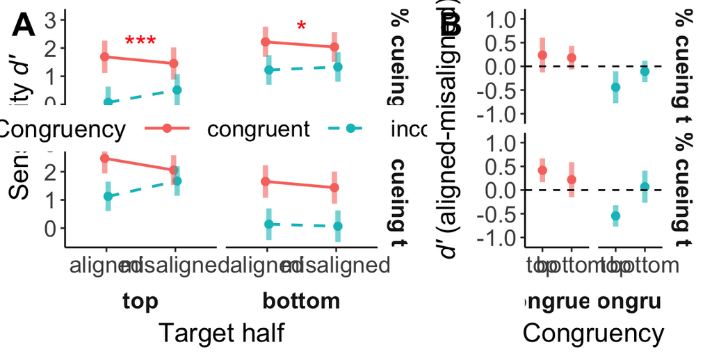

```r
plot_E2_cf_d_ <- plot_E2_cf_d +
  guides(color = guide_legend(nrow = 1, title.position = "left"),
         linetype = guide_legend(nrow = 1, title.position = "left")) +
  theme(legend.position = c(0.6, 0.5),
        legend.box = "horizontal")

plot_E2_d <- ggarrange(plot_E2_cf_d_, plot_E2_cffi_d,
                       labels = c("A", "B"),
                       font.label = (list(size = 20)),
                       widths = c(1.5, 1),
                       nrow = 1)

# ggsave(filename = "E2_d.pdf", plot_E2_d, width = 10, height = 7)
plot_E2_d
```

#### 3.1.2.5 Comparisons between facilitation and interference

```r
summary(contrast(emm_E2_d_fi, method = list("faci-inte"=c(1, 1)), by = c("Cue", "Probability")), infer = TRUE)
```

```
## Cue = top, Probability = 0.25:
##  contrast  estimate    SE  df asymp.LCL asymp.UCL z.ratio p.value
##  faci-inte  -0.2032 0.160 Inf   -0.5161     0.110 -1.272  0.2032
##
## Cue = bottom, Probability = 0.25:
##  contrast  estimate    SE  df asymp.LCL asymp.UCL z.ratio p.value
##  faci-inte   0.0757 0.104 Inf   -0.1284     0.280  0.727  0.4672
##
## Cue = top, Probability = 0.75:
##  contrast  estimate    SE  df asymp.LCL asymp.UCL z.ratio p.value
##  faci-inte  -0.1281 0.104 Inf   -0.3323     0.076 -1.230  0.2186
##
## Cue = bottom, Probability = 0.75:
##  contrast  estimate    SE  df asymp.LCL asymp.UCL z.ratio p.value
##  faci-inte   0.2885 0.160 Inf   -0.0254     0.602  1.801  0.0716
##
## Confidence level used: 0.95
```

```r
# contrast(emmeans(emm_E2_resp, ~ Alignment + SameDifferent | Cue + Probability),
#          interaction = "pairwise")
```

```r
# Sensitivity d'
# test2 <- contrast(regrid(emm_E2_resp), method = "pairwise", simple = "Alignment", adjust = "Tukey")
# summary(test2[1:16], infer=TRUE)
```

## 3.2 Response times

```r
df_lmm_E2_rt <- df_lmm_E2 %>%
  filter(isCorrect == 1)

# save(df_lmm_E2_rt, file = file.path("data", "df_lmm_E2_rt.RData"))
```

### 3.2.1 Fitting the generalized mixed models

```r
# file_E2_rt_max <- file.path(folder_lmm, "E2_rt_lmm_max.RData")
#
# # fit the max model
# if (!file.exists(file_E2_rt_max)) {
#   glmm_E2_rt_max <- glmer(
#     log(RT) ~ Cue * Congruency * Alignment * Probability +
#       (Cue * Congruency * Alignment * Probability | Participant),
#     family = lognormal(),
#     data = df_lmm_rt,
#     control = glmerControl(optimizer = "optimx", # calc.derivs = FALSE,
#                            optCtrl = list(method = "nlminb", starttests = FALSE, kkt = FALSE))
#   )
#
#   save(glmm_E2_rt_max, file = file_E2_rt_max)
# } else {
#   load(file_E2_rt_max)
# }
#
# print(summary(glmm_E2_rt_max), corr = FALSE)
```

#### 3.2.1.1 The zero-correlation-parameter model

```r
file_E2_rt_zcp <- file.path(folder_lmm, "E2_rt_lmm_zcp.RData")

# fit the zcp1 model
if (!file.exists(file_E2_rt_zcp)) {
  glmm_E2_rt_zcp <- lmer(
    log(RT) ~ Cue * Congruency * Alignment * Probability +
      (Cue_C + Con_C + Ali_C +
         Cue_Con + Cue_Ali + Con_Ali +
         Cue_Con_Ali +
         Pro_C +
         Cue_Pro + Con_Pro + Ali_Pro +
         Cue_Con_Pro + Cue_Ali_Pro + Con_Ali_Pro +
         Cue_Con_Ali_Pro || Participant),
    data = df_lmm_E2_rt,
    control = lmerControl(optimizer = "optimx", # calc.derivs = FALSE,
                          optCtrl = list(method = "nlminb", starttests = FALSE, kkt = FALSE))
  )
  # save(glmm_E2_rt_zcp, file = file_E2_rt_zcp)
} else {
  load(file_E2_rt_zcp)
}

print(summary(glmm_E2_rt_zcp), corr = FALSE)
```

```
## Linear mixed model fit by REML. t-tests use Satterthwaite's method ['lmerModLmerTest']
## Formula: log(RT) ~ Cue * Congruency * Alignment * Probability + (Cue_C +      Con_C + Ali_C + Cue_Con + Cue_Ali + Con_Ali + Cue_Con_Ali +      Pro_C + Cue_Pro + Con_Pro + Ali_Pro + Cue_Con_Pro + Cue_Ali_Pro +      Con_Ali_Pro + Cue_Con_Ali_Pro || Participant)
##    Data: df_lmm_E2_rt
## Control: lmerControl(optimizer = "optimx", optCtrl = list(method = "nlminb",      starttests = FALSE, kkt = FALSE))
##
## REML criterion at convergence: 20092.2
##
## Scaled residuals:
##     Min      1Q  Median      3Q     Max
## -4.2443 -0.5901 -0.1322  0.4296 10.6198
##
## Random effects:
##  Groups         Name            Variance  Std.Dev.
##  Participant    (Intercept)     4.570e-02 2.138e-01
##  Participant.1  Cue_C           4.814e-03 6.938e-02
##  Participant.2  Con_C           3.427e-04 1.851e-02
##  Participant.3  Ali_C           5.044e-04 2.246e-02
##  Participant.4  Cue_Con         6.945e-04 2.635e-02
##  Participant.5  Cue_Ali         0.000e+00 0.000e+00
##  Participant.6  Con_Ali         5.039e-04 2.245e-02
##  Participant.7  Cue_Con_Ali     2.215e-04 1.488e-02
##  Participant.8  Pro_C           4.729e-02 2.175e-01
##  Participant.9  Cue_Pro         7.550e-02 2.748e-01
##  Participant.10 Con_Pro         5.963e-10 2.442e-05
##  Participant.11 Ali_Pro         0.000e+00 0.000e+00
##  Participant.12 Cue_Con_Pro     4.505e-09 6.712e-05
##  Participant.13 Cue_Ali_Pro     4.565e-03 6.756e-02
##  Participant.14 Con_Ali_Pro     0.000e+00 0.000e+00
##  Participant.15 Cue_Con_Ali_Pro 2.012e-07 4.485e-04
##  Residual                       1.110e-01 3.331e-01
## Number of obs: 30371, groups:  Participant, 32
##
## Fixed effects:
##                                                                      Estimate Std. Error         df t value Pr(>|t|)
## (Intercept)                                                         6.690e+00  3.888e-02  3.443e+01 172.052  < 2e-16 ***
## Cuebottom                                                          -3.155e-03  1.519e-02  5.423e+01  -0.208 0.836273
## Congruencyincongruent                                               6.257e-02  1.055e-02  2.057e+02   5.928 1.28e-08 ***
## Alignmentmisaligned                                                 4.145e-02  9.755e-03  1.622e+02   4.249 3.61e-05 ***
## Probability2-1                                                     -1.247e-01  4.716e-02  5.844e+01  -2.645 0.010470 *
## Cuebottom:Congruencyincongruent                                     1.630e-02  1.434e-02  1.077e+02   1.136 0.258321
## Cuebottom:Alignmentmisaligned                                       5.224e-03  1.236e-02  1.623e+02   0.423 0.672997
## Congruencyincongruent:Alignmentmisaligned                          -4.881e-02  1.387e-02  1.121e+02  -3.520 0.000625 ***
## Cuebottom:Probability2-1                                            2.721e-01  5.190e-02  3.737e+01   5.244 6.46e-06 ***
## Congruencyincongruent:Probability2-1                               -4.404e-02  1.904e-02  2.999e+04  -2.312 0.020776 *
## Alignmentmisaligned:Probability2-1                                 -3.556e-02  1.832e-02  2.877e+02  -1.941 0.053234 .
## Cuebottom:Congruencyincongruent:Alignmentmisaligned                -1.675e-03  1.906e-02  5.759e+01  -0.088 0.930264
## Cuebottom:Congruencyincongruent:Probability2-1                      7.721e-02  2.697e-02  2.933e+04   2.863 0.004201 **
## Cuebottom:Alignmentmisaligned:Probability2-1                        8.364e-02  2.734e-02  8.972e+01   3.059 0.002927 **
## Congruencyincongruent:Alignmentmisaligned:Probability2-1            4.539e-02  2.643e-02  2.927e+04   1.718 0.085855 .
## Cuebottom:Congruencyincongruent:Alignmentmisaligned:Probability2-1 -5.483e-02  3.773e-02  2.709e+04  -1.453 0.146240
## ---
## Signif. codes:  0 '***' 0.001 '**' 0.01 '*' 0.05 '.' 0.1 ' ' 1
## optimizer (optimx) convergence code: 1
## boundary (singular) fit: see ?isSingular
```

#### 3.2.1.2 The reduced model

```r
summary(rePCA(glmm_E2_rt_zcp))
```

```
## $Participant
## Importance of components:
##                          [,1]   [,2]   [,3]    [,4]    [,5]    [,6]    [,7]    [,8]    [,9]   [,10]    [,11]     [,12]    [,13] [,14] [,15] [,16]
## Standard deviation     0.8248 0.6528 0.6418 0.20828 0.20281 0.07911 0.06742 0.06739 0.05557 0.04468 0.001346 0.0002015 7.33e-05     0     0     0
## Proportion of Variance 0.4191 0.2625 0.2537 0.02673 0.02534 0.00386 0.00280 0.00280 0.00190 0.00123 0.000000 0.0000000 0.00e+00     0     0     0
## Cumulative Proportion  0.4191 0.6816 0.9354 0.96207 0.98741 0.99127 0.99407 0.99687 0.99877 1.00000 1.000000 1.0000000 1.00e+00     1     1     1
```

`Cue_Ali`, `Ali_Pro`, `Con_Ali_Pro`, `Con_Pro`, `Cue_Con_Pro`, and `Cue_Con_Ali_Pro` were removed from extended model (`glmm_E2_rt_zcp`) due to that the variance it explained was smaller than 0.1%, making `glmm_E2_rt_rdc`.

```r
file_E2_rt_rdc <- file.path(folder_lmm, "E2_rt_lmm_rdc.RData")

# fit the rdc1 model
if (!file.exists(file_E2_rt_rdc)) {
  glmm_E2_rt_rdc <- lmer(
    log(RT) ~ Cue * Congruency * Alignment * Probability +
      (Cue_C + Con_C + Ali_C +
         Cue_Con + Con_Ali + # Cue_Ali +
         Cue_Con_Ali +
         Pro_C +
         Cue_Pro +  # Ali_Pro + Con_Pro +
         Cue_Ali_Pro  # Con_Ali_Pro + Cue_Con_Pro +
          || Participant), # Cue_Con_Ali_Pro
    data = df_lmm_E2_rt,
    control = lmerControl(optimizer = "optimx", # calc.derivs = FALSE,
                          optCtrl = list(method = "nlminb", starttests = FALSE, kkt = FALSE))
  )
  # save(glmm_E2_rt_rdc, file = file_E2_rt_rdc)
} else {
  load(file_E2_rt_rdc)
}

print(summary(glmm_E2_rt_rdc), corr = FALSE)
```

```
## Linear mixed model fit by REML. t-tests use Satterthwaite's method ['lmerModLmerTest']
## Formula: log(RT) ~ Cue * Congruency * Alignment * Probability + (Cue_C +      Con_C + Ali_C + Cue_Con + Con_Ali + Cue_Con_Ali + Pro_C +      Cue_Pro + Cue_Ali_Pro || Participant)
##    Data: df_lmm_E2_rt
## Control: lmerControl(optimizer = "optimx", optCtrl = list(method = "nlminb",      starttests = FALSE, kkt = FALSE))
##
## REML criterion at convergence: 20092.2
##
## Scaled residuals:
##     Min      1Q  Median      3Q     Max
## -4.2444 -0.5901 -0.1322  0.4295 10.6198
##
## Random effects:
##  Groups        Name        Variance  Std.Dev.
##  Participant   (Intercept) 0.0457251 0.21383
##  Participant.1 Cue_C       0.0048160 0.06940
##  Participant.2 Con_C       0.0003423 0.01850
##  Participant.3 Ali_C       0.0005045 0.02246
##  Participant.4 Cue_Con     0.0006969 0.02640
##  Participant.5 Con_Ali     0.0005035 0.02244
##  Participant.6 Cue_Con_Ali 0.0002217 0.01489
##  Participant.7 Pro_C       0.0473011 0.21749
##  Participant.8 Cue_Pro     0.0754976 0.27477
##  Participant.9 Cue_Ali_Pro 0.0045724 0.06762
##  Residual                  0.1109745 0.33313
## Number of obs: 30371, groups:  Participant, 32
##
## Fixed effects:
##                                                                      Estimate Std. Error         df t value Pr(>|t|)
## (Intercept)                                                         6.690e+00  3.889e-02  3.441e+01 172.015  < 2e-16 ***
## Cuebottom                                                          -3.155e-03  1.519e-02  5.420e+01  -0.208 0.836278
## Congruencyincongruent                                               6.257e-02  1.056e-02  2.057e+02   5.928 1.28e-08 ***
## Alignmentmisaligned                                                 4.145e-02  9.755e-03  1.622e+02   4.249 3.61e-05 ***
## Probability2-1                                                     -1.247e-01  4.716e-02  5.842e+01  -2.645 0.010478 *
## Cuebottom:Congruencyincongruent                                     1.630e-02  1.434e-02  1.077e+02   1.136 0.258371
## Cuebottom:Alignmentmisaligned                                       5.224e-03  1.236e-02  1.623e+02   0.423 0.673007
## Congruencyincongruent:Alignmentmisaligned                          -4.881e-02  1.387e-02  1.121e+02  -3.520 0.000624 ***
## Cuebottom:Probability2-1                                            2.721e-01  5.190e-02  3.737e+01   5.244 6.46e-06 ***
## Congruencyincongruent:Probability2-1                               -4.404e-02  1.904e-02  3.018e+04  -2.312 0.020775 *
## Alignmentmisaligned:Probability2-1                                 -3.556e-02  1.832e-02  2.874e+02  -1.941 0.053255 .
## Cuebottom:Congruencyincongruent:Alignmentmisaligned                -1.675e-03  1.906e-02  5.760e+01  -0.088 0.930246
## Cuebottom:Congruencyincongruent:Probability2-1                      7.721e-02  2.697e-02  3.008e+04   2.863 0.004201 **
## Cuebottom:Alignmentmisaligned:Probability2-1                        8.364e-02  2.735e-02  8.966e+01   3.059 0.002932 **
## Congruencyincongruent:Alignmentmisaligned:Probability2-1            4.539e-02  2.643e-02  2.998e+04   1.718 0.085863 .
## Cuebottom:Congruencyincongruent:Alignmentmisaligned:Probability2-1 -5.483e-02  3.773e-02  2.956e+04  -1.453 0.146248
## ---
## Signif. codes:  0 '***' 0.001 '**' 0.01 '*' 0.05 '.' 0.1 ' ' 1
```

#### 3.2.1.3 The extended model

```r
file_E2_rt_etd <- file.path(folder_lmm, "E2_rt_lmm_etd.RData")

# fit the etd model
if (!file.exists(file_E2_rt_etd)) {
  glmm_E2_rt_etd <- lmer(
    log(RT) ~ Cue * Congruency * Alignment * Probability +
      (Cue_C + Con_C + Ali_C +
         Cue_Con + Con_Ali + # Cue_Ali +
         Cue_Con_Ali +
         Pro_C +
         Cue_Pro +  # Ali_Pro + Con_Pro +
         Cue_Ali_Pro  # Con_Ali_Pro + Cue_Con_Pro +
          | Participant), # Cue_Con_Ali_Pro
    data = df_lmm_E2_rt,
    control = lmerControl(optimizer = "optimx", # calc.derivs = FALSE,
                          optCtrl = list(method = "nlminb", starttests = FALSE, kkt = FALSE))
  )
  # save(glmm_E2_rt_etd, file = file_E2_rt_etd)
} else {
  load(file_E2_rt_etd)
}

print(summary(glmm_E2_rt_etd), corr = FALSE)
```

```
## Linear mixed model fit by REML. t-tests use Satterthwaite's method ['lmerModLmerTest']
## Formula: log(RT) ~ Cue * Congruency * Alignment * Probability + (Cue_C +      Con_C + Ali_C + Cue_Con + Con_Ali + Cue_Con_Ali + Pro_C +      Cue_Pro + Cue_Ali_Pro | Participant)
##    Data: df_lmm_E2_rt
## Control: lmerControl(optimizer = "optimx", optCtrl = list(method = "nlminb",      starttests = FALSE, kkt = FALSE))
##
## REML criterion at convergence: 20010.4
##
## Scaled residuals:
##     Min      1Q  Median      3Q     Max
## -4.2586 -0.5908 -0.1304  0.4305 10.6496
##
## Random effects:
##  Groups      Name        Variance  Std.Dev. Corr
##  Participant (Intercept) 0.0464276 0.21547
##              Cue_C       0.0049674 0.07048  -0.20
##              Con_C       0.0004322 0.02079   0.33 -0.46
##              Ali_C       0.0007474 0.02734   0.17  0.16  0.06
##              Cue_Con     0.0010951 0.03309   0.01  0.38 -0.32 -0.26
##              Con_Ali     0.0012791 0.03576  -0.09  0.02 -0.48 -0.08  0.44
##              Cue_Con_Ali 0.0039599 0.06293  -0.63  0.07 -0.10 -0.55 -0.12  0.29
##              Pro_C       0.0479580 0.21899   0.09  0.30 -0.72  0.07  0.42  0.21 -0.48
##              Cue_Pro     0.0763459 0.27631   0.53 -0.24  0.20 -0.38  0.02 -0.58 -0.47  0.23
##              Cue_Ali_Pro 0.0089737 0.09473  -0.15  0.30 -0.16  0.36 -0.35  0.29  0.25  0.06 -0.61
##  Residual                0.1107688 0.33282
## Number of obs: 30371, groups:  Participant, 32
##
## Fixed effects:
##                                                                      Estimate Std. Error         df t value Pr(>|t|)
## (Intercept)                                                         6.690e+00  4.013e-02  3.103e+01 166.699  < 2e-16 ***
## Cuebottom                                                          -2.038e-03  1.501e-02  4.127e+01  -0.136  0.89266
## Congruencyincongruent                                               6.184e-02  1.232e-02  5.877e+01   5.021 5.08e-06 ***
## Alignmentmisaligned                                                 4.106e-02  9.936e-03  8.377e+01   4.132 8.48e-05 ***
## Probability2-1                                                     -1.244e-01  4.429e-02  3.361e+01  -2.810  0.00821 **
## Cuebottom:Congruencyincongruent                                     1.510e-02  1.596e-02  6.841e+01   0.946  0.34754
## Cuebottom:Alignmentmisaligned                                       3.857e-03  1.348e-02  1.917e+02   0.286  0.77504
## Congruencyincongruent:Alignmentmisaligned                          -4.682e-02  1.499e-02  1.019e+02  -3.123  0.00233 **
## Cuebottom:Probability2-1                                            2.716e-01  5.702e-02  3.326e+01   4.764 3.63e-05 ***
## Congruencyincongruent:Probability2-1                               -4.329e-02  1.904e-02  2.979e+04  -2.274  0.02300 *
## Alignmentmisaligned:Probability2-1                                 -3.545e-02  1.922e-02  2.027e+02  -1.844  0.06661 .
## Cuebottom:Congruencyincongruent:Alignmentmisaligned                -1.385e-04  2.186e-02  8.332e+01  -0.006  0.99496
## Cuebottom:Congruencyincongruent:Probability2-1                      7.713e-02  2.695e-02  2.985e+04   2.862  0.00422 **
## Cuebottom:Alignmentmisaligned:Probability2-1                        8.401e-02  2.974e-02  7.293e+01   2.825  0.00610 **
## Congruencyincongruent:Alignmentmisaligned:Probability2-1            4.266e-02  2.640e-02  2.988e+04   1.616  0.10612
## Cuebottom:Congruencyincongruent:Alignmentmisaligned:Probability2-1 -5.287e-02  3.767e-02  2.964e+04  -1.404  0.16046
## ---
## Signif. codes:  0 '***' 0.001 '**' 0.01 '*' 0.05 '.' 0.1 ' ' 1
## optimizer (optimx) convergence code: 1
## boundary (singular) fit: see ?isSingular
```

```r
summary(rePCA(glmm_E2_rt_etd))
```

```
## $Participant
## Importance of components:
##                          [,1]   [,2]   [,3]    [,4]    [,5]    [,6]    [,7]    [,8]     [,9]     [,10]
## Standard deviation     0.9715 0.6509 0.5085 0.21791 0.18936 0.14860 0.05757 0.01157 0.001596 1.485e-05
## Proportion of Variance 0.5440 0.2442 0.1490 0.02737 0.02067 0.01273 0.00191 0.00008 0.000000 0.000e+00
## Cumulative Proportion  0.5440 0.7882 0.9373 0.96462 0.98528 0.99801 0.99992 1.00000 1.000000 1.000e+00
```

`Con_C`, `Ali_C`, `Cue_C`, and `Cue_Ali_Pro` were removed from extended model.

```r
file_E2_rt_etd1 <- file.path(folder_lmm, "E2_rt_lmm_etd1.RData")

# fit the etd1 model
if (!file.exists(file_E2_rt_etd1)) {
  glmm_E2_rt_etd1 <- lmer(
    log(RT) ~ Cue * Congruency * Alignment * Probability +
      ( # Cue_C + Con_C + Ali_C +
         Cue_Con + Con_Ali + # Cue_Ali +
         Cue_Con_Ali +
         Pro_C +
         Cue_Pro  # Ali_Pro + Con_Pro +
           # Con_Ali_Pro + Cue_Con_Pro + Cue_Ali_Pro
          | Participant), # Cue_Con_Ali_Pro
    data = df_lmm_E2_rt,
    control = lmerControl(optimizer = "optimx", # calc.derivs = FALSE,
                          optCtrl = list(method = "nlminb", starttests = FALSE, kkt = FALSE))
  )
  # save(glmm_E2_rt_etd1, file = file_E2_rt_etd1)
} else {
  load(file_E2_rt_etd1)
}

print(summary(glmm_E2_rt_etd1), corr = FALSE)
```

```
## Linear mixed model fit by REML. t-tests use Satterthwaite's method ['lmerModLmerTest']
## Formula: log(RT) ~ Cue * Congruency * Alignment * Probability + (Cue_Con +      Con_Ali + Cue_Con_Ali + Pro_C + Cue_Pro | Participant)
##    Data: df_lmm_E2_rt
## Control: lmerControl(optimizer = "optimx", optCtrl = list(method = "nlminb",      starttests = FALSE, kkt = FALSE))
##
## REML criterion at convergence: 20233.3
##
## Scaled residuals:
##     Min      1Q  Median      3Q     Max
## -4.1945 -0.5956 -0.1291  0.4333 10.5434
##
## Random effects:
##  Groups      Name        Variance  Std.Dev. Corr
##  Participant (Intercept) 0.0460165 0.21451
##              Cue_Con     0.0006146 0.02479   0.07
##              Con_Ali     0.0007873 0.02806  -0.14  0.65
##              Cue_Con_Ali 0.0023819 0.04880  -0.81 -0.09  0.08
##              Pro_C       0.0444586 0.21085   0.15  0.51  0.29 -0.64
##              Cue_Pro     0.0761836 0.27601   0.53  0.10 -0.64 -0.54  0.31
##  Residual                0.1120021 0.33467
## Number of obs: 30371, groups:  Participant, 32
##
## Fixed effects:
##                                                                      Estimate Std. Error         df t value Pr(>|t|)
## (Intercept)                                                         6.688e+00  3.923e-02  3.182e+01 170.466  < 2e-16 ***
## Cuebottom                                                          -1.585e-03  9.221e-03  2.488e+02  -0.172 0.863640
## Congruencyincongruent                                               6.336e-02  1.065e-02  1.165e+02   5.949 2.90e-08 ***
## Alignmentmisaligned                                                 4.267e-02  9.245e-03  3.125e+02   4.615 5.74e-06 ***
## Probability2-1                                                     -1.217e-01  3.961e-02  3.589e+01  -3.074 0.004026 **
## Cuebottom:Congruencyincongruent                                     1.544e-02  1.492e-02  1.070e+02   1.035 0.302881
## Cuebottom:Alignmentmisaligned                                       4.047e-03  1.307e-02  3.146e+02   0.310 0.756947
## Congruencyincongruent:Alignmentmisaligned                          -5.010e-02  1.467e-02  1.245e+02  -3.414 0.000865 ***
## Cuebottom:Probability2-1                                            2.693e-01  5.178e-02  3.643e+01   5.202 7.85e-06 ***
## Congruencyincongruent:Probability2-1                               -4.602e-02  1.906e-02  3.022e+04  -2.415 0.015755 *
## Alignmentmisaligned:Probability2-1                                 -3.711e-02  1.738e-02  3.024e+04  -2.135 0.032752 *
## Cuebottom:Congruencyincongruent:Alignmentmisaligned                -1.388e-05  2.078e-02  1.263e+02  -0.001 0.999468
## Cuebottom:Congruencyincongruent:Probability2-1                      8.156e-02  2.700e-02  3.026e+04   3.021 0.002523 **
## Cuebottom:Alignmentmisaligned:Probability2-1                        8.534e-02  2.466e-02  3.024e+04   3.460 0.000540 ***
## Congruencyincongruent:Alignmentmisaligned:Probability2-1            4.671e-02  2.650e-02  3.023e+04   1.763 0.077914 .
## Cuebottom:Congruencyincongruent:Alignmentmisaligned:Probability2-1 -5.904e-02  3.781e-02  3.018e+04  -1.562 0.118375
## ---
## Signif. codes:  0 '***' 0.001 '**' 0.01 '*' 0.05 '.' 0.1 ' ' 1
## optimizer (optimx) convergence code: 0 (OK)
## boundary (singular) fit: see ?isSingular
```

```r
summary(rePCA(glmm_E2_rt_etd1))
```

```
## $Participant
## Importance of components:
##                          [,1]   [,2]   [,3]    [,4]      [,5]      [,6]
## Standard deviation     0.9621 0.5960 0.4831 0.08617 6.331e-06 4.056e-06
## Proportion of Variance 0.6083 0.2334 0.1534 0.00488 0.000e+00 0.000e+00
## Cumulative Proportion  0.6083 0.8417 0.9951 1.00000 1.000e+00 1.000e+00
```

`Cue_Con`, `Con_Ali`, and `Cue_Con_Ali` were removed from extended model.

```r
file_E2_rt_etd2 <- file.path(folder_lmm, "E2_rt_lmm_etd2.RData")

# fit the etd2 model
if (!file.exists(file_E2_rt_etd2)) {
  glmm_E2_rt_etd2 <- lmer(
    log(RT) ~ Cue * Congruency * Alignment * Probability +
      ( # Cue_C + Con_C + Ali_C +
         # Cue_Ali + Con_Ali + Cue_Con +
         # Cue_Con_Ali +
         Pro_C +
         Cue_Pro  # Ali_Pro + Con_Pro +
           # Con_Ali_Pro + Cue_Con_Pro + Cue_Ali_Pro
          | Participant), # Cue_Con_Ali_Pro
    data = df_lmm_E2_rt,
    control = lmerControl(optimizer = "optimx", # calc.derivs = FALSE,
                          optCtrl = list(method = "nlminb", starttests = FALSE, kkt = FALSE))
  )
  # save(glmm_E2_rt_etd2, file = file_E2_rt_etd2)
} else {
  load(file_E2_rt_etd2)
}

print(summary(glmm_E2_rt_etd2), corr = FALSE)
```

```
## Linear mixed model fit by REML. t-tests use Satterthwaite's method ['lmerModLmerTest']
## Formula: log(RT) ~ Cue * Congruency * Alignment * Probability + (Pro_C +      Cue_Pro | Participant)
##    Data: df_lmm_E2_rt
## Control: lmerControl(optimizer = "optimx", optCtrl = list(method = "nlminb",      starttests = FALSE, kkt = FALSE))
##
## REML criterion at convergence: 20255.2
##
## Scaled residuals:
##     Min      1Q  Median      3Q     Max
## -4.1850 -0.5961 -0.1295  0.4324 10.5556
##
## Random effects:
##  Groups      Name        Variance Std.Dev. Corr
##  Participant (Intercept) 0.04609  0.2147
##              Pro_C       0.04458  0.2111   0.15
##              Cue_Pro     0.07626  0.2761   0.53 0.31
##  Residual                0.11212  0.3348
## Number of obs: 30371, groups:  Participant, 32
##
## Fixed effects:
##                                                                      Estimate Std. Error         df t value Pr(>|t|)
## (Intercept)                                                         6.688e+00  3.844e-02  3.234e+01 173.996  < 2e-16 ***
## Cuebottom                                                          -1.724e-03  8.648e-03  3.027e+04  -0.199 0.842035
## Congruencyincongruent                                               6.324e-02  9.525e-03  3.028e+04   6.639 3.20e-11 ***
## Alignmentmisaligned                                                 4.252e-02  8.694e-03  3.026e+04   4.891 1.01e-06 ***
## Probability2-1                                                     -1.222e-01  3.967e-02  3.588e+01  -3.080 0.003958 **
## Cuebottom:Congruencyincongruent                                     1.640e-02  1.347e-02  3.027e+04   1.218 0.223357
## Cuebottom:Alignmentmisaligned                                       4.951e-03  1.234e-02  3.026e+04   0.401 0.688210
## Congruencyincongruent:Alignmentmisaligned                          -5.016e-02  1.325e-02  3.027e+04  -3.785 0.000154 ***
## Cuebottom:Probability2-1                                            2.705e-01  5.180e-02  3.644e+01   5.222 7.38e-06 ***
## Congruencyincongruent:Probability2-1                               -4.541e-02  1.906e-02  3.028e+04  -2.382 0.017220 *
## Alignmentmisaligned:Probability2-1                                 -3.658e-02  1.739e-02  3.026e+04  -2.104 0.035388 *
## Cuebottom:Congruencyincongruent:Alignmentmisaligned                -2.584e-03  1.891e-02  3.026e+04  -0.137 0.891276
## Cuebottom:Congruencyincongruent:Probability2-1                      7.937e-02  2.701e-02  3.028e+04   2.939 0.003300 **
## Cuebottom:Alignmentmisaligned:Probability2-1                        8.363e-02  2.467e-02  3.026e+04   3.389 0.000702 ***
## Congruencyincongruent:Alignmentmisaligned:Probability2-1            4.645e-02  2.651e-02  3.027e+04   1.752 0.079722 .
## Cuebottom:Congruencyincongruent:Alignmentmisaligned:Probability2-1 -5.607e-02  3.782e-02  3.027e+04  -1.483 0.138190
## ---
## Signif. codes:  0 '***' 0.001 '**' 0.01 '*' 0.05 '.' 0.1 ' ' 1
```

#### 3.2.1.4 The optimal model

```r
# compare the extended and reduced model
anova(glmm_E2_rt_etd2, glmm_E2_rt_rdc, refit = FALSE)
```

```
## Data: df_lmm_E2_rt
## Models:
## glmm_E2_rt_etd2: log(RT) ~ Cue * Congruency * Alignment * Probability + (Pro_C +
## glmm_E2_rt_etd2:     Cue_Pro | Participant)
## glmm_E2_rt_rdc: log(RT) ~ Cue * Congruency * Alignment * Probability + (Cue_C +
## glmm_E2_rt_rdc:     Con_C + Ali_C + Cue_Con + Con_Ali + Cue_Con_Ali + Pro_C +
## glmm_E2_rt_rdc:     Cue_Pro + Cue_Ali_Pro || Participant)
##                 npar   AIC   BIC logLik deviance  Chisq Df Pr(>Chisq)
## glmm_E2_rt_etd2   23 20301 20493 -10128    20255
## glmm_E2_rt_rdc    27 20146 20371 -10046    20092 162.98  4  < 2.2e-16 ***
## ---
## Signif. codes:  0 '***' 0.001 '**' 0.01 '*' 0.05 '.' 0.1 ' ' 1
```

```r
glmm_E2_rt_opt <- glmm_E2_rt_rdc

print(summary(glmm_E2_rt_opt), corr = FALSE)
```

```
## Linear mixed model fit by REML. t-tests use Satterthwaite's method ['lmerModLmerTest']
## Formula: log(RT) ~ Cue * Congruency * Alignment * Probability + (Cue_C +      Con_C + Ali_C + Cue_Con + Con_Ali + Cue_Con_Ali + Pro_C +      Cue_Pro + Cue_Ali_Pro || Participant)
##    Data: df_lmm_E2_rt
## Control: lmerControl(optimizer = "optimx", optCtrl = list(method = "nlminb",      starttests = FALSE, kkt = FALSE))
##
## REML criterion at convergence: 20092.2
##
## Scaled residuals:
##     Min      1Q  Median      3Q     Max
## -4.2444 -0.5901 -0.1322  0.4295 10.6198
##
## Random effects:
##  Groups        Name        Variance  Std.Dev.
##  Participant   (Intercept) 0.0457251 0.21383
##  Participant.1 Cue_C       0.0048160 0.06940
##  Participant.2 Con_C       0.0003423 0.01850
##  Participant.3 Ali_C       0.0005045 0.02246
##  Participant.4 Cue_Con     0.0006969 0.02640
##  Participant.5 Con_Ali     0.0005035 0.02244
##  Participant.6 Cue_Con_Ali 0.0002217 0.01489
##  Participant.7 Pro_C       0.0473011 0.21749
##  Participant.8 Cue_Pro     0.0754976 0.27477
##  Participant.9 Cue_Ali_Pro 0.0045724 0.06762
##  Residual                  0.1109745 0.33313
## Number of obs: 30371, groups:  Participant, 32
##
## Fixed effects:
##                                                                      Estimate Std. Error         df t value Pr(>|t|)
## (Intercept)                                                         6.690e+00  3.889e-02  3.441e+01 172.015  < 2e-16 ***
## Cuebottom                                                          -3.155e-03  1.519e-02  5.420e+01  -0.208 0.836278
## Congruencyincongruent                                               6.257e-02  1.056e-02  2.057e+02   5.928 1.28e-08 ***
## Alignmentmisaligned                                                 4.145e-02  9.755e-03  1.622e+02   4.249 3.61e-05 ***
## Probability2-1                                                     -1.247e-01  4.716e-02  5.842e+01  -2.645 0.010478 *
## Cuebottom:Congruencyincongruent                                     1.630e-02  1.434e-02  1.077e+02   1.136 0.258371
## Cuebottom:Alignmentmisaligned                                       5.224e-03  1.236e-02  1.623e+02   0.423 0.673007
## Congruencyincongruent:Alignmentmisaligned                          -4.881e-02  1.387e-02  1.121e+02  -3.520 0.000624 ***
## Cuebottom:Probability2-1                                            2.721e-01  5.190e-02  3.737e+01   5.244 6.46e-06 ***
## Congruencyincongruent:Probability2-1                               -4.404e-02  1.904e-02  3.018e+04  -2.312 0.020775 *
## Alignmentmisaligned:Probability2-1                                 -3.556e-02  1.832e-02  2.874e+02  -1.941 0.053255 .
## Cuebottom:Congruencyincongruent:Alignmentmisaligned                -1.675e-03  1.906e-02  5.760e+01  -0.088 0.930246
## Cuebottom:Congruencyincongruent:Probability2-1                      7.721e-02  2.697e-02  3.008e+04   2.863 0.004201 **
## Cuebottom:Alignmentmisaligned:Probability2-1                        8.364e-02  2.735e-02  8.966e+01   3.059 0.002932 **
## Congruencyincongruent:Alignmentmisaligned:Probability2-1            4.539e-02  2.643e-02  2.998e+04   1.718 0.085863 .
## Cuebottom:Congruencyincongruent:Alignmentmisaligned:Probability2-1 -5.483e-02  3.773e-02  2.956e+04  -1.453 0.146248
## ---
## Signif. codes:  0 '***' 0.001 '**' 0.01 '*' 0.05 '.' 0.1 ' ' 1
```

### 3.2.2 Estimated marginal means

#### 3.2.2.1 Estimated marginal means for RT

```r
file_E2_rt_emm <- file.path(folder_lmm, "E2_rt_emm.RData")
if (!file.exists(file_E2_rt_emm)) {
  emm_E2_rt <- emmeans(glmm_E2_rt_opt, ~ Cue + Congruency + Alignment + Probability)
} else {
  load(file_E2_rt_emm)
}

summary(emm_E2_rt, type = "response") # equivalent to regrid(emm_rt)
```

```
##  Cue    Congruency  Alignment  Probability response   SE  df asymp.LCL asymp.UCL
##  top    congruent   aligned    0.25             856 39.3 Inf       782       936
##  bottom congruent   aligned    0.25             745 33.6 Inf       682       813
##  top    incongruent aligned    0.25             931 43.4 Inf       850      1020
##  bottom incongruent aligned    0.25             793 35.8 Inf       725       866
##  top    congruent   misaligned 0.25             908 41.7 Inf       830       994
##  bottom congruent   misaligned 0.25             762 34.3 Inf       697       832
##  top    incongruent misaligned 0.25             920 42.6 Inf       840      1007
##  bottom incongruent misaligned 0.25             774 34.9 Inf       709       846
##  top    congruent   aligned    0.75             756 34.0 Inf       692       825
##  bottom congruent   aligned    0.75             863 39.6 Inf       789       944
##  top    incongruent aligned    0.75             787 35.5 Inf       720       860
##  bottom incongruent aligned    0.75             949 44.2 Inf       867      1040
##  top    congruent   misaligned 0.75             774 34.9 Inf       708       845
##  bottom congruent   misaligned 0.75             926 42.6 Inf       846      1013
##  top    incongruent misaligned 0.75             785 35.4 Inf       718       857
##  bottom incongruent misaligned 0.75             964 44.9 Inf       880      1056
##
## Degrees-of-freedom method: asymptotic
## Confidence level used: 0.95
## Intervals are back-transformed from the log scale
```

```r
# emmip(regrid(emm_E2_rt), Congruency ~ Alignment | Cue + Probability, CIs = TRUE)
```

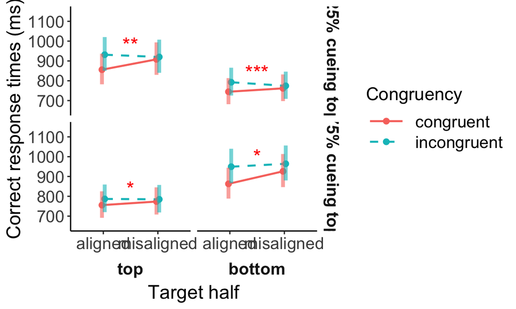

```r
plot_E2_cf_rt <- summary(emm_E2_rt, type = "response") %>%
  as_tibble() %>%
  ggplot(aes(y = response, x = Alignment, color = Congruency, group = Congruency)) +
  geom_point(position = position_dodge(width = 0.1), size = 2) +
  geom_line(aes(linetype = Congruency), position = position_dodge(width = 0.1),
            size = 0.8) +
  scale_linetype_manual(values=c("solid", "dashed"))+
  geom_errorbar(aes(ymin = asymp.LCL, ymax = asymp.UCL), size=1.5, width=0,
                alpha = .6, position = position_dodge(width = 0.1),
                show.legend = F) +
  facet_grid(Probability ~Cue, switch = "x",
             labeller = labeller(Probability = c(`0.25` = "25% cueing top", `0.75` = "75% cueing top"))) +
  coord_cartesian(ylim = ylimit_cf_rt) +  # set the limit for y axis c(0, 1100)
  labs(x = "Target half", y = "Correct response times (ms)", fill = "Congruency") +  # set the names for main, x and y axises
  geom_text(label = c("", "", "**", "***", "", "", "", "", "", "", "*", "*", "", "", "", ""), color = "red", size = 6, nudge_y = 50, nudge_x = 0.5) + # add starts to the significant columns
  theme_bw() +
  theme(
    text = element_text(size = 10),
    axis.title = element_text(size = 16),
    axis.text = element_text(size = 14), # the size of the texts in plot
    # axis.text.x = element_text(angle = 45, vjust = 0.5),
    legend.title=element_text(size=15),
    legend.text=element_text(size=14),
    legend.position = "right",
    legend.key.width = unit(1.2, "cm"),
    plot.title = element_text(lineheight=.8, face="bold", size = 17),
    panel.border = element_blank(),
    panel.grid.minor = element_blank(),
    panel.grid.major = element_blank(),
    axis.line.x = element_line(colour = 'black', size=0.5, linetype='solid'),
    axis.line.y = element_line(colour = 'black', size=0.5, linetype='solid'),
    # remove the facet background color
    strip.text = element_text(face="bold", size=14, lineheight=5.0),
    strip.background = element_rect(fill="white", colour="white", size=1),
    strip.placement = "outside"
  )

# ggsave(filename = "E2_cf_rt.pdf", plot_E2_cf_rt, width = 8, height = 4.8)
plot_E2_cf_rt
```

#### 3.2.2.2 Composite effects

Composite face effects for top and bottom parts:

```r
emm_rt_cf <- contrast(regrid(emm_E2_rt), interaction = "pairwise", by = c("Cue", "Probability"), infer = TRUE)
emm_rt_cf[1:4]
```

```
##  Congruency_pairwise     Alignment_pairwise   Cue    Probability estimate   SE  df asymp.LCL asymp.UCL z.ratio p.value
##  congruent - incongruent aligned - misaligned top    0.25           -63.6 21.8 Inf    -106.4   -20.823 -2.914  0.0036
##  congruent - incongruent aligned - misaligned bottom 0.25           -35.2 10.2 Inf     -55.1   -15.210 -3.453  0.0006
##  congruent - incongruent aligned - misaligned top    0.75           -20.0 10.0 Inf     -39.7    -0.332 -1.993  0.0463
##  congruent - incongruent aligned - misaligned bottom 0.75           -48.4 22.7 Inf     -92.9    -3.834 -2.129  0.0333
##
## Confidence level used: 0.95
```

#### 3.2.2.3 Facilitation and interference

```r
emm_E2_rt_fi <- contrast(regrid(emm_E2_rt), "pairwise", by = c("Cue", "Congruency", "Probability"), infer=TRUE, adjust = "Tukey")
emm_E2_rt_fi[1:8]
```

```
##  contrast             Cue    Congruency  Probability estimate    SE  df asymp.LCL asymp.UCL z.ratio p.value
##  aligned - misaligned top    congruent   0.25          -52.23 14.43 Inf    -95.95     -8.51 -3.620  0.0071
##  aligned - misaligned bottom congruent   0.25          -17.05  7.57 Inf    -39.99      5.89 -2.252  0.3205
##  aligned - misaligned top    incongruent 0.25           11.36 17.29 Inf    -41.03     63.76  0.657  0.9980
##  aligned - misaligned bottom incongruent 0.25           18.12  8.33 Inf     -7.11     43.36  2.177  0.3658
##  aligned - misaligned top    congruent   0.75          -18.10  7.62 Inf    -41.19      4.99 -2.376  0.2532
##  aligned - misaligned bottom congruent   0.75          -63.23 14.78 Inf   -108.03    -18.43 -4.278  0.0005
##  aligned - misaligned top    incongruent 0.75            1.92  8.20 Inf    -22.93     26.77  0.234  1.0000
##  aligned - misaligned bottom incongruent 0.75          -14.84 18.37 Inf    -70.51     40.82 -0.808  0.9927
##
## Confidence level used: 0.95
## Conf-level adjustment: tukey method for comparing a family of 8 estimates
## P value adjustment: tukey method for comparing a family of 8 estimates
```

```r
# emmip(emm_E2_rt_fi[1:8], ~ Probability | Cue + Congruency, CIs = TRUE, adjust = "Tukey") +
#   geom_hline(yintercept = 0, linetype = "dashed")
```

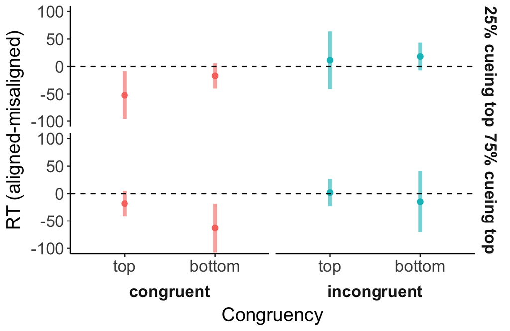

```r
plot_E2_cffi_rt <- emm_E2_rt_fi[1:8] %>%
  as_tibble() %>%
  ggplot(aes(y = estimate, x = Cue, color = Congruency)) +
  geom_point(size = 2) +
  geom_errorbar(aes(ymin = asymp.LCL, ymax = asymp.UCL), size=1.5, width=0,
                alpha = .6) +
  geom_hline(yintercept = 0, linetype = "dashed") +
  facet_grid(Probability ~ Congruency, switch = "x",
             labeller = labeller(Probability = c(`0.25` = "25% cueing top", `0.75` = "75% cueing top"))) +
  coord_cartesian(ylim = ylimit_cf_fi_rt) +  # set the limit for y axis c(0, 1100)
  labs(x = "Congruency", y = expression(RT~"(aligned-misaligned)")) +  # set the names for main, x and y axises
  theme_bw() +
  theme(
    text = element_text(size = 10),
    axis.title = element_text(size = 16),
    axis.text = element_text(size = 14), # the size of the texts in plot
    # axis.text.x = element_text(angle = 45, vjust = 0.5),
    legend.title=element_text(size=15),
    legend.text=element_text(size=14),
    legend.position = "none",
    legend.key.width = unit(1.2, "cm"),
    plot.title = element_text(lineheight=.8, face="bold", size = 17),
    panel.border = element_blank(),
    panel.grid.minor = element_blank(),
    panel.grid.major = element_blank(),
    axis.line.x = element_line(colour = 'black', size=0.5, linetype='solid'),
    axis.line.y = element_line(colour = 'black', size=0.5, linetype='solid'),
    # remove the facet background color
    strip.text = element_text(face="bold", size=14, lineheight=5.0),
    strip.background = element_rect(fill="white", colour="white", size=1),
    strip.placement = "outside"
  ) +
  NULL

# ggsave(filename = "E2_fi_rt.pdf", plot_E2_cffi_rt, width = 7, height = 4.55)
plot_E2_cffi_rt
```

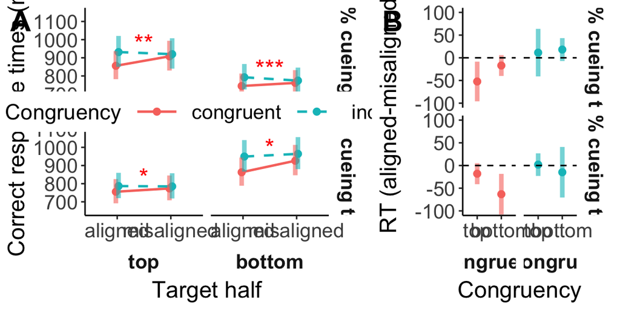

```r
plot_E2_cf_rt_ <- plot_E2_cf_rt +
  guides(color = guide_legend(nrow = 1, title.position = "left"),
         linetype = guide_legend(nrow = 1, title.position = "left")) +
  theme(legend.position = c(0.6, 0.5),
        legend.box = "horizontal")

plot_E2_rt <- ggarrange(plot_E2_cf_rt_, plot_E2_cffi_rt,
                       labels = c("A", "B"),
                       font.label = (list(size = 20)),
                       widths = c(1.5, 1),
                       nrow = 1)

# ggsave(filename = "E2_rt.pdf", plot_E2_rt, width = 10, height = 7)
plot_E2_rt
```

#### 3.2.2.4 Comparisons between facilitation and interference

```r
contrast(emm_E2_rt_fi, method = list("faci-inte"=c(1, 1)), by = c("Cue", "Probability")) %>%
  summary(infer = TRUE)
```

```
## Cue = top, Probability = 0.25:
##  contrast  estimate   SE  df asymp.LCL asymp.UCL z.ratio p.value
##  faci-inte   -40.86 23.2 Inf     -86.3      4.58 -1.762  0.0780
##
## Cue = bottom, Probability = 0.25:
##  contrast  estimate   SE  df asymp.LCL asymp.UCL z.ratio p.value
##  faci-inte     1.08 12.2 Inf     -22.9     25.04  0.088  0.9299
##
## Cue = top, Probability = 0.75:
##  contrast  estimate   SE  df asymp.LCL asymp.UCL z.ratio p.value
##  faci-inte   -16.18 12.2 Inf     -40.2      7.79 -1.323  0.1859
##
## Cue = bottom, Probability = 0.75:
##  contrast  estimate   SE  df asymp.LCL asymp.UCL z.ratio p.value
##  faci-inte   -78.07 24.4 Inf    -125.9    -30.27 -3.201  0.0014
##
## Confidence level used: 0.95
```

```r
emmeans(regrid(emm_E2_rt), ~ Alignment | Cue + Probability) %>%
  contrast(interaction = "pairwise") %>%
  summary(infer = TRUE)
```

```
## Cue = top, Probability = 0.25:
##  Alignment_pairwise   estimate    SE  df asymp.LCL asymp.UCL z.ratio p.value
##  aligned - misaligned  -20.431 11.59 Inf     -43.2      2.29 -1.762  0.0780
##
## Cue = bottom, Probability = 0.25:
##  Alignment_pairwise   estimate    SE  df asymp.LCL asymp.UCL z.ratio p.value
##  aligned - misaligned    0.538  6.11 Inf     -11.4     12.52  0.088  0.9299
##
## Cue = top, Probability = 0.75:
##  Alignment_pairwise   estimate    SE  df asymp.LCL asymp.UCL z.ratio p.value
##  aligned - misaligned   -8.091  6.12 Inf     -20.1      3.90 -1.323  0.1859
##
## Cue = bottom, Probability = 0.75:
##  Alignment_pairwise   estimate    SE  df asymp.LCL asymp.UCL z.ratio p.value
##  aligned - misaligned  -39.037 12.20 Inf     -62.9    -15.13 -3.201  0.0014
##
## Results are averaged over the levels of: Congruency
## Confidence level used: 0.95
```

# 4 Experiment 1 and 2

## 4.1 Responses (d’)

### 4.1.1 Fitting the generalized mixed models

#### 4.1.1.1 The maximal model

```r
# file_resp_max <- file.path(folder_lmm, "Resp_lmm_max.RData")
#
# # fit the max model
# if (!file.exists(file_resp_max)) {
#   glmm_resp_max <- glmer(
#     Resp ~ Cue * Congruency * Alignment * SameDifferent + Probability +
#       (Cue * Congruency * Alignment * SameDifferent | Participant), # Con_Ali_Sam
#     family = binomial(link = "probit"),
#     data = df_lmm,
#     control = glmerControl(optimizer = "optimx", # calc.derivs = FALSE,
#                            optCtrl = list(method = "nlminb", starttests = FALSE, kkt = FALSE))
#   )
#
#   save(glmm_resp_max, file = file_resp_max)
# } else {
#   load(file_resp_max)
# }
#
# print(summary(glmm_resp_max), corr = FALSE)
```

#### 4.1.1.2 The zero-correlation-parameter model

```r
file_resp_zcp <- file.path(folder_lmm, "Resp_lmm_zcp.RData")

# fit the zcp model
if (!file.exists(file_resp_zcp)) {
  glmm_resp_zcp <- glmer(
    Resp ~ Cue * Congruency * Alignment * SameDifferent + Probability +
      (Cue_C + Con_C + Ali_C + Sam_C +
         Cue_Con + Cue_Ali + Cue_Sam + Con_Ali + Con_Sam + Ali_Sam +
         Cue_Con_Ali + Cue_Con_Sam + Cue_Ali_Sam + Con_Ali_Sam +
         Cue_Con_Ali_Sam || Participant),
    family = binomial(link = "probit"),
    data = df_lmm,
    control = glmerControl(optimizer = "optimx", # calc.derivs = FALSE,
                           optCtrl = list(method = "nlminb", starttests = FALSE, kkt = FALSE))
  )

  # save(glmm_resp_zcp, file = file_resp_zcp)
} else {
  load(file_resp_zcp)
}

print(summary(glmm_resp_zcp), corr = FALSE)
```

```
## Generalized linear mixed model fit by maximum likelihood (Laplace Approximation) ['glmerMod']
##  Family: binomial  ( probit )
## Formula: Resp ~ Cue * Congruency * Alignment * SameDifferent + Probability +      (Cue_C + Con_C + Ali_C + Sam_C + Cue_Con + Cue_Ali + Cue_Sam +          Con_Ali + Con_Sam + Ali_Sam + Cue_Con_Ali + Cue_Con_Sam +          Cue_Ali_Sam + Con_Ali_Sam + Cue_Con_Ali_Sam || Participant)
##    Data: df_lmm
## Control: glmerControl(optimizer = "optimx", optCtrl = list(method = "nlminb",      starttests = FALSE, kkt = FALSE))
##
##      AIC      BIC   logLik deviance df.resid
##  63102.7  63409.5 -31517.3  63034.7    61403
##
## Scaled residuals:
##     Min      1Q  Median      3Q     Max
## -7.7530 -0.6145  0.2261  0.5866  4.5197
##
## Random effects:
##  Groups         Name            Variance  Std.Dev.
##  Participant    (Intercept)     6.440e-02 2.538e-01
##  Participant.1  Cue_C           1.251e-01 3.536e-01
##  Participant.2  Con_C           5.088e-03 7.133e-02
##  Participant.3  Ali_C           3.884e-02 1.971e-01
##  Participant.4  Sam_C           2.193e-01 4.683e-01
##  Participant.5  Cue_Con         5.078e-03 7.126e-02
##  Participant.6  Cue_Ali         4.189e-02 2.047e-01
##  Participant.7  Cue_Sam         7.770e-01 8.815e-01
##  Participant.8  Con_Ali         0.000e+00 0.000e+00
##  Participant.9  Con_Sam         3.261e-01 5.710e-01
##  Participant.10 Ali_Sam         1.306e-14 1.143e-07
##  Participant.11 Cue_Con_Ali     0.000e+00 0.000e+00
##  Participant.12 Cue_Con_Sam     1.253e+00 1.120e+00
##  Participant.13 Cue_Ali_Sam     1.401e-03 3.743e-02
##  Participant.14 Con_Ali_Sam     1.067e-01 3.267e-01
##  Participant.15 Cue_Con_Ali_Sam 5.275e-02 2.297e-01
## Number of obs: 61437, groups:  Participant, 64
##
## Fixed effects:
##                                                     Estimate Std. Error z value Pr(>|z|)
## (Intercept)                                         0.133017   0.046191   2.880 0.003981 **
## Cue2-1                                              0.088095   0.046155   1.909 0.056305 .
## Congruency2-1                                      -0.143440   0.015205  -9.434  < 2e-16 ***
## Alignment2-1                                        0.056608   0.027580   2.052 0.040126 *
## SameDifferent2-1                                   -1.366284   0.059928 -22.799  < 2e-16 ***
## Probability0.5                                      0.042453   0.065205   0.651 0.515005
## Probability0.75                                     0.030363   0.016168   1.878 0.060389 .
## Cue2-1:Congruency2-1                               -0.010243   0.025779  -0.397 0.691134
## Cue2-1:Alignment2-1                                -0.103310   0.035394  -2.919 0.003514 **
## Congruency2-1:Alignment2-1                          0.127143   0.023738   5.356 8.50e-08 ***
## Cue2-1:SameDifferent2-1                             0.318684   0.113248   2.814 0.004892 **
## Congruency2-1:SameDifferent2-1                      1.032331   0.075649  13.646  < 2e-16 ***
## Alignment2-1:SameDifferent2-1                       0.010627   0.023866   0.445 0.656103
## Cue2-1:Congruency2-1:Alignment2-1                  -0.002245   0.047390  -0.047 0.962220
## Cue2-1:Congruency2-1:SameDifferent2-1              -0.078199   0.148665  -0.526 0.598884
## Cue2-1:Alignment2-1:SameDifferent2-1                0.167988   0.047931   3.505 0.000457 ***
## Congruency2-1:Alignment2-1:SameDifferent2-1        -0.573895   0.063344  -9.060  < 2e-16 ***
## Cue2-1:Congruency2-1:Alignment2-1:SameDifferent2-1  0.632166   0.099337   6.364 1.97e-10 ***
## ---
## Signif. codes:  0 '***' 0.001 '**' 0.01 '*' 0.05 '.' 0.1 ' ' 1
## optimizer (optimx) convergence code: 0 (OK)
## boundary (singular) fit: see ?isSingular
```

#### 4.1.1.3 The reduced model

```r
summary(rePCA(glmm_resp_zcp))
```

```
## $Participant
## Importance of components:
##                          [,1]   [,2]   [,3]    [,4]    [,5]    [,6]    [,7]    [,8]    [,9]   [,10]   [,11]   [,12]   [,13]     [,14] [,15] [,16]
## Standard deviation     1.1196 0.8815 0.5710 0.46832 0.35363 0.32667 0.25378 0.22966 0.20467 0.19708 0.07133 0.07126 0.03743 1.143e-07     0     0
## Proportion of Variance 0.4154 0.2575 0.1081 0.07269 0.04145 0.03537 0.02135 0.01748 0.01388 0.01287 0.00169 0.00168 0.00046 0.000e+00     0     0
## Cumulative Proportion  0.4154 0.6730 0.7811 0.85376 0.89521 0.93058 0.95193 0.96941 0.98329 0.99617 0.99785 0.99954 1.00000 1.000e+00     1     1
```

`Con_Ali`, `Ali_Sam`, `Cue_Con_Ali`, and `Cue_Ali_Sam` were removed from extended model (`glmm_resp_etd`) due to that the variances they explained were smaller than 0.1%, making `glmm_resp_rdc`.

```r
file_resp_rdc <- file.path(folder_lmm, "Resp_lmm_rdc.RData")

# fit the zcp model
# three random effects were removed
if (!file.exists(file_resp_rdc)) {
  glmm_resp_rdc <- glmer(
    Resp ~ Cue * Congruency * Alignment * SameDifferent + Probability +
      (Cue_C + Con_C + Ali_C + Sam_C +
         Cue_Con + Cue_Ali + Cue_Sam + Con_Sam + # Con_Ali + Ali_Sam +
         Cue_Con_Sam + Con_Ali_Sam +# Cue_Con_Ali + Cue_Ali_Sam +
         Cue_Con_Ali_Sam || Participant),
    family = binomial(link = "probit"),
    data = df_lmm,
    control = glmerControl(optimizer = "optimx", # calc.derivs = FALSE,
                           optCtrl = list(method = "nlminb", starttests = FALSE, kkt = FALSE))
  )

  # save(glmm_resp_rdc, file = file_resp_rdc)
} else {
  load(file_resp_rdc)
}

print(summary(glmm_resp_rdc), corr = FALSE)
```

```
## Generalized linear mixed model fit by maximum likelihood (Laplace Approximation) ['glmerMod']
##  Family: binomial  ( probit )
## Formula: Resp ~ Cue * Congruency * Alignment * SameDifferent + Probability +      (Cue_C + Con_C + Ali_C + Sam_C + Cue_Con + Cue_Ali + Cue_Sam +          Con_Sam + Cue_Con_Sam + Con_Ali_Sam + Cue_Con_Ali_Sam ||          Participant)
##    Data: df_lmm
## Control: glmerControl(optimizer = "optimx", optCtrl = list(method = "nlminb",      starttests = FALSE, kkt = FALSE))
##
##      AIC      BIC   logLik deviance df.resid
##  63094.7  63365.4 -31517.3  63034.7    61407
##
## Scaled residuals:
##     Min      1Q  Median      3Q     Max
## -7.7510 -0.6146  0.2259  0.5868  4.5215
##
## Random effects:
##  Groups         Name            Variance Std.Dev.
##  Participant    (Intercept)     0.064402 0.25378
##  Participant.1  Cue_C           0.125050 0.35362
##  Participant.2  Con_C           0.005088 0.07133
##  Participant.3  Ali_C           0.038835 0.19707
##  Participant.4  Sam_C           0.219322 0.46832
##  Participant.5  Cue_Con         0.005079 0.07127
##  Participant.6  Cue_Ali         0.041875 0.20463
##  Participant.7  Cue_Sam         0.777015 0.88148
##  Participant.8  Con_Sam         0.326078 0.57103
##  Participant.9  Cue_Con_Sam     1.253376 1.11954
##  Participant.10 Con_Ali_Sam     0.106723 0.32669
##  Participant.11 Cue_Con_Ali_Sam 0.052783 0.22975
## Number of obs: 61437, groups:  Participant, 64
##
## Fixed effects:
##                                                     Estimate Std. Error z value Pr(>|z|)
## (Intercept)                                         0.133020   0.046193   2.880 0.003981 **
## Cue2-1                                              0.088085   0.046163   1.908 0.056376 .
## Congruency2-1                                      -0.143434   0.015204  -9.434  < 2e-16 ***
## Alignment2-1                                        0.056618   0.027582   2.053 0.040104 *
## SameDifferent2-1                                   -1.366260   0.059919 -22.802  < 2e-16 ***
## Probability0.5                                      0.042443   0.065206   0.651 0.515106
## Probability0.75                                     0.030360   0.016168   1.878 0.060405 .
## Cue2-1:Congruency2-1                               -0.010254   0.025777  -0.398 0.690775
## Cue2-1:Alignment2-1                                -0.103374   0.035371  -2.923 0.003472 **
## Congruency2-1:Alignment2-1                          0.127151   0.023736   5.357 8.47e-08 ***
## Cue2-1:SameDifferent2-1                             0.318680   0.112984   2.821 0.004794 **
## Congruency2-1:SameDifferent2-1                      1.032317   0.075768  13.625  < 2e-16 ***
## Alignment2-1:SameDifferent2-1                       0.010682   0.023847   0.448 0.654191
## Cue2-1:Congruency2-1:Alignment2-1                  -0.002169   0.047379  -0.046 0.963483
## Cue2-1:Congruency2-1:SameDifferent2-1              -0.078201   0.148731  -0.526 0.599036
## Cue2-1:Alignment2-1:SameDifferent2-1                0.167813   0.047598   3.526 0.000423 ***
## Congruency2-1:Alignment2-1:SameDifferent2-1        -0.573905   0.063347  -9.060  < 2e-16 ***
## Cue2-1:Congruency2-1:Alignment2-1:SameDifferent2-1  0.632150   0.099361   6.362 1.99e-10 ***
## ---
## Signif. codes:  0 '***' 0.001 '**' 0.01 '*' 0.05 '.' 0.1 ' ' 1
```

#### 4.1.1.4 The extended model

```r
file_resp_etd <- file.path(folder_lmm, "Resp_lmm_etd.RData")

# fit the etd model
if (!file.exists(file_resp_etd)) {
  glmm_resp_etd <- glmer(
    Resp ~ Cue * Congruency * Alignment * SameDifferent + Probability +
      (Cue_C + Con_C + Ali_C + Sam_C +
         Cue_Con + Cue_Ali + Cue_Sam + Con_Sam + # Con_Ali + Ali_Sam +
         Cue_Con_Sam + Con_Ali_Sam +# Cue_Con_Ali + Cue_Ali_Sam +
         Cue_Con_Ali_Sam | Participant),
    family = binomial(link = "probit"),
    data = df_lmm,
    control = glmerControl(optimizer = "optimx", # calc.derivs = FALSE,
                           optCtrl = list(method = "nlminb", starttests = FALSE, kkt = FALSE))
  )

  # save(glmm_resp_etd, file = glmm_resp_etd)
} else {
  load(file_resp_etd)
}

print(summary(glmm_resp_etd), corr = FALSE)
```

```
## Generalized linear mixed model fit by maximum likelihood (Laplace Approximation) ['glmerMod']
##  Family: binomial  ( probit )
## Formula: Resp ~ Cue * Congruency * Alignment * SameDifferent + Probability +      (Cue_C + Con_C + Ali_C + Sam_C + Cue_Con + Cue_Ali + Cue_Sam +          Con_Sam + Cue_Con_Sam + Con_Ali_Sam + Cue_Con_Ali_Sam |          Participant)
##    Data: df_lmm
## Control: glmerControl(optimizer = "optimx", optCtrl = list(method = "nlminb",      starttests = FALSE, kkt = FALSE))
##
##      AIC      BIC   logLik deviance df.resid
##  63083.0  63949.5 -31445.5  62891.0    61341
##
## Scaled residuals:
##     Min      1Q  Median      3Q     Max
## -7.7764 -0.6110  0.2195  0.5860  5.2220
##
## Random effects:
##  Groups      Name            Variance Std.Dev. Corr
##  Participant (Intercept)     0.06868  0.26206
##              Cue_C           0.12513  0.35374  -0.12
##              Con_C           0.00580  0.07616  -0.44 -0.09
##              Ali_C           0.03871  0.19674   0.14 -0.02 -0.24
##              Sam_C           0.22202  0.47119  -0.07 -0.16  0.59 -0.17
##              Cue_Con         0.01401  0.11837   0.02  0.15  0.45 -0.36  0.38
##              Cue_Ali         0.04120  0.20297  -0.40 -0.04  0.22 -0.16  0.23  0.06
##              Cue_Sam         0.76967  0.87731   0.29  0.03 -0.32  0.17  0.01 -0.49 -0.29
##              Con_Sam         0.33708  0.58059  -0.02 -0.22 -0.50  0.01 -0.18  0.02  0.07  0.03
##              Cue_Con_Sam     1.24261  1.11473   0.04 -0.07 -0.21  0.09 -0.01 -0.61 -0.32  0.77  0.22
##              Con_Ali_Sam     0.10948  0.33088   0.08  0.17  0.24 -0.07  0.27 -0.36  0.06  0.40 -0.46  0.44
##              Cue_Con_Ali_Sam 0.19553  0.44219   0.15 -0.02 -0.38  0.02 -0.35  0.02  0.05  0.10 -0.07 -0.45 -0.39
## Number of obs: 61437, groups:  Participant, 64
##
## Fixed effects:
##                                                     Estimate Std. Error z value Pr(>|z|)
## (Intercept)                                         0.190215   0.049826   3.818 0.000135 ***
## Cue2-1                                              0.086308   0.046234   1.867 0.061935 .
## Congruency2-1                                      -0.146568   0.015757  -9.302  < 2e-16 ***
## Alignment2-1                                        0.057107   0.027607   2.069 0.038586 *
## SameDifferent2-1                                   -1.367728   0.060308 -22.679  < 2e-16 ***
## Probability0.5                                     -0.068135   0.073251  -0.930 0.352287
## Probability0.75                                     0.030948   0.016186   1.912 0.055867 .
## Cue2-1:Congruency2-1                               -0.008224   0.029046  -0.283 0.777083
## Cue2-1:Alignment2-1                                -0.102079   0.035450  -2.880 0.003983 **
## Congruency2-1:Alignment2-1                          0.130176   0.024030   5.417 6.06e-08 ***
## Cue2-1:SameDifferent2-1                             0.313897   0.112803   2.783 0.005391 **
## Congruency2-1:SameDifferent2-1                      1.030473   0.076980  13.386  < 2e-16 ***
## Alignment2-1:SameDifferent2-1                       0.013823   0.024049   0.575 0.565436
## Cue2-1:Congruency2-1:Alignment2-1                  -0.008231   0.048046  -0.171 0.863980
## Cue2-1:Congruency2-1:SameDifferent2-1              -0.049411   0.148288  -0.333 0.738973
## Cue2-1:Alignment2-1:SameDifferent2-1                0.171521   0.048081   3.567 0.000361 ***
## Congruency2-1:Alignment2-1:SameDifferent2-1        -0.592064   0.064222  -9.219  < 2e-16 ***
## Cue2-1:Congruency2-1:Alignment2-1:SameDifferent2-1  0.664157   0.112066   5.926 3.10e-09 ***
## ---
## Signif. codes:  0 '***' 0.001 '**' 0.01 '*' 0.05 '.' 0.1 ' ' 1
## optimizer (optimx) convergence code: 1
## boundary (singular) fit: see ?isSingular
```

```r
summary(rePCA(glmm_resp_etd))
```

```
## $Participant
## Importance of components:
##                          [,1]   [,2]   [,3]    [,4]    [,5]    [,6]    [,7]    [,8]    [,9]   [,10]   [,11]     [,12]
## Standard deviation     1.3617 0.6534 0.6171 0.45717 0.33683 0.27047 0.22740 0.19526 0.11588 0.09401 0.01508 2.882e-05
## Proportion of Variance 0.5849 0.1347 0.1201 0.06593 0.03579 0.02308 0.01631 0.01203 0.00424 0.00279 0.00007 0.000e+00
## Cumulative Proportion  0.5849 0.7196 0.8398 0.90570 0.94149 0.96456 0.98088 0.99290 0.99714 0.99993 1.00000 1.000e+00
```

`Con_C`, `Cue_Con`, `Ali_C`, and `Cue_Ali` was removed from extended model.

```r
file_resp_etd1 <- file.path(folder_lmm, "Resp_lmm_etd1.RData")

# fit the etd1 model
if (!file.exists(file_resp_etd1)) {
  glmm_resp_etd1 <- glmer(
    Resp ~ Cue * Congruency * Alignment * SameDifferent + Probability +
      (Cue_C + Sam_C + # Con_C + Ali_C +
         Cue_Sam + Con_Sam + # Cue_Con + Con_Ali + Ali_Sam + Cue_Ali +
         Cue_Con_Sam + Con_Ali_Sam +# Cue_Con_Ali + Cue_Ali_Sam +
         Cue_Con_Ali_Sam | Participant),
    family = binomial(link = "probit"),
    data = df_lmm,
    control = glmerControl(optimizer = "optimx", # calc.derivs = FALSE,
                           optCtrl = list(method = "nlminb", starttests = FALSE, kkt = FALSE))
  )
  # save(glmm_resp_etd1, file = glmm_resp_etd1)
} else {
  load(file_resp_etd1)
}

print(summary(glmm_resp_etd1), corr = FALSE)
```

```
## Generalized linear mixed model fit by maximum likelihood (Laplace Approximation) ['glmerMod']
##  Family: binomial  ( probit )
## Formula: Resp ~ Cue * Congruency * Alignment * SameDifferent + Probability +      (Cue_C + Sam_C + Cue_Sam + Con_Sam + Cue_Con_Sam + Con_Ali_Sam +          Cue_Con_Ali_Sam | Participant)
##    Data: df_lmm
## Control: glmerControl(optimizer = "optimx", optCtrl = list(method = "nlminb",      starttests = FALSE, kkt = FALSE))
##
##      AIC      BIC   logLik deviance df.resid
##  63245.1  63732.5 -31568.6  63137.1    61383
##
## Scaled residuals:
##     Min      1Q  Median      3Q     Max
## -6.8485 -0.6094  0.2430  0.5779  4.6281
##
## Random effects:
##  Groups      Name            Variance Std.Dev. Corr
##  Participant (Intercept)     0.06446  0.2539
##              Cue_C           0.12309  0.3508   -0.11
##              Sam_C           0.21481  0.4635   -0.08 -0.16
##              Cue_Sam         0.76338  0.8737    0.28  0.02  0.01
##              Con_Sam         0.32412  0.5693   -0.04 -0.22 -0.16  0.03
##              Cue_Con_Sam     1.21246  1.1011    0.06 -0.08  0.00  0.77  0.23
##              Con_Ali_Sam     0.11567  0.3401    0.11  0.16  0.28  0.41 -0.44  0.45
##              Cue_Con_Ali_Sam 0.18204  0.4267    0.13  0.03 -0.39  0.11 -0.05 -0.47 -0.43
## Number of obs: 61437, groups:  Participant, 64
##
## Fixed effects:
##                                                     Estimate Std. Error z value Pr(>|z|)
## (Intercept)                                         0.157667   0.048780   3.232 0.001228 **
## Cue2-1                                              0.086991   0.045839   1.898 0.057728 .
## Congruency2-1                                      -0.138649   0.011955 -11.597  < 2e-16 ***
## Alignment2-1                                        0.040306   0.011744   3.432 0.000599 ***
## SameDifferent2-1                                   -1.353450   0.059365 -22.799  < 2e-16 ***
## Probability0.5                                     -0.011632   0.072389  -0.161 0.872343
## Probability0.75                                     0.030488   0.016134   1.890 0.058796 .
## Cue2-1:Congruency2-1                               -0.007521   0.023914  -0.315 0.753140
## Cue2-1:Alignment2-1                                -0.087931   0.023489  -3.744 0.000181 ***
## Congruency2-1:Alignment2-1                          0.130470   0.023736   5.497 3.87e-08 ***
## Cue2-1:SameDifferent2-1                             0.309046   0.112533   2.746 0.006028 **
## Congruency2-1:SameDifferent2-1                      1.014579   0.075450  13.447  < 2e-16 ***
## Alignment2-1:SameDifferent2-1                       0.022333   0.023544   0.949 0.342848
## Cue2-1:Congruency2-1:Alignment2-1                  -0.015297   0.047475  -0.322 0.747286
## Cue2-1:Congruency2-1:SameDifferent2-1              -0.058703   0.146943  -0.399 0.689527
## Cue2-1:Alignment2-1:SameDifferent2-1                0.143644   0.047082   3.051 0.002281 **
## Congruency2-1:Alignment2-1:SameDifferent2-1        -0.592199   0.064522  -9.178  < 2e-16 ***
## Cue2-1:Congruency2-1:Alignment2-1:SameDifferent2-1  0.678179   0.110018   6.164 7.08e-10 ***
## ---
## Signif. codes:  0 '***' 0.001 '**' 0.01 '*' 0.05 '.' 0.1 ' ' 1
## optimizer (optimx) convergence code: 0 (OK)
## boundary (singular) fit: see ?isSingular
```